# 001538_catalyst_neuro_zhai_2025_how_to_use_this_dataset_ipynb

## Installing requirements

The cell below installs every Python package needed to run this notebook, at fully pinned versions, using [`uv`](https://github.com/astral-sh/uv) for fast resolution. In Colab the cell is collapsed by default — click the ▶ button to run it.

```python
# install cell skipped during CI (deps preinstalled into system Python)
```

> **⚠️ Restart runtime after install**

> The install may upgrade packages already loaded in the kernel. Go to **Runtime → Restart session**, then **Run all cells below** (skip this install cell on re-run).

# State-dependent modulation of spiny projection neurons controlslevodopa-induced dyskinesia in a mouse model of Parkinson’s disease

**This Dataset (DANDI:001538):** This dataset contains neurophysiology data from the Surmeier lab studying levodopa-induced dyskinesia (LID) in Parkinson's disease models. The data spans multiple experimental approaches:

- **Electrophysiology**: Patch-clamp recordings from striatal neurons (dSPNs and iSPNs)
- **Two-photon imaging**: Dendritic excitability and spine density measurements
- **Behavioral analysis**: Abnormal involuntary movements (AIMs) and rotational behavior
- **Pharmacology**: Effects of various receptor agonists and antagonists
- **Optogenetics**: Selective stimulation of specific neuron populations

One of the nice features of DANDI is that data can be streamed directly from anywhere in the world without downloading (although local download is also supported). To enable streaming we instantiate a DANDI client pointed at the published version of the dandiset.

```python
from dandi.dandiapi import DandiAPIClient

dandiset_id = "001538"
client = DandiAPIClient()
dandiset = client.get_dandiset(dandiset_id, "0.260527.1302")
assets = dandiset.get_assets()
assets_list = list(assets)
```

## Fetching data

Dandisets contain **Assets** which are individual data files within the dataset. For this project, each asset represents one NWB file containing:

- **One experimental session** from **one subject** (animal)
- All data streams recorded during that session (voltage, imaging, behavior)
- Complete experimental metadata and protocols
- Standardized data organization following NWB format

The path of an NWB file on DANDI follows this structure:

`sub-<subject_id>/sub-<subject_id>_ses-<session_id>_<modality>.nwb`

The session_id encodes experimental metadata as five tokens separated by `++`:

`<cell_type>++<state>++<pharmacology>++<genotype>++<date>`

For example, `"dSPN++OffState++none++WT++20160523"` indicates:

- dSPN cell type (direct pathway spiny projection neuron)
- Off-state (no levodopa treatment)
- No pharmacological treatment
- Wild-type genotype
- Recorded on May 23, 2016

The **modality** suffix in the filename encodes the experiment type:

- `icephys` — current clamp (somatic excitability)
- `icephys+ophys` — current clamp + two-photon imaging (dendritic excitability)
- `icephys+ogen` — current clamp + optogenetics (oEPSC experiments)
- `ophys` — two-photon imaging only (acetylcholine biosensor)

To fetch data for a specific experiment type or condition, we define utility functions to parse these path components.

```python
from typing import Literal

def get_session_id(asset_path: str) -> str:
    """Extract session ID from DANDI asset path."""
    fname = asset_path.split('/')[-1]
    if '_ses-' not in fname:
        return ''
    return fname.split('_ses-', 1)[1].rsplit('_', 1)[0]

def get_modality(asset_path: str) -> str:
    """Extract modality suffix from DANDI asset path (icephys, icephys+ogen, ophys, etc.)."""
    fname = asset_path.split('/')[-1]
    if not fname.endswith('.nwb'):
        return ''
    return fname[:-len('.nwb')].rsplit('_', 1)[-1]

def parse_session_id(session_id: str) -> dict:
    """Parse a session_id string into its five component fields."""
    t = session_id.split('++')
    if len(t) < 5:
        return {}
    return {
        'cell_type': t[0],
        'state':     t[1],
        'pharm':     t[2],
        'genotype':  t[3],
        'date':      t[4],
    }

def get_cell_type(session_id: str) -> str:
    """Extract cell type (dSPN, iSPN, pan)."""
    if not session_id:
        return ""
    return session_id.split("++")[0]

def is_cell_type(session_id: str, cell_type: Literal["dSPN", "iSPN", "pan"]) -> bool:
    """Filter data by cell type."""
    return get_cell_type(session_id) == cell_type

def get_state(session_id: str) -> str:
    """Extract experimental state (CTRL, PD, OffState, OnState, OFF, ON)."""
    if not session_id:
        return ""
    return session_id.split("++")[1]

def is_state(session_id: str, state: Literal["CTRL", "LesionedControl", "OFF", "ON", "OffState", "OnState", "PD"]) -> bool:
    """Filter data by disease/treatment state."""
    return get_state(session_id) == state

def get_pharmacology(session_id: str) -> str:
    """Extract pharmacological treatment (none, D1RaSch, D2RaSul, M1RaOxoM, etc.)."""
    if not session_id:
        return ""
    return session_id.split("++")[2]

def is_pharmacology(session_id: str, pharmacology: Literal["none", "DMSO", "CNO", "D1RaSch", "D2RaSul", "M1RaOxoM", "M1RaThp", "M1RaTri"]) -> bool:
    """Filter data by pharmacological condition."""
    return get_pharmacology(session_id) == pharmacology

def get_genotype(session_id: str) -> str:
    """Extract animal genotype (WT, CDGIKO, M1RCRISPR, iSPNM1RKO)."""
    if not session_id:
        return ""
    return session_id.split("++")[3]

def is_genotype(session_id: str, genotype: Literal["CDGIKO", "M1RCRISPR", "WT", "iSPN", "iSPNM1RKO"]) -> bool:
    """Filter data by genotype."""
    return get_genotype(session_id) == genotype

def get_date(session_id: str) -> str:
    """Extract recording date (YYYYMMDD format)."""
    if not session_id:
        return ""
    return session_id.split("++")[4]

# Example: Parse metadata from a sample NWB file
nwb_assets = [a for a in assets_list if a.path.endswith('.nwb')]
sample_asset = nwb_assets[2]
session_id = get_session_id(sample_asset.path)
fields = parse_session_id(session_id)

print("Parsed metadata from sample asset:")
print(f"  Path:      {sample_asset.path}")
print(f"  Session:   {session_id}")
print(f"  Modality:  {get_modality(sample_asset.path)}")
print(f"  Cell type: {fields.get('cell_type')}")
print(f"  State:     {fields.get('state')}")
print(f"  Pharm:     {fields.get('pharm')}")
print(f"  Genotype:  {fields.get('genotype')}")
print(f"  Date:      {fields.get('date')}")
```

```
Parsed metadata from sample asset:
  Path:      sub-CDGI-mouse-1945/sub-CDGI-mouse-1945_ses-pan++ON++none++CDGIKO++20180223_image.nwb
  Session:   pan++ON++none++CDGIKO++20180223
  Modality:  image
  Cell type: pan
  State:     ON
  Pharm:     none
  Genotype:  CDGIKO
  Date:      20180223
```

## Current Clamp Data Access and Organization

### NWB Data Structure for Current Clamp Experiments

Current clamp data in NWB files is organized across several modules:

- **`acquisition`**: Raw voltage and current time series from individual recording sweeps
- **`intracellular_recordings`**: High-level table linking stimuli to responses
- **`stimuli`**: Current injection protocols
- **`responses`**: Voltage recordings organized by experimental condition

Let's explore how to access and work with this hierarchical data organization using the filters we defined above to extract data from the somatic excitability experiments of figure 1.

```python
# Filter for dSPN somatic excitability experiments (Figure 1E equivalent).
# In the published dandiset the experiment type is encoded in the modality suffix,
# not in the session_id.  Current-clamp somatic recordings use 'icephys' or
# 'icephys+ophys' modality combined with cell_type == 'dSPN'.

def is_dspn_icephys(asset_path: str) -> bool:
    """dSPN current-clamp files (somatic excitability)."""
    modality = get_modality(asset_path)
    cell_type = get_cell_type(get_session_id(asset_path))
    return modality in ('icephys', 'icephys+ophys') and cell_type == 'dSPN'

available_assets = [asset for asset in assets_list if is_dspn_icephys(asset.path)]

print(f"Found {len(available_assets)} dSPN current-clamp (somatic excitability) files:")
for i, asset in enumerate(available_assets[:3]):
    session_id = get_session_id(asset.path)
    fields = parse_session_id(session_id)
    print(f"  {i+1}. {asset.path}")
    print(f"     Session:   {session_id}")
    print(f"     Modality:  {get_modality(asset.path)}")
    print(f"     Cell type: {fields.get('cell_type')}")
    print(f"     State:     {fields.get('state')}")
    print(f"     Genotype:  {fields.get('genotype')}")
    print()
```

```
Found 18 dSPN current-clamp (somatic excitability) files:
  1. sub-Subject20160812LIDOFFtDTomato/sub-Subject20160812LIDOFFtDTomato_ses-dSPN++OffState++none++WT++20160812_icephys+ophys.nwb
     Session:   dSPN++OffState++none++WT++20160812
     Modality:  icephys+ophys
     Cell type: dSPN
     State:     OffState
     Genotype:  WT

  2. sub-Subject20161111LIDOFFtDTomato/sub-Subject20161111LIDOFFtDTomato_ses-dSPN++OffState++none++WT++20161111_icephys+ophys.nwb
     Session:   dSPN++OffState++none++WT++20161111
     Modality:  icephys+ophys
     Cell type: dSPN
     State:     OffState
     Genotype:  WT

  3. sub-Subject20161114LIDOFFtDTomato/sub-Subject20161114LIDOFFtDTomato_ses-dSPN++OffState++none++WT++20161114_icephys+ophys.nwb
     Session:   dSPN++OffState++none++WT++20161114
     Modality:  icephys+ophys
     Cell type: dSPN
     State:     OffState
     Genotype:  WT
```

### Streaming NWB Files from DANDI

Here we demonstrate **streaming access** to NWB files directly from DANDI's cloud storage. This approach enables:

- **No local downloads**: Access data directly over the internet without storing files locally
- **Selective data access**: Read only the parts of the file you need (lazy loading)
- **Memory efficiency**: Work with large datasets without loading everything into memory
- **Global accessibility**: Access data from anywhere with an internet connection

This is particularly valuable for large neurophysiology datasets that may be too big to download entirely.

```python
import h5py
import remfile
from pynwb import NWBHDF5IO

asset = available_assets[0]
s3_url = asset.get_content_url(follow_redirects=1, strip_query=False)
file_system = remfile.File(s3_url, disk_cache=remfile.DiskCache("nwb-cache"))
file = h5py.File(file_system, mode="r")

io = NWBHDF5IO(file=file)
nwbfile = io.read()

nwbfile
```

root (NWBFile)

session_description: Per-mouse-day icephys merge for Subject20160812LIDOFFtDTomato: 1 patched cell(s), category=LID OFF, animal/reporter=tD-Tomato. All cells from this mouse on this day collected in one NWB file with the icephys hierarchical chain populated (IntracellularRecordings -> Simultaneous -> Sequential -> Repetitions -> ExperimentalConditions).

identifier: 6617ecb6-4c3f-45eb-a797-2aab013f3d35

**session_start_time**

2016-08-12 17:23:03-05:00

**timestamps_reference_time**

2016-08-12 17:23:03-05:00

**file_create_date**

**0**

2026-05-24 16:22:57.357464-06:00

**experimenter**

('Zhai, Shenyu', 'Cui, Qiaoling', 'Wokosin, David', 'Sun, Linqing', 'Tkatch, Tatiana', 'Crittenden, Jill R.', 'Graybiel, Ann M.', 'Surmeier, D. James')

**icephys_electrodes**

**Cell3_Distal1 (IntracellularElectrode)**

description: Patch-clamp electrode at distal dendrite location 1 of Cell 3 (~90 um from soma).

location: Caudoputamen

**device (Device)**

description: Molecular Devices MultiClamp 700B patch-clamp amplifier.

cell_id: Cell3

**Cell3_Proximal1 (IntracellularElectrode)**

description: Patch-clamp electrode at proximal dendrite location 1 of Cell 3 (~40 um from soma).

location: Caudoputamen

**device (Device)**

description: Molecular Devices MultiClamp 700B patch-clamp amplifier.

cell_id: Cell3

**Cell3_Soma (IntracellularElectrode)**

description: Patch-clamp electrode at the soma of Cell 3, recorded as part of the mouse-day icephys merge.

location: Caudoputamen

**device (Device)**

description: Molecular Devices MultiClamp 700B patch-clamp amplifier.

cell_id: Cell3

**related_publications**

('https://doi.org/10.1101/2025.01.02.631090',)

**acquisition**

**CurrentClampSeries_Cell3_Dendritic (CurrentClampSeries)**

starting_time: 541.0

rate: 10000.0

resolution: -1.0

comments: no comments

description: Concatenated current-clamp recordings for Cell 3 dend_excitability. 6 sweeps merged end-to-end (Pattern B). Per-sweep wall-clock offsets stored in IntracellularRecordingsTable.sweep_start_time.

conversion: 1.0

offset: 0.0

unit: volts

**data**

HDF5 dataset

| Data type | float32 |
| --- | --- |
| Shape | (240000,) |
| Array size | 937.50 KiB |
| Chunk shape | (240000,) |
| Compression | gzip |
| Compression opts | 4 |
| Uncompressed size (bytes) | 960000 |
| Compressed size (bytes) | 285418 |
| Compression ratio | 3.3634879369906594 |

starting_time_unit: seconds

**electrode (IntracellularElectrode)**

description: Patch-clamp electrode at proximal dendrite location 1 of Cell 3 (~40 um from soma).

location: Caudoputamen

**device (Device)**

description: Molecular Devices MultiClamp 700B patch-clamp amplifier.

cell_id: Cell3

gain: 1.0

stimulus_description: N/A

**CurrentClampSeries_Cell3_Somatic (CurrentClampSeries)**

starting_time: 0.0

rate: 10000.0

resolution: -1.0

comments: no comments

description: Concatenated current-clamp recordings for Cell 3 soma_excitability. 26 sweeps merged end-to-end (Pattern B). Per-sweep wall-clock offsets stored in IntracellularRecordingsTable.sweep_start_time.

conversion: 1.0

offset: 0.0

unit: volts

**data**

HDF5 dataset

| Data type | float32 |
| --- | --- |
| Shape | (260000,) |
| Array size | 1015.62 KiB |
| Chunk shape | (260000,) |
| Compression | gzip |
| Compression opts | 4 |
| Uncompressed size (bytes) | 1040000 |
| Compressed size (bytes) | 329622 |
| Compression ratio | 3.1551292086086486 |

starting_time_unit: seconds

**electrode (IntracellularElectrode)**

description: Patch-clamp electrode at the soma of Cell 3, recorded as part of the mouse-day icephys merge.

location: Caudoputamen

**device (Device)**

description: Molecular Devices MultiClamp 700B patch-clamp amplifier.

cell_id: Cell3

gain: 1.0

stimulus_description: N/A

**ImageLineScanSource (Images)**

description: Source images for line scan experiments: field of view snapshots with scan-line overlay, used to identify the recorded region. One image per trio sweep per channel (cell, channel, dendrite location, trial).

**ImageAlexa568Cell3Distal1Trial001 (Image)**

description: Source image (field of view with scan line overlay) for Cell 3 Distal location 1, channel Ch1, trio sweep 1 (IRT row 29, sweep_start_time=685.0s).

**ImageAlexa568Cell3Distal1Trial002 (Image)**

description: Source image (field of view with scan line overlay) for Cell 3 Distal location 1, channel Ch1, trio sweep 2 (IRT row 30, sweep_start_time=696.0s).

**ImageAlexa568Cell3Distal1Trial003 (Image)**

description: Source image (field of view with scan line overlay) for Cell 3 Distal location 1, channel Ch1, trio sweep 3 (IRT row 31, sweep_start_time=713.0s).

**ImageAlexa568Cell3Proximal1Trial001 (Image)**

description: Source image (field of view with scan line overlay) for Cell 3 Proximal location 1, channel Ch1, trio sweep 1 (IRT row 26, sweep_start_time=541.0s).

**ImageAlexa568Cell3Proximal1Trial002 (Image)**

description: Source image (field of view with scan line overlay) for Cell 3 Proximal location 1, channel Ch1, trio sweep 2 (IRT row 27, sweep_start_time=565.0s).

**ImageAlexa568Cell3Proximal1Trial003 (Image)**

description: Source image (field of view with scan line overlay) for Cell 3 Proximal location 1, channel Ch1, trio sweep 3 (IRT row 28, sweep_start_time=576.0s).

**ImageFluo4Cell3Distal1Trial001 (Image)**

description: Source image (field of view with scan line overlay) for Cell 3 Distal location 1, channel Ch2, trio sweep 1 (IRT row 29, sweep_start_time=685.0s).

**ImageFluo4Cell3Distal1Trial002 (Image)**

description: Source image (field of view with scan line overlay) for Cell 3 Distal location 1, channel Ch2, trio sweep 2 (IRT row 30, sweep_start_time=696.0s).

**ImageFluo4Cell3Distal1Trial003 (Image)**

description: Source image (field of view with scan line overlay) for Cell 3 Distal location 1, channel Ch2, trio sweep 3 (IRT row 31, sweep_start_time=713.0s).

**ImageFluo4Cell3Proximal1Trial001 (Image)**

description: Source image (field of view with scan line overlay) for Cell 3 Proximal location 1, channel Ch2, trio sweep 1 (IRT row 26, sweep_start_time=541.0s).

**ImageFluo4Cell3Proximal1Trial002 (Image)**

description: Source image (field of view with scan line overlay) for Cell 3 Proximal location 1, channel Ch2, trio sweep 2 (IRT row 27, sweep_start_time=565.0s).

**ImageFluo4Cell3Proximal1Trial003 (Image)**

description: Source image (field of view with scan line overlay) for Cell 3 Proximal location 1, channel Ch2, trio sweep 3 (IRT row 28, sweep_start_time=576.0s).

**LineScanCell3_Distal1_Ch1 (TimeSeries)**

starting_time: 685.0

rate: 685.9575807316062

resolution: -1.0

comments: no comments

description: Bruker line-scan kymograph for Cell 3 Distal location 1, channel Ch1. All trio sweeps at this location concatenated along the time axis (rows = line repetitions, columns = pixels along the scan line). Per-sweep slices are exposed via processing/recordings_index/RecordingsIndexTable (line_scan_ch1 column). starting_time is the wall-clock of the first contributing sweep relative to session_start_time.

conversion: 1.0

offset: 0.0

unit: a.u.

**data**

HDF5 dataset

| Data type | uint16 |
| --- | --- |
| Shape | (7500, 19) |
| Array size | 278.32 KiB |
| Chunk shape | (7500, 19) |
| Compression | gzip |
| Compression opts | 4 |
| Uncompressed size (bytes) | 285000 |
| Compressed size (bytes) | 224718 |
| Compression ratio | 1.2682562144554508 |

starting_time_unit: seconds

**LineScanCell3_Distal1_Ch2 (TimeSeries)**

starting_time: 685.0

rate: 685.9575807316062

resolution: -1.0

comments: no comments

description: Bruker line-scan kymograph for Cell 3 Distal location 1, channel Ch2. All trio sweeps at this location concatenated along the time axis (rows = line repetitions, columns = pixels along the scan line). Per-sweep slices are exposed via processing/recordings_index/RecordingsIndexTable (line_scan_ch2 column). starting_time is the wall-clock of the first contributing sweep relative to session_start_time.

conversion: 1.0

offset: 0.0

unit: a.u.

**data**

HDF5 dataset

| Data type | uint16 |
| --- | --- |
| Shape | (7500, 19) |
| Array size | 278.32 KiB |
| Chunk shape | (7500, 19) |
| Compression | gzip |
| Compression opts | 4 |
| Uncompressed size (bytes) | 285000 |
| Compressed size (bytes) | 182657 |
| Compression ratio | 1.56030154880459 |

starting_time_unit: seconds

**LineScanCell3_Proximal1_Ch1 (TimeSeries)**

starting_time: 541.0

rate: 685.8711086838748

resolution: -1.0

comments: no comments

description: Bruker line-scan kymograph for Cell 3 Proximal location 1, channel Ch1. All trio sweeps at this location concatenated along the time axis (rows = line repetitions, columns = pixels along the scan line). Per-sweep slices are exposed via processing/recordings_index/RecordingsIndexTable (line_scan_ch1 column). starting_time is the wall-clock of the first contributing sweep relative to session_start_time.

conversion: 1.0

offset: 0.0

unit: a.u.

**data**

HDF5 dataset

| Data type | uint16 |
| --- | --- |
| Shape | (7500, 20) |
| Array size | 292.97 KiB |
| Chunk shape | (7500, 20) |
| Compression | gzip |
| Compression opts | 4 |
| Uncompressed size (bytes) | 300000 |
| Compressed size (bytes) | 244955 |
| Compression ratio | 1.2247147435243209 |

starting_time_unit: seconds

**LineScanCell3_Proximal1_Ch2 (TimeSeries)**

starting_time: 541.0

rate: 685.8711086838748

resolution: -1.0

comments: no comments

description: Bruker line-scan kymograph for Cell 3 Proximal location 1, channel Ch2. All trio sweeps at this location concatenated along the time axis (rows = line repetitions, columns = pixels along the scan line). Per-sweep slices are exposed via processing/recordings_index/RecordingsIndexTable (line_scan_ch2 column). starting_time is the wall-clock of the first contributing sweep relative to session_start_time.

conversion: 1.0

offset: 0.0

unit: a.u.

**data**

HDF5 dataset

| Data type | uint16 |
| --- | --- |
| Shape | (7500, 20) |
| Array size | 292.97 KiB |
| Chunk shape | (7500, 20) |
| Compression | gzip |
| Compression opts | 4 |
| Uncompressed size (bytes) | 300000 |
| Compressed size (bytes) | 202853 |
| Compression ratio | 1.478903442394246 |

starting_time_unit: seconds

**stimulus**

**CurrentClampSeries_Cell3_Dendritic_Stimulus (CurrentClampStimulusSeries)**

starting_time: 541.0

rate: 10000.0

resolution: -1.0

comments: no comments

description: Commanded current waveform paired with CurrentClampSeries_Cell3_Dendritic. Synthesized from each sweep's Bruker VoltageOutput XML (step amplitude × pulse width); the per-sweep amplitude is also exposed via the IntracellularRecordingsTable.stimulus_current_pA column.

conversion: 1.0

offset: 0.0

unit: amperes

**data**

HDF5 dataset

| Data type | float32 |
| --- | --- |
| Shape | (240000,) |
| Array size | 937.50 KiB |
| Chunk shape | (240000,) |
| Compression | gzip |
| Compression opts | 4 |
| Uncompressed size (bytes) | 960000 |
| Compressed size (bytes) | 952 |
| Compression ratio | 1008.4033613445379 |

starting_time_unit: seconds

**electrode (IntracellularElectrode)**

description: Patch-clamp electrode at proximal dendrite location 1 of Cell 3 (~40 um from soma).

location: Caudoputamen

**device (Device)**

description: Molecular Devices MultiClamp 700B patch-clamp amplifier.

cell_id: Cell3

gain: 1.0

stimulus_description: N/A

**CurrentClampSeries_Cell3_Somatic_Stimulus (CurrentClampStimulusSeries)**

starting_time: 0.0

rate: 10000.0

resolution: -1.0

comments: no comments

description: Commanded current waveform paired with CurrentClampSeries_Cell3_Somatic. Synthesized from each sweep's Bruker VoltageOutput XML (step amplitude × pulse width); the per-sweep amplitude is also exposed via the IntracellularRecordingsTable.stimulus_current_pA column.

conversion: 1.0

offset: 0.0

unit: amperes

**data**

HDF5 dataset

| Data type | float32 |
| --- | --- |
| Shape | (260000,) |
| Array size | 1015.62 KiB |
| Chunk shape | (260000,) |
| Compression | gzip |
| Compression opts | 4 |
| Uncompressed size (bytes) | 1040000 |
| Compressed size (bytes) | 1510 |
| Compression ratio | 688.7417218543046 |

starting_time_unit: seconds

**electrode (IntracellularElectrode)**

description: Patch-clamp electrode at the soma of Cell 3, recorded as part of the mouse-day icephys merge.

location: Caudoputamen

**device (Device)**

description: Molecular Devices MultiClamp 700B patch-clamp amplifier.

cell_id: Cell3

gain: 1.0

stimulus_description: N/A

**keywords**

HDF5 dataset

| Data type | object |
| --- | --- |
| Shape | (11,) |
| Array size | 88.00 bytes |
| Chunk shape | None |
| Compression | None |
| Compression opts | None |
| Uncompressed size (bytes) | 88 |
| Compressed size (bytes) | 176 |
| Compression ratio | 0.5 |

['corticostriatal' 'Parkinson disease' 'PD' 'neurodegeneration' 'dopamine depletion' 'striatum' 'levodopa-induced dyskinesia' 'dSPNs' 'iSPNs' 'indirect pathway' 'direct pathway']

**processing**

**ophys (ProcessingModule)**

description: Optical physiology data: line-scan ROI responses + pixel-mask segmentations for dendritic excitability recordings.

**Fluorescence (Fluorescence)**

**RoiResponseSeriesAlexa568Cell3Distal1 (RoiResponseSeries)**

starting_time: 685.0

rate: 687.6397521290825

resolution: -1.0

comments: no comments

description: Line-scan fluorescence profile (average across pixels along the scan line) for Cell 3 Distal location 1, channel Ch1. All trio sweeps at this location concatenated; per-sweep slices via processing/recordings_index/RecordingsIndexTable.

conversion: 1.0

offset: 0.0

unit: a.u.

**data**

HDF5 dataset

| Data type | float32 |
| --- | --- |
| Shape | (7500,) |
| Array size | 29.30 KiB |
| Chunk shape | (7500,) |
| Compression | gzip |
| Compression opts | 4 |
| Uncompressed size (bytes) | 30000 |
| Compressed size (bytes) | 23791 |
| Compression ratio | 1.2609810432516497 |

starting_time_unit: seconds

**rois (DynamicTableRegion)**

description: Line-scan ROI for Cell 3 Distal loc 1

**table (PlaneSegmentation)**

description: Line-scan ROIs: each row is the scan line for one (cell, channel, dendrite location). The pixel_mask gives the (x, y, weight) coords of the line on the source image.

**imaging_plane (ImagingPlane)**

**optical_channel**

**0 (OpticalChannel)**

description: Composite optical channel for two-channel line-scan recording.

emission_lambda: nan

description: Two-photon line-scan imaging plane in the dorsolateral striatum (Caudoputamen).

**device (Device)**

description: Bruker Prairie View two-photon microscope.

excitation_lambda: 810.0

indicator: Fluo-4 (Ca2+) + Alexa Fluor 568 (reference)

location: Caudoputamen

conversion: 1.0

unit: meters

origin_coords_unit: meters

grid_spacing_unit: meters

**columns**

**pixel_mask**

Pixel masks for each ROI

**table**

| id | pixel_mask |
| --- | --- |
| 0 | [[88, 73, 1.0], [89, 73, 1.0], [90, 73, 1.0], [91, 73, 1.0], [92, 73, 1.0], [93, 73, 1.0], [94, 73, 1.0], [95, 73, 1.0], [96, 73, 1.0], [97, 73, 1.0], [98, 73, 1.0], [99, 73, 1.0], [100, 73, 1.0], [10… |
| 1 | [[88, 73, 1.0], [89, 73, 1.0], [90, 73, 1.0], [91, 73, 1.0], [92, 73, 1.0], [93, 73, 1.0], [94, 73, 1.0], [95, 73, 1.0], [96, 73, 1.0], [97, 73, 1.0], [98, 73, 1.0], [99, 73, 1.0], [100, 73, 1.0], [10… |
| 2 | [[60, 71, 1.0], [61, 71, 1.0], [62, 71, 1.0], [63, 71, 1.0], [64, 71, 1.0], [65, 71, 1.0], [66, 71, 1.0], [67, 71, 1.0], [68, 71, 1.0], [69, 71, 1.0], [70, 71, 1.0], [71, 71, 1.0], [72, 71, 1.0], [73,… |
| 3 | [[60, 71, 1.0], [61, 71, 1.0], [62, 71, 1.0], [63, 71, 1.0], [64, 71, 1.0], [65, 71, 1.0], [66, 71, 1.0], [67, 71, 1.0], [68, 71, 1.0], [69, 71, 1.0], [70, 71, 1.0], [71, 71, 1.0], [72, 71, 1.0], [73,… |

**RoiResponseSeriesAlexa568Cell3Proximal1 (RoiResponseSeries)**

starting_time: 541.0

rate: 688.1801007015858

resolution: -1.0

comments: no comments

description: Line-scan fluorescence profile (average across pixels along the scan line) for Cell 3 Proximal location 1, channel Ch1. All trio sweeps at this location concatenated; per-sweep slices via processing/recordings_index/RecordingsIndexTable.

conversion: 1.0

offset: 0.0

unit: a.u.

**data**

HDF5 dataset

| Data type | float32 |
| --- | --- |
| Shape | (7500,) |
| Array size | 29.30 KiB |
| Chunk shape | (7500,) |
| Compression | gzip |
| Compression opts | 4 |
| Uncompressed size (bytes) | 30000 |
| Compressed size (bytes) | 23973 |
| Compression ratio | 1.2514078338130397 |

starting_time_unit: seconds

**rois (DynamicTableRegion)**

description: Line-scan ROI for Cell 3 Proximal loc 1

**table (PlaneSegmentation)**

description: Line-scan ROIs: each row is the scan line for one (cell, channel, dendrite location). The pixel_mask gives the (x, y, weight) coords of the line on the source image.

**imaging_plane (ImagingPlane)**

**optical_channel**

**0 (OpticalChannel)**

description: Composite optical channel for two-channel line-scan recording.

emission_lambda: nan

description: Two-photon line-scan imaging plane in the dorsolateral striatum (Caudoputamen).

**device (Device)**

description: Bruker Prairie View two-photon microscope.

excitation_lambda: 810.0

indicator: Fluo-4 (Ca2+) + Alexa Fluor 568 (reference)

location: Caudoputamen

conversion: 1.0

unit: meters

origin_coords_unit: meters

grid_spacing_unit: meters

**columns**

**pixel_mask**

Pixel masks for each ROI

**table**

| id | pixel_mask |
| --- | --- |
| 0 | [[88, 73, 1.0], [89, 73, 1.0], [90, 73, 1.0], [91, 73, 1.0], [92, 73, 1.0], [93, 73, 1.0], [94, 73, 1.0], [95, 73, 1.0], [96, 73, 1.0], [97, 73, 1.0], [98, 73, 1.0], [99, 73, 1.0], [100, 73, 1.0], [10… |
| 1 | [[88, 73, 1.0], [89, 73, 1.0], [90, 73, 1.0], [91, 73, 1.0], [92, 73, 1.0], [93, 73, 1.0], [94, 73, 1.0], [95, 73, 1.0], [96, 73, 1.0], [97, 73, 1.0], [98, 73, 1.0], [99, 73, 1.0], [100, 73, 1.0], [10… |
| 2 | [[60, 71, 1.0], [61, 71, 1.0], [62, 71, 1.0], [63, 71, 1.0], [64, 71, 1.0], [65, 71, 1.0], [66, 71, 1.0], [67, 71, 1.0], [68, 71, 1.0], [69, 71, 1.0], [70, 71, 1.0], [71, 71, 1.0], [72, 71, 1.0], [73,… |
| 3 | [[60, 71, 1.0], [61, 71, 1.0], [62, 71, 1.0], [63, 71, 1.0], [64, 71, 1.0], [65, 71, 1.0], [66, 71, 1.0], [67, 71, 1.0], [68, 71, 1.0], [69, 71, 1.0], [70, 71, 1.0], [71, 71, 1.0], [72, 71, 1.0], [73,… |

**RoiResponseSeriesFluo4Cell3Distal1 (RoiResponseSeries)**

starting_time: 685.0

rate: 687.6397521290825

resolution: -1.0

comments: no comments

description: Line-scan fluorescence profile (average across pixels along the scan line) for Cell 3 Distal location 1, channel Ch2. All trio sweeps at this location concatenated; per-sweep slices via processing/recordings_index/RecordingsIndexTable.

conversion: 1.0

offset: 0.0

unit: a.u.

**data**

HDF5 dataset

| Data type | float32 |
| --- | --- |
| Shape | (7500,) |
| Array size | 29.30 KiB |
| Chunk shape | (7500,) |
| Compression | gzip |
| Compression opts | 4 |
| Uncompressed size (bytes) | 30000 |
| Compressed size (bytes) | 24007 |
| Compression ratio | 1.2496355229724663 |

starting_time_unit: seconds

**rois (DynamicTableRegion)**

description: Line-scan ROI for Cell 3 Distal loc 1

**table (PlaneSegmentation)**

description: Line-scan ROIs: each row is the scan line for one (cell, channel, dendrite location). The pixel_mask gives the (x, y, weight) coords of the line on the source image.

**imaging_plane (ImagingPlane)**

**optical_channel**

**0 (OpticalChannel)**

description: Composite optical channel for two-channel line-scan recording.

emission_lambda: nan

description: Two-photon line-scan imaging plane in the dorsolateral striatum (Caudoputamen).

**device (Device)**

description: Bruker Prairie View two-photon microscope.

excitation_lambda: 810.0

indicator: Fluo-4 (Ca2+) + Alexa Fluor 568 (reference)

location: Caudoputamen

conversion: 1.0

unit: meters

origin_coords_unit: meters

grid_spacing_unit: meters

**columns**

**pixel_mask**

Pixel masks for each ROI

**table**

| id | pixel_mask |
| --- | --- |
| 0 | [[88, 73, 1.0], [89, 73, 1.0], [90, 73, 1.0], [91, 73, 1.0], [92, 73, 1.0], [93, 73, 1.0], [94, 73, 1.0], [95, 73, 1.0], [96, 73, 1.0], [97, 73, 1.0], [98, 73, 1.0], [99, 73, 1.0], [100, 73, 1.0], [10… |
| 1 | [[88, 73, 1.0], [89, 73, 1.0], [90, 73, 1.0], [91, 73, 1.0], [92, 73, 1.0], [93, 73, 1.0], [94, 73, 1.0], [95, 73, 1.0], [96, 73, 1.0], [97, 73, 1.0], [98, 73, 1.0], [99, 73, 1.0], [100, 73, 1.0], [10… |
| 2 | [[60, 71, 1.0], [61, 71, 1.0], [62, 71, 1.0], [63, 71, 1.0], [64, 71, 1.0], [65, 71, 1.0], [66, 71, 1.0], [67, 71, 1.0], [68, 71, 1.0], [69, 71, 1.0], [70, 71, 1.0], [71, 71, 1.0], [72, 71, 1.0], [73,… |
| 3 | [[60, 71, 1.0], [61, 71, 1.0], [62, 71, 1.0], [63, 71, 1.0], [64, 71, 1.0], [65, 71, 1.0], [66, 71, 1.0], [67, 71, 1.0], [68, 71, 1.0], [69, 71, 1.0], [70, 71, 1.0], [71, 71, 1.0], [72, 71, 1.0], [73,… |

**RoiResponseSeriesFluo4Cell3Proximal1 (RoiResponseSeries)**

starting_time: 541.0

rate: 688.1801007015858

resolution: -1.0

comments: no comments

description: Line-scan fluorescence profile (average across pixels along the scan line) for Cell 3 Proximal location 1, channel Ch2. All trio sweeps at this location concatenated; per-sweep slices via processing/recordings_index/RecordingsIndexTable.

conversion: 1.0

offset: 0.0

unit: a.u.

**data**

HDF5 dataset

| Data type | float32 |
| --- | --- |
| Shape | (7500,) |
| Array size | 29.30 KiB |
| Chunk shape | (7500,) |
| Compression | gzip |
| Compression opts | 4 |
| Uncompressed size (bytes) | 30000 |
| Compressed size (bytes) | 25064 |
| Compression ratio | 1.1969358442387488 |

starting_time_unit: seconds

**rois (DynamicTableRegion)**

description: Line-scan ROI for Cell 3 Proximal loc 1

**table (PlaneSegmentation)**

description: Line-scan ROIs: each row is the scan line for one (cell, channel, dendrite location). The pixel_mask gives the (x, y, weight) coords of the line on the source image.

**imaging_plane (ImagingPlane)**

**optical_channel**

**0 (OpticalChannel)**

description: Composite optical channel for two-channel line-scan recording.

emission_lambda: nan

description: Two-photon line-scan imaging plane in the dorsolateral striatum (Caudoputamen).

**device (Device)**

description: Bruker Prairie View two-photon microscope.

excitation_lambda: 810.0

indicator: Fluo-4 (Ca2+) + Alexa Fluor 568 (reference)

location: Caudoputamen

conversion: 1.0

unit: meters

origin_coords_unit: meters

grid_spacing_unit: meters

**columns**

**pixel_mask**

Pixel masks for each ROI

**table**

| id | pixel_mask |
| --- | --- |
| 0 | [[88, 73, 1.0], [89, 73, 1.0], [90, 73, 1.0], [91, 73, 1.0], [92, 73, 1.0], [93, 73, 1.0], [94, 73, 1.0], [95, 73, 1.0], [96, 73, 1.0], [97, 73, 1.0], [98, 73, 1.0], [99, 73, 1.0], [100, 73, 1.0], [10… |
| 1 | [[88, 73, 1.0], [89, 73, 1.0], [90, 73, 1.0], [91, 73, 1.0], [92, 73, 1.0], [93, 73, 1.0], [94, 73, 1.0], [95, 73, 1.0], [96, 73, 1.0], [97, 73, 1.0], [98, 73, 1.0], [99, 73, 1.0], [100, 73, 1.0], [10… |
| 2 | [[60, 71, 1.0], [61, 71, 1.0], [62, 71, 1.0], [63, 71, 1.0], [64, 71, 1.0], [65, 71, 1.0], [66, 71, 1.0], [67, 71, 1.0], [68, 71, 1.0], [69, 71, 1.0], [70, 71, 1.0], [71, 71, 1.0], [72, 71, 1.0], [73,… |
| 3 | [[60, 71, 1.0], [61, 71, 1.0], [62, 71, 1.0], [63, 71, 1.0], [64, 71, 1.0], [65, 71, 1.0], [66, 71, 1.0], [67, 71, 1.0], [68, 71, 1.0], [69, 71, 1.0], [70, 71, 1.0], [71, 71, 1.0], [72, 71, 1.0], [73,… |

**ImageSegmentation (ImageSegmentation)**

**PlaneSegmentationLineScan (PlaneSegmentation)**

description: Line-scan ROIs: each row is the scan line for one (cell, channel, dendrite location). The pixel_mask gives the (x, y, weight) coords of the line on the source image.

**imaging_plane (ImagingPlane)**

**optical_channel**

**0 (OpticalChannel)**

description: Composite optical channel for two-channel line-scan recording.

emission_lambda: nan

description: Two-photon line-scan imaging plane in the dorsolateral striatum (Caudoputamen).

**device (Device)**

description: Bruker Prairie View two-photon microscope.

excitation_lambda: 810.0

indicator: Fluo-4 (Ca2+) + Alexa Fluor 568 (reference)

location: Caudoputamen

conversion: 1.0

unit: meters

origin_coords_unit: meters

grid_spacing_unit: meters

**columns**

**pixel_mask**

Pixel masks for each ROI

**table**

| id | pixel_mask |
| --- | --- |
| 0 | [[88, 73, 1.0], [89, 73, 1.0], [90, 73, 1.0], [91, 73, 1.0], [92, 73, 1.0], [93, 73, 1.0], [94, 73, 1.0], [95, 73, 1.0], [96, 73, 1.0], [97, 73, 1.0], [98, 73, 1.0], [99, 73, 1.0], [100, 73, 1.0], [10… |
| 1 | [[88, 73, 1.0], [89, 73, 1.0], [90, 73, 1.0], [91, 73, 1.0], [92, 73, 1.0], [93, 73, 1.0], [94, 73, 1.0], [95, 73, 1.0], [96, 73, 1.0], [97, 73, 1.0], [98, 73, 1.0], [99, 73, 1.0], [100, 73, 1.0], [10… |
| 2 | [[60, 71, 1.0], [61, 71, 1.0], [62, 71, 1.0], [63, 71, 1.0], [64, 71, 1.0], [65, 71, 1.0], [66, 71, 1.0], [67, 71, 1.0], [68, 71, 1.0], [69, 71, 1.0], [70, 71, 1.0], [71, 71, 1.0], [72, 71, 1.0], [73,… |
| 3 | [[60, 71, 1.0], [61, 71, 1.0], [62, 71, 1.0], [63, 71, 1.0], [64, 71, 1.0], [65, 71, 1.0], [66, 71, 1.0], [67, 71, 1.0], [68, 71, 1.0], [69, 71, 1.0], [70, 71, 1.0], [71, 71, 1.0], [72, 71, 1.0], [73,… |

**recordings_index (ProcessingModule)**

description: Cross-modality and cross-table lookup helpers for the per-mouse-day icephys data. Contains the RecordingsIndexTable that denormalizes the canonical icephys chain for one-stop pandas-style filtering.

**RecordingsIndexTable (DynamicTable)**

description: Denormalized lookup for fast analyst queries. One row per icephys sweep, mirroring the order of IntracellularRecordingsTable. Carries per-sweep metadata (cell_id, condition_subfolder, dendrite_type, dendrite_distance_um, stimulus_current_pA, sweep_start_time_s) plus DynamicTableRegion pointers to the full icephys hierarchical chain (irt_row, simultaneous_row, sequential_row, repetition_row, experimental_condition_row) and TimeSeriesReference slices into the paired line-scan TimeSeries (line_scan_ch1, line_scan_ch2). This is a query helper; the canonical icephys chain is still authoritative.

**columns**

**cell_id**

Cell index within the mouse-day.

**condition_subfolder**

Raw lab condition subfolder for this sweep (e.g., 'LID off-state').

**dendrite_type**

Compartment of the recording electrode: Soma, Proximal, or Distal.

**dendrite_distance_um**

Approximate distance from soma in micrometers (0 for Soma, 40 for Proximal, 90 for Distal).

**stimulus_current_pA**

Commanded current-step amplitude in picoamperes for this sweep.

**sweep_start_time_s**

Wall-clock start time of this sweep in seconds, relative to session_start_time.

**irt_row**

Reference to the corresponding row in IntracellularRecordingsTable.

**simultaneous_row**

Reference to the corresponding row in icephys_simultaneous_recordings.

**sequential_row**

Reference to the corresponding row in icephys_sequential_recordings.

**repetition_row**

Reference to the corresponding row in icephys_repetitions.

**experimental_condition_row**

Reference to the corresponding row in icephys_experimental_conditions.

**line_scan_ch1**

Reference to the paired Alexa Fluor 568 reference channel slice (R0 for ratiometric Ca2+ calculations). idx_start=-1 for sweeps without line-scan imaging (somatic).

**line_scan_ch2**

Reference to the paired Fluo-4 calcium signal channel slice (G in (G-G0)/G0R0). idx_start=-1 for sweeps without line-scan imaging (somatic).

**roi_response_ch1**

Reference to the paired Alexa Fluor 568 ROI response slice (mean fluorescence along the scan line per time sample). idx_start=-1 for sweeps without imaging.

**roi_response_ch2**

Reference to the paired Fluo-4 ROI response slice. idx_start=-1 for sweeps without imaging.

**table**

| id | cell_id | condition_subfolder | dendrite_type | dendrite_distance_um | stimulus_current_pA | sweep_start_time_s | irt_row | simultaneous_row | sequential_row | repetition_row | experimental_condition_row | line_scan_ch1 | line_scan_ch2 | roi_response_ch1 | roi_response_ch2 |
| --- | --- | --- | --- | --- | --- | --- | --- | --- | --- | --- | --- | --- | --- | --- | --- |
| 0 | 3 | LID off-state | Soma | 0.0 | -120.0 | 0.0 | 0 | 0 | 0 | 0 | 0 | (None, None, None) | (None, None, None) | (None, None, None) | (None, None, None) |
| 1 | 3 | LID off-state | Soma | 0.0 | -100.0 | 5.0 | 1 | 1 | 0 | 0 | 0 | (None, None, None) | (None, None, None) | (None, None, None) | (None, None, None) |
| 2 | 3 | LID off-state | Soma | 0.0 | -80.0 | 10.0 | 2 | 2 | 0 | 0 | 0 | (None, None, None) | (None, None, None) | (None, None, None) | (None, None, None) |
| 3 | 3 | LID off-state | Soma | 0.0 | -60.0 | 16.0 | 3 | 3 | 0 | 0 | 0 | (None, None, None) | (None, None, None) | (None, None, None) | (None, None, None) |

... and 28 more row(s).

**devices**

**BrukerFluorescenceMicroscope (Device)**

description: Bruker Prairie View two-photon microscope.

**BrukerUltima (Device)**

description: Bruker Ultima In Vitro multiphoton microscope (mouse-day merge prototype).

**model (DeviceModel)**

manufacturer: Bruker Corporation

model_number: Ultima In Vitro

description: Bruker Ultima In Vitro multiphoton microscope system (Bruker, Billerica, MA), mounted on an Olympus BX-51 upright microscope chassis for ex vivo two-photon laser-scanning imaging. Used in conjunction with patch-clamp electrophysiology and a Chameleon Ultra II (Coherent) tunable Ti:sapphire laser.

**MultiClamp700B (Device)**

description: Molecular Devices MultiClamp 700B patch-clamp amplifier.

**device_models**

**BrukerUltimaInVitroModel (DeviceModel)**

manufacturer: Bruker Corporation

model_number: Ultima In Vitro

description: Bruker Ultima In Vitro multiphoton microscope system (Bruker, Billerica, MA), mounted on an Olympus BX-51 upright microscope chassis for ex vivo two-photon laser-scanning imaging. Used in conjunction with patch-clamp electrophysiology and a Chameleon Ultra II (Coherent) tunable Ti:sapphire laser.

**imaging_planes**

**ImagingPlaneLineScan (ImagingPlane)**

**optical_channel**

**0 (OpticalChannel)**

description: Composite optical channel for two-channel line-scan recording.

emission_lambda: nan

description: Two-photon line-scan imaging plane in the dorsolateral striatum (Caudoputamen).

**device (Device)**

description: Bruker Prairie View two-photon microscope.

excitation_lambda: 810.0

indicator: Fluo-4 (Ca2+) + Alexa Fluor 568 (reference)

location: Caudoputamen

conversion: 1.0

unit: meters

origin_coords_unit: meters

grid_spacing_unit: meters

**subject (Subject)**

age: P7W/P12W

age__reference: birth

description: Reporter line tD-Tomato, category LID OFF, ipsilateral 6-OHDA lesion of the medial forebrain bundle. See general_metadata.yaml surgery section for the lesion protocol.

sex: M

species: Mus musculus

subject_id: Subject20160812LIDOFFtDTomato

strain: C57BL/6

experiment_description: Excitability and synaptic plasticity of striatal projection neurons in 6-OHDA-lesioned mice undergoing levodopa-induced dyskinesia.

session_id: dSPN++OffState++none++WT++20160812

lab: Surmeier Lab

institution: Northwestern University

pharmacology: Induction anaesthesia with isoflurane (5 % v/v for induction, 2 % for maintenance). Pre-operative analgesia: meloxicam 0.1 mg kg⁻¹ s.c. Lesion: intracranial 6-hydroxydopamine, 1 µl of 3.5 mg ml⁻¹ free-base 6-OHDA in 0.02 % ascorbate-saline into the right medial forebrain bundle. L-DOPA priming for LID: five i.p. injections every other day—6 mg kg⁻¹ for the first two sessions, 12 mg kg⁻¹ thereafter—each co-administered with benserazide 12 mg kg⁻¹ to inhibit peripheral decarboxylation.

slices: Sagittal slices (280-μm thick) were sectioned using a vibratome (Leica VT1200). After cutting, slices were incubated at 34 °C for 30 min in ACSF containing (in mM): 124 NaCl, 3 KCl, 1 NaH2PO4, 2.0 CaCl2, 1.0 MgCl2, 26 NaHCO3 and 13.89 glucose, after which they were stored at room temperature until recording. External solutions were oxygenated with carbogen (95%CO2/5%O2) at all time.

surgery: Unilateral stereotaxic lesion: 1 µl of 6-hydroxydopamine (≈3 µg in 0.02 % ascorbate-saline) injected into the right medial forebrain bundle. Stereotaxic coordinates per the lab's 6-OHDA lesion protocol: AP -0.7 mm and ML -1.2 mm from bregma; DV -4.75 mm from the dura surface (NOT from bregma; the protocol specifies that the needle is zeroed at bregma for the AP and ML axes but at the dura surface for the DV axis, so AP and ML are referenced to skull landmarks while DV is referenced to the brain surface). Procedure performed under isoflurane anaesthesia; post-operative meloxicam, saline, and warming provided. Lesion efficacy later confirmed by drug-free forelimb-asymmetry (cylinder) test.

**intracellular_recordings (IntracellularRecordingsTable)**

description: A table to group together a stimulus and response from a single electrode and a single simultaneous recording and for storing metadata about the intracellular recording.

**category_tables**

**electrodes (IntracellularElectrodesTable)**

description: Table for storing intracellular electrode related metadata

**columns**

**electrode**

Column for storing the reference to the intracellular electrode

**table**

| id | electrode |
| --- | --- |
| 0 | Cell3_Soma pynwb.icephys.IntracellularElectrode at 0x140138888765008\nFields:\n cell_id: Cell3\n description: Patch-clamp electrode at the soma of Cell 3, recorded as part of the mouse-day icephys mer… |
| 1 | Cell3_Soma pynwb.icephys.IntracellularElectrode at 0x140138888765008\nFields:\n cell_id: Cell3\n description: Patch-clamp electrode at the soma of Cell 3, recorded as part of the mouse-day icephys mer… |
| 2 | Cell3_Soma pynwb.icephys.IntracellularElectrode at 0x140138888765008\nFields:\n cell_id: Cell3\n description: Patch-clamp electrode at the soma of Cell 3, recorded as part of the mouse-day icephys mer… |
| 3 | Cell3_Soma pynwb.icephys.IntracellularElectrode at 0x140138888765008\nFields:\n cell_id: Cell3\n description: Patch-clamp electrode at the soma of Cell 3, recorded as part of the mouse-day icephys mer… |

... and 28 more row(s).

**stimuli (IntracellularStimuliTable)**

description: Table for storing intracellular stimulus related metadata

**columns**

**stimulus**

Column storing the reference to the recorded stimulus for the recording (rows)

**table**

| id | stimulus |
| --- | --- |
| 0 | (0, 10000, CurrentClampSeries_Cell3_Somatic_Stimulus pynwb.icephys.CurrentClampStimulusSeries at 0x140138882073616\nFields:\n comments: no comments\n conversion: 1.0\n data: <HDF5 dataset "data": shap… |
| 1 | (10000, 10000, CurrentClampSeries_Cell3_Somatic_Stimulus pynwb.icephys.CurrentClampStimulusSeries at 0x140138882073616\nFields:\n comments: no comments\n conversion: 1.0\n data: <HDF5 dataset "data": … |
| 2 | (20000, 10000, CurrentClampSeries_Cell3_Somatic_Stimulus pynwb.icephys.CurrentClampStimulusSeries at 0x140138882073616\nFields:\n comments: no comments\n conversion: 1.0\n data: <HDF5 dataset "data": … |
| 3 | (30000, 10000, CurrentClampSeries_Cell3_Somatic_Stimulus pynwb.icephys.CurrentClampStimulusSeries at 0x140138882073616\nFields:\n comments: no comments\n conversion: 1.0\n data: <HDF5 dataset "data": … |

... and 28 more row(s).

**responses (IntracellularResponsesTable)**

description: Table for storing intracellular response related metadata

**columns**

**response**

Column storing the reference to the recorded response for the recording (rows)

**table**

| id | response |
| --- | --- |
| 0 | (0, 10000, CurrentClampSeries_Cell3_Somatic pynwb.icephys.CurrentClampSeries at 0x140138888765328\nFields:\n comments: no comments\n conversion: 1.0\n data: <HDF5 dataset "data": shape (260000,), type… |
| 1 | (10000, 10000, CurrentClampSeries_Cell3_Somatic pynwb.icephys.CurrentClampSeries at 0x140138888765328\nFields:\n comments: no comments\n conversion: 1.0\n data: <HDF5 dataset "data": shape (260000,), … |
| 2 | (20000, 10000, CurrentClampSeries_Cell3_Somatic pynwb.icephys.CurrentClampSeries at 0x140138888765328\nFields:\n comments: no comments\n conversion: 1.0\n data: <HDF5 dataset "data": shape (260000,), … |
| 3 | (30000, 10000, CurrentClampSeries_Cell3_Somatic pynwb.icephys.CurrentClampSeries at 0x140138888765328\nFields:\n comments: no comments\n conversion: 1.0\n data: <HDF5 dataset "data": shape (260000,), … |

... and 28 more row(s).

**columns**

**cell_id**

Cell index within the mouse-day (1, 2, 3, 4).

**dendrite_type**

Compartment of the recording electrode: Soma, Proximal, or Distal.

**dendrite_distance_um**

Approximate distance from soma in micrometers (0 for soma).

**sweep_start_time**

Per-sweep wall-clock offset (seconds) from session_start_time. Sourced from the Prairie View XML PVScan @date attribute at 1-second precision. Inter-sweep gaps (amplifier idle between sweeps) are not carried in the parent PatchClampSeries' uniform rate.

**stimulus_current_pA**

Commanded current-step amplitude in picoamperes for this sweep. Parsed from the Bruker VoltageOutput XML alongside each sweep (PulsePotentialStart × UnitScaleFactor). 0 if the protocol could not be parsed.

**stimulus_protocol_name**

Stimulus protocol label from Bruker VoltageOutput XML (e.g., 'Step 5_-40 pA').

**condition_subfolder**

Raw condition subfolder this sweep came from (e.g., 'LID off-state', 'LID on-state', 'LID on-state with SCH'). For paired-recording mouse-days, distinguishes baseline vs post-drug sweeps within the same file.

**table**

| (intracellular_recordings, id) | intracellular_recordings cell_id | intracellular_recordings dendrite_type | intracellular_recordings dendrite_distance_um | intracellular_recordings sweep_start_time | intracellular_recordings stimulus_current_pA | intracellular_recordings stimulus_protocol_name | intracellular_recordings condition_subfolder | electrodes id | electrodes electrode | stimuli id | stimuli stimulus | responses id | responses response |
| --- | --- | --- | --- | --- | --- | --- | --- | --- | --- | --- | --- | --- | --- |
| 0 | 3 | Soma | 0.0 | 0.0 | -120.0 | Step 1_-120 pA | LID off-state | 0 | Cell3_Soma pynwb.icephys.IntracellularElectrode at 0x140138888765008\nFields:\n cell_id: Cell3\n description: Patch-clamp electrode at the soma of Cell 3, recorded as part of the mouse-day icephys mer… | 0 | (0, 10000, CurrentClampSeries_Cell3_Somatic_Stimulus pynwb.icephys.CurrentClampStimulusSeries at 0x140138882073616\nFields:\n comments: no comments\n conversion: 1.0\n data: <HDF5 dataset "data": shap… | 0 | (0, 10000, CurrentClampSeries_Cell3_Somatic pynwb.icephys.CurrentClampSeries at 0x140138888765328\nFields:\n comments: no comments\n conversion: 1.0\n data: <HDF5 dataset "data": shape (260000,), type… |
| 1 | 3 | Soma | 0.0 | 5.0 | -100.0 | Step 2_-100 pA | LID off-state | 1 | Cell3_Soma pynwb.icephys.IntracellularElectrode at 0x140138888765008\nFields:\n cell_id: Cell3\n description: Patch-clamp electrode at the soma of Cell 3, recorded as part of the mouse-day icephys mer… | 1 | (10000, 10000, CurrentClampSeries_Cell3_Somatic_Stimulus pynwb.icephys.CurrentClampStimulusSeries at 0x140138882073616\nFields:\n comments: no comments\n conversion: 1.0\n data: <HDF5 dataset "data": … | 1 | (10000, 10000, CurrentClampSeries_Cell3_Somatic pynwb.icephys.CurrentClampSeries at 0x140138888765328\nFields:\n comments: no comments\n conversion: 1.0\n data: <HDF5 dataset "data": shape (260000,), … |
| 2 | 3 | Soma | 0.0 | 10.0 | -80.0 | Step 3_-80 pA | LID off-state | 2 | Cell3_Soma pynwb.icephys.IntracellularElectrode at 0x140138888765008\nFields:\n cell_id: Cell3\n description: Patch-clamp electrode at the soma of Cell 3, recorded as part of the mouse-day icephys mer… | 2 | (20000, 10000, CurrentClampSeries_Cell3_Somatic_Stimulus pynwb.icephys.CurrentClampStimulusSeries at 0x140138882073616\nFields:\n comments: no comments\n conversion: 1.0\n data: <HDF5 dataset "data": … | 2 | (20000, 10000, CurrentClampSeries_Cell3_Somatic pynwb.icephys.CurrentClampSeries at 0x140138888765328\nFields:\n comments: no comments\n conversion: 1.0\n data: <HDF5 dataset "data": shape (260000,), … |
| 3 | 3 | Soma | 0.0 | 16.0 | -60.0 | Step 4_-60 pA | LID off-state | 3 | Cell3_Soma pynwb.icephys.IntracellularElectrode at 0x140138888765008\nFields:\n cell_id: Cell3\n description: Patch-clamp electrode at the soma of Cell 3, recorded as part of the mouse-day icephys mer… | 3 | (30000, 10000, CurrentClampSeries_Cell3_Somatic_Stimulus pynwb.icephys.CurrentClampStimulusSeries at 0x140138882073616\nFields:\n comments: no comments\n conversion: 1.0\n data: <HDF5 dataset "data": … | 3 | (30000, 10000, CurrentClampSeries_Cell3_Somatic pynwb.icephys.CurrentClampSeries at 0x140138888765328\nFields:\n comments: no comments\n conversion: 1.0\n data: <HDF5 dataset "data": shape (260000,), … |

... and 28 more row(s).

**icephys_simultaneous_recordings (SimultaneousRecordingsTable)**

description: A table for grouping different intracellular recordings from theIntracellularRecordingsTable table together that were recorded simultaneously from different electrodes.

**columns**

**recordings**

Column with references to one or more rows in the IntracellularRecordingsTable table

**table**

| id | recordings |
| --- | --- |
| 0 | [0] |
| 1 | [1] |
| 2 | [2] |
| 3 | [3] |

... and 28 more row(s).

**icephys_sequential_recordings (SequentialRecordingsTable)**

description: A table for grouping different intracellular recording simultaneous_recordings from the SimultaneousRecordingsTable table together. This is typically used to group together simultaneous_recordings where the a sequence of stimuli of the same type with varying parameters have been presented in a sequence.

**columns**

**simultaneous_recordings**

Column with references to one or more rows in the SimultaneousRecordingsTable table

**stimulus_type**

Column storing the type of stimulus used for the sequential recording

**table**

| id | simultaneous_recordings | stimulus_type |
| --- | --- | --- |
| 0 | [0, 1, 2, 3, 4, 5, 6, 7, 8, 9, 10, 11, 12, 13, 14, 15, 16, 17, 18, 19, 20, 21, 22, 23, 24, 25] | F-I_curve |
| 1 | [26, 27, 28] | dendritic_trio |
| 2 | [29, 30, 31] | dendritic_trio |

**icephys_repetitions (RepetitionsTable)**

description: A table for grouping different intracellular recording sequential recordings together. With each SimultaneousRecording typically representing a particular type of stimulus, the RepetitionsTable table is typically used to group sets of stimuli applied in sequence.

**columns**

**sequential_recordings**

Column with references to one or more rows in the SequentialRecordingsTable table

**cell_id**

Cell index within the mouse-day this repetition belongs to.

**protocol**

Protocol family identifier: soma_fi_curve | dend_proxN | dend_distN.

**condition_subfolder**

Raw lab condition subfolder this repetition belongs to. For paired-recording cells, the same protocol can have multiple repetitions across conditions (baseline + post-drug).

**table**

| id | sequential_recordings | cell_id | protocol | condition_subfolder |
| --- | --- | --- | --- | --- |
| 0 | [0] | 3 | soma_fi_curve | LID off-state |
| 1 | [1] | 3 | dend_prox1 | LID off-state |
| 2 | [2] | 3 | dend_dist1 | LID off-state |

**icephys_experimental_conditions (ExperimentalConditionsTable)**

description: A table for grouping different intracellular recording repetitions together that belong to the same experimental conditions.

**columns**

**repetitions**

Column with references to one or more rows in the RepetitionsTable table

**condition**

Paper-prose label for the experimental condition.

**table**

| id | repetitions | condition |
| --- | --- | --- |
| 0 | [0, 1, 2] | LID off-state |

### Exploring the Acquisition Module

```python
# The Current Clamp Responses are stored in acquisition. Let's check out the available keys
nwbfile.acquisition.keys()
```

```
dict_keys(['CurrentClampSeries_Cell3_Dendritic', 'CurrentClampSeries_Cell3_Somatic', 'ImageLineScanSource', 'LineScanCell3_Distal1_Ch1', 'LineScanCell3_Distal1_Ch2', 'LineScanCell3_Proximal1_Ch1', 'LineScanCell3_Proximal1_Ch2'])
```

### Accessing Individual Sweeps via the IntracellularRecordingsTable

In the published dataset each NWB file consolidates all sweeps for a given cell into a single `CurrentClampSeries`. Individual sweeps are addressed through the `intracellular_recordings` table (IntracellularRecordingsTable, IRT) using a `(idx_start, count)` slice into the consolidated series — this is the NWB Pattern B access pattern.

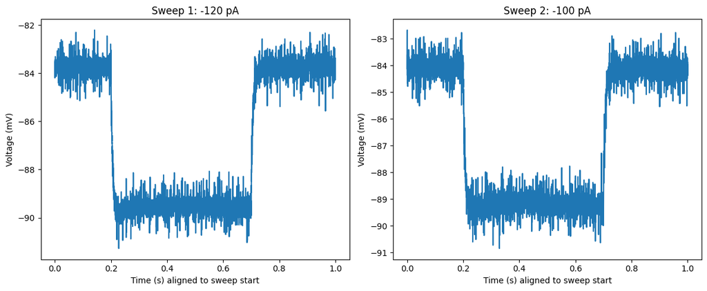

```python
import matplotlib.pyplot as plt
import numpy as np

rec_df = nwbfile.intracellular_recordings.to_dataframe()
soma_df = rec_df[rec_df[('intracellular_recordings', 'dendrite_type')] == 'Soma'].reset_index(drop=True)

fig, (ax1, ax2) = plt.subplots(1, 2, figsize=(12, 5))

for ax, row_idx in [(ax1, 0), (ax2, 1)]:
    row = soma_df.iloc[row_idx]
    resp_ref = row[('responses', 'response')]
    ts = resp_ref.timeseries
    index_start = int(resp_ref.idx_start)
    count = int(resp_ref.count)
    voltage_mV = np.asarray(ts.data[index_start:index_start + count]) * 1000.0
    rate = float(ts.rate)
    t = np.arange(count) / rate
    current_pA = float(row[('intracellular_recordings', 'stimulus_current_pA')])

    ax.plot(t, voltage_mV)
    ax.set_xlabel("Time (s) aligned to sweep start")
    ax.set_ylabel("Voltage (mV)")
    ax.set_title(f"Sweep {row_idx + 1}: {current_pA:.0f} pA")

plt.tight_layout()
plt.show()
```

Timestamps are synthetic: `np.arange(count) / rate` aligns each sweep to t=0 (sweep onset). The `idx_start` and `count` from the IRT row select the correct slice from the shared consolidated series, so sweeps recorded at different absolute times are all comparable on this relative axis.

### Systematic Data Access via Intracellular Recordings Table

While individual sweeps can be accessed from the `acquisition` module, NWB provides a higher-level interface through the `intracellular_recordings` table. This table systematically organizes all stimulus-response pairs, making it easier to:

- Link current injection parameters to voltage responses
- Access metadata for each recording sweep
- Perform systematic analysis across all experimental conditions
- Build frequency-intensity (F-I) curves and other analyses

The table approach is particularly valuable when dealing with many recording sweeps with different experimental parameters.

```python
nwbfile.intracellular_recordings.to_dataframe()
```

| (intracellular_recordings, id) | intracellular_recordings cell_id | intracellular_recordings dendrite_type | intracellular_recordings dendrite_distance_um | intracellular_recordings sweep_start_time | intracellular_recordings stimulus_current_pA | intracellular_recordings stimulus_protocol_name | intracellular_recordings condition_subfolder | electrodes id | electrodes electrode | stimuli id | stimuli stimulus | responses id | responses response |
| --- | --- | --- | --- | --- | --- | --- | --- | --- | --- | --- | --- | --- | --- |
| 0 | 3 | Soma | 0.0 | 0.0 | -120.0 | Step 1_-120 pA | LID off-state | 0 | Cell3_Soma pynwb.icephys.IntracellularElectrod... | 0 | (0, 10000, CurrentClampSeries_Cell3_Somatic_St... | 0 | (0, 10000, CurrentClampSeries_Cell3_Somatic py... |
| 1 | 3 | Soma | 0.0 | 5.0 | -100.0 | Step 2_-100 pA | LID off-state | 1 | Cell3_Soma pynwb.icephys.IntracellularElectrod... | 1 | (10000, 10000, CurrentClampSeries_Cell3_Somati... | 1 | (10000, 10000, CurrentClampSeries_Cell3_Somati... |
| 2 | 3 | Soma | 0.0 | 10.0 | -80.0 | Step 3_-80 pA | LID off-state | 2 | Cell3_Soma pynwb.icephys.IntracellularElectrod... | 2 | (20000, 10000, CurrentClampSeries_Cell3_Somati... | 2 | (20000, 10000, CurrentClampSeries_Cell3_Somati... |
| 3 | 3 | Soma | 0.0 | 16.0 | -60.0 | Step 4_-60 pA | LID off-state | 3 | Cell3_Soma pynwb.icephys.IntracellularElectrod... | 3 | (30000, 10000, CurrentClampSeries_Cell3_Somati... | 3 | (30000, 10000, CurrentClampSeries_Cell3_Somati... |
| 4 | 3 | Soma | 0.0 | 21.0 | -40.0 | Step 5_-40 pA | LID off-state | 4 | Cell3_Soma pynwb.icephys.IntracellularElectrod... | 4 | (40000, 10000, CurrentClampSeries_Cell3_Somati... | 4 | (40000, 10000, CurrentClampSeries_Cell3_Somati... |
| 5 | 3 | Soma | 0.0 | 26.0 | -20.0 | Step 6_-20 pA | LID off-state | 5 | Cell3_Soma pynwb.icephys.IntracellularElectrod... | 5 | (50000, 10000, CurrentClampSeries_Cell3_Somati... | 5 | (50000, 10000, CurrentClampSeries_Cell3_Somati... |
| 6 | 3 | Soma | 0.0 | 31.0 | 20.0 | Step 7_20 pA | LID off-state | 6 | Cell3_Soma pynwb.icephys.IntracellularElectrod... | 6 | (60000, 10000, CurrentClampSeries_Cell3_Somati... | 6 | (60000, 10000, CurrentClampSeries_Cell3_Somati... |
| 7 | 3 | Soma | 0.0 | 35.0 | 40.0 | Step 8_40 pA | LID off-state | 7 | Cell3_Soma pynwb.icephys.IntracellularElectrod... | 7 | (70000, 10000, CurrentClampSeries_Cell3_Somati... | 7 | (70000, 10000, CurrentClampSeries_Cell3_Somati... |
| 8 | 3 | Soma | 0.0 | 40.0 | 60.0 | Step 9_60 pA | LID off-state | 8 | Cell3_Soma pynwb.icephys.IntracellularElectrod... | 8 | (80000, 10000, CurrentClampSeries_Cell3_Somati... | 8 | (80000, 10000, CurrentClampSeries_Cell3_Somati... |
| 9 | 3 | Soma | 0.0 | 45.0 | 80.0 | Step 10_80 pA | LID off-state | 9 | Cell3_Soma pynwb.icephys.IntracellularElectrod... | 9 | (90000, 10000, CurrentClampSeries_Cell3_Somati... | 9 | (90000, 10000, CurrentClampSeries_Cell3_Somati... |
| 10 | 3 | Soma | 0.0 | 54.0 | 100.0 | Step 11_100 pA | LID off-state | 10 | Cell3_Soma pynwb.icephys.IntracellularElectrod... | 10 | (100000, 10000, CurrentClampSeries_Cell3_Somat... | 10 | (100000, 10000, CurrentClampSeries_Cell3_Somat... |
| 11 | 3 | Soma | 0.0 | 61.0 | 120.0 | Step 12_120 pA | LID off-state | 11 | Cell3_Soma pynwb.icephys.IntracellularElectrod... | 11 | (110000, 10000, CurrentClampSeries_Cell3_Somat... | 11 | (110000, 10000, CurrentClampSeries_Cell3_Somat... |
| 12 | 3 | Soma | 0.0 | 68.0 | 140.0 | Step 13_140 pA | LID off-state | 12 | Cell3_Soma pynwb.icephys.IntracellularElectrod... | 12 | (120000, 10000, CurrentClampSeries_Cell3_Somat... | 12 | (120000, 10000, CurrentClampSeries_Cell3_Somat... |
| 13 | 3 | Soma | 0.0 | 75.0 | 160.0 | Step 14_160 pA | LID off-state | 13 | Cell3_Soma pynwb.icephys.IntracellularElectrod... | 13 | (130000, 10000, CurrentClampSeries_Cell3_Somat... | 13 | (130000, 10000, CurrentClampSeries_Cell3_Somat... |
| 14 | 3 | Soma | 0.0 | 81.0 | 180.0 | Step 15_180 pA | LID off-state | 14 | Cell3_Soma pynwb.icephys.IntracellularElectrod... | 14 | (140000, 10000, CurrentClampSeries_Cell3_Somat... | 14 | (140000, 10000, CurrentClampSeries_Cell3_Somat... |
| 15 | 3 | Soma | 0.0 | 85.0 | 200.0 | Step 16_200 pA | LID off-state | 15 | Cell3_Soma pynwb.icephys.IntracellularElectrod... | 15 | (150000, 10000, CurrentClampSeries_Cell3_Somat... | 15 | (150000, 10000, CurrentClampSeries_Cell3_Somat... |
| 16 | 3 | Soma | 0.0 | 93.0 | 220.0 | Step 17_220 pA | LID off-state | 16 | Cell3_Soma pynwb.icephys.IntracellularElectrod... | 16 | (160000, 10000, CurrentClampSeries_Cell3_Somat... | 16 | (160000, 10000, CurrentClampSeries_Cell3_Somat... |
| 17 | 3 | Soma | 0.0 | 98.0 | 240.0 | Step 18_240 pA | LID off-state | 17 | Cell3_Soma pynwb.icephys.IntracellularElectrod... | 17 | (170000, 10000, CurrentClampSeries_Cell3_Somat... | 17 | (170000, 10000, CurrentClampSeries_Cell3_Somat... |
| 18 | 3 | Soma | 0.0 | 104.0 | 260.0 | Step 19_260 pA | LID off-state | 18 | Cell3_Soma pynwb.icephys.IntracellularElectrod... | 18 | (180000, 10000, CurrentClampSeries_Cell3_Somat... | 18 | (180000, 10000, CurrentClampSeries_Cell3_Somat... |
| 19 | 3 | Soma | 0.0 | 110.0 | 280.0 | Step 20_280 pA | LID off-state | 19 | Cell3_Soma pynwb.icephys.IntracellularElectrod... | 19 | (190000, 10000, CurrentClampSeries_Cell3_Somat... | 19 | (190000, 10000, CurrentClampSeries_Cell3_Somat... |
| 20 | 3 | Soma | 0.0 | 116.0 | 300.0 | Step 21_300 pA | LID off-state | 20 | Cell3_Soma pynwb.icephys.IntracellularElectrod... | 20 | (200000, 10000, CurrentClampSeries_Cell3_Somat... | 20 | (200000, 10000, CurrentClampSeries_Cell3_Somat... |
| 21 | 3 | Soma | 0.0 | 121.0 | 320.0 | Step 22_320pA | LID off-state | 21 | Cell3_Soma pynwb.icephys.IntracellularElectrod... | 21 | (210000, 10000, CurrentClampSeries_Cell3_Somat... | 21 | (210000, 10000, CurrentClampSeries_Cell3_Somat... |
| 22 | 3 | Soma | 0.0 | 128.0 | 340.0 | Step 23_340pA | LID off-state | 22 | Cell3_Soma pynwb.icephys.IntracellularElectrod... | 22 | (220000, 10000, CurrentClampSeries_Cell3_Somat... | 22 | (220000, 10000, CurrentClampSeries_Cell3_Somat... |
| 23 | 3 | Soma | 0.0 | 134.0 | 360.0 | Step 24_360pA | LID off-state | 23 | Cell3_Soma pynwb.icephys.IntracellularElectrod... | 23 | (230000, 10000, CurrentClampSeries_Cell3_Somat... | 23 | (230000, 10000, CurrentClampSeries_Cell3_Somat... |
| 24 | 3 | Soma | 0.0 | 140.0 | 380.0 | Step 25_380pA | LID off-state | 24 | Cell3_Soma pynwb.icephys.IntracellularElectrod... | 24 | (240000, 10000, CurrentClampSeries_Cell3_Somat... | 24 | (240000, 10000, CurrentClampSeries_Cell3_Somat... |
| 25 | 3 | Soma | 0.0 | 147.0 | 400.0 | Step 26_400pA | LID off-state | 25 | Cell3_Soma pynwb.icephys.IntracellularElectrod... | 25 | (250000, 10000, CurrentClampSeries_Cell3_Somat... | 25 | (250000, 10000, CurrentClampSeries_Cell3_Somat... |
| 26 | 3 | Proximal | 40.0 | 541.0 | 0.0 | Trio bAP | LID off-state | 26 | Cell3_Proximal1 pynwb.icephys.IntracellularEle... | 26 | (0, 40000, CurrentClampSeries_Cell3_Dendritic_... | 26 | (0, 40000, CurrentClampSeries_Cell3_Dendritic ... |
| 27 | 3 | Proximal | 40.0 | 565.0 | 0.0 | Trio bAP | LID off-state | 27 | Cell3_Proximal1 pynwb.icephys.IntracellularEle... | 27 | (40000, 40000, CurrentClampSeries_Cell3_Dendri... | 27 | (40000, 40000, CurrentClampSeries_Cell3_Dendri... |
| 28 | 3 | Proximal | 40.0 | 576.0 | 0.0 | Trio bAP | LID off-state | 28 | Cell3_Proximal1 pynwb.icephys.IntracellularEle... | 28 | (80000, 40000, CurrentClampSeries_Cell3_Dendri... | 28 | (80000, 40000, CurrentClampSeries_Cell3_Dendri... |
| 29 | 3 | Distal | 90.0 | 685.0 | 0.0 | Trio bAP | LID off-state | 29 | Cell3_Distal1 pynwb.icephys.IntracellularElect... | 29 | (120000, 40000, CurrentClampSeries_Cell3_Dendr... | 29 | (120000, 40000, CurrentClampSeries_Cell3_Dendr... |
| 30 | 3 | Distal | 90.0 | 696.0 | 0.0 | Trio bAP | LID off-state | 30 | Cell3_Distal1 pynwb.icephys.IntracellularElect... | 30 | (160000, 40000, CurrentClampSeries_Cell3_Dendr... | 30 | (160000, 40000, CurrentClampSeries_Cell3_Dendr... |
| 31 | 3 | Distal | 90.0 | 713.0 | 0.0 | Trio bAP | LID off-state | 31 | Cell3_Distal1 pynwb.icephys.IntracellularElect... | 31 | (200000, 40000, CurrentClampSeries_Cell3_Dendr... | 31 | (200000, 40000, CurrentClampSeries_Cell3_Dendr... |

```python
# soma_df was built in the previous plotting cell; reuse it here.
currents = soma_df[('intracellular_recordings', 'stimulus_current_pA')].values
print(f"{len(soma_df)} somatic sweeps, current range: {currents.min():.0f} to {currents.max():.0f} pA")
```

```
26 somatic sweeps, current range: -120 to 400 pA
```

### Accessing Individual Sweep Data Through the Table

The `intracellular_recordings` table provides references to the actual time series data. Each row contains:

- **Stimulus parameters**: Current amplitude, timing, waveform
- **Response references**: Links to the voltage recordings in the acquisition module
- **Metadata**: Electrode properties, recording conditions

Let's extract one specific stimulus-response pair to see how this referencing system works.

```python
index = min(20, len(soma_df) - 1)
row = soma_df.iloc[index]
current_in_pA = float(row[('intracellular_recordings', 'stimulus_current_pA')])

resp_ref = row[('responses', 'response')]
ts = resp_ref.timeseries
index_start = int(resp_ref.idx_start)
count = int(resp_ref.count)
voltage_mV = np.asarray(ts.data[index_start:index_start + count]) * 1000.0
rate = float(ts.rate)
aligned_times = np.arange(count) / rate

print(f"Sweep at {current_in_pA:.0f} pA: {count} samples at {rate:.0f} Hz ({count/rate*1000:.0f} ms)")
```

```
Sweep at 300 pA: 10000 samples at 10000 Hz (1000 ms)
```

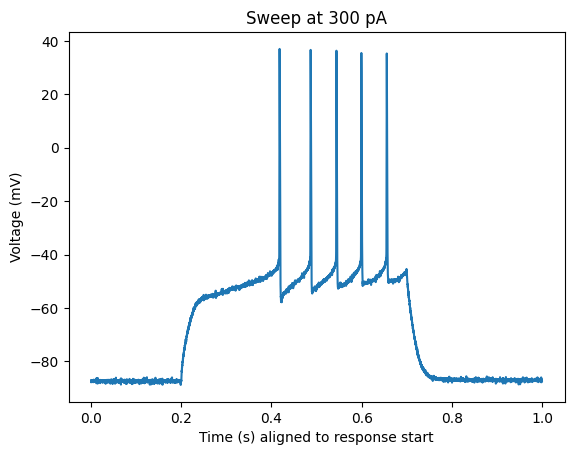

```python
plt.plot(aligned_times, voltage_mV)
plt.xlabel("Time (s) aligned to response start")
plt.ylabel("Voltage (mV)")
plt.title(f"Sweep at {current_in_pA:.0f} pA")
plt.show()
```

### Systematic Access to All Sweeps

The real power of the `intracellular_recordings` table becomes apparent when accessing multiple sweeps systematically. Rather than manually tracking individual `CurrentClampSeries` names, we can iterate through the table to access all stimulus-response pairs.

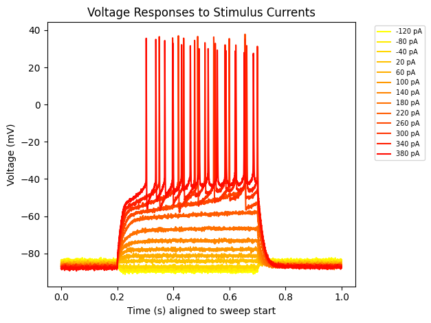

```python
colors = plt.cm.autumn_r(np.linspace(0, 1, len(soma_df)))

for i, (_, row) in enumerate(soma_df.iterrows()):
    if i % 2 == 0:
        resp_ref = row[('responses', 'response')]
        ts = resp_ref.timeseries
        index_start = int(resp_ref.idx_start)
        count = int(resp_ref.count)
        voltage_mV = np.asarray(ts.data[index_start:index_start + count]) * 1000.0
        rate = float(ts.rate)
        t = np.arange(count) / rate
        current_pA_val = float(row[('intracellular_recordings', 'stimulus_current_pA')])
        plt.plot(t, voltage_mV, label=f"{current_pA_val:.0f} pA", color=colors[i])

plt.xlabel("Time (s) aligned to sweep start")
plt.ylabel("Voltage (mV)")
plt.title("Voltage Responses to Stimulus Currents")
plt.legend(bbox_to_anchor=(1.05, 1), loc='upper left', fontsize=7)
plt.tight_layout()
plt.show()
```

We have skipped every second response to compress the map and use a sequential color map with yellow for the smallest current and red for the largest current to showcase the variation in voltage responses more clearly.

## Dendritic Excitability Experiments - Line Scans

### NWB Organization for Two-Photon Imaging Data

Dendritic excitability experiments combine patch-clamp electrophysiology with two-photon microscopy. While the `acquisition` module also contains current clamp data (accessed the same way as above), we'll focus here on the optical physiology components:

**Data stored in `processing/ophys` module:**

- **ROI Responses**: Stored as `RoiResponseSeries` objects in a `Fluorescence` data interface
- **Plane Segmentation**: Stored as `PlaneSegmentation` tables containing pixel masks that define ROI locations

These experiments typically include multiple trials for both **distal** and **proximal** dendritic locations, allowing comparison of calcium responses at different distances from the soma.

```python
# Filter for dendritic excitability experiments: paired icephys + ophys recordings.
# These combine current clamp with two-photon line-scan imaging.

def is_dspn_icephys_ophys(asset_path: str) -> bool:
    """dSPN paired current-clamp + imaging files (dendritic excitability)."""
    return get_modality(asset_path) == 'icephys+ophys' and get_cell_type(get_session_id(asset_path)) == 'dSPN'

available_assets = [asset for asset in assets_list if is_dspn_icephys_ophys(asset.path)]
```

### Filtering for Dendritic Excitability Data

First, we filter the assets to find dendritic excitability experiments from Figure 1. These files contain the two-photon imaging data combined with electrophysiology measurements.

```python
import h5py
import remfile
from pynwb import NWBHDF5IO

# Get one of the assets
asset = available_assets[0]
s3_url = asset.get_content_url(follow_redirects=1, strip_query=False)
file_system = remfile.File(s3_url, disk_cache=remfile.DiskCache("nwb-cache"))
file = h5py.File(file_system, mode="r")
io = NWBHDF5IO(file=file, load_namespaces=True)
nwbfile = io.read()
nwbfile
```

root (NWBFile)

session_description: Per-mouse-day icephys merge for Subject20160812LIDOFFtDTomato: 1 patched cell(s), category=LID OFF, animal/reporter=tD-Tomato. All cells from this mouse on this day collected in one NWB file with the icephys hierarchical chain populated (IntracellularRecordings -> Simultaneous -> Sequential -> Repetitions -> ExperimentalConditions).

identifier: 6617ecb6-4c3f-45eb-a797-2aab013f3d35

**session_start_time**

2016-08-12 17:23:03-05:00

**timestamps_reference_time**

2016-08-12 17:23:03-05:00

**file_create_date**

**0**

2026-05-24 16:22:57.357464-06:00

**experimenter**

('Zhai, Shenyu', 'Cui, Qiaoling', 'Wokosin, David', 'Sun, Linqing', 'Tkatch, Tatiana', 'Crittenden, Jill R.', 'Graybiel, Ann M.', 'Surmeier, D. James')

**icephys_electrodes**

**Cell3_Distal1 (IntracellularElectrode)**

description: Patch-clamp electrode at distal dendrite location 1 of Cell 3 (~90 um from soma).

location: Caudoputamen

**device (Device)**

description: Molecular Devices MultiClamp 700B patch-clamp amplifier.

cell_id: Cell3

**Cell3_Proximal1 (IntracellularElectrode)**

description: Patch-clamp electrode at proximal dendrite location 1 of Cell 3 (~40 um from soma).

location: Caudoputamen

**device (Device)**

description: Molecular Devices MultiClamp 700B patch-clamp amplifier.

cell_id: Cell3

**Cell3_Soma (IntracellularElectrode)**

description: Patch-clamp electrode at the soma of Cell 3, recorded as part of the mouse-day icephys merge.

location: Caudoputamen

**device (Device)**

description: Molecular Devices MultiClamp 700B patch-clamp amplifier.

cell_id: Cell3

**related_publications**

('https://doi.org/10.1101/2025.01.02.631090',)

**acquisition**

**CurrentClampSeries_Cell3_Dendritic (CurrentClampSeries)**

starting_time: 541.0

rate: 10000.0

resolution: -1.0

comments: no comments

description: Concatenated current-clamp recordings for Cell 3 dend_excitability. 6 sweeps merged end-to-end (Pattern B). Per-sweep wall-clock offsets stored in IntracellularRecordingsTable.sweep_start_time.

conversion: 1.0

offset: 0.0

unit: volts

**data**

HDF5 dataset

| Data type | float32 |
| --- | --- |
| Shape | (240000,) |
| Array size | 937.50 KiB |
| Chunk shape | (240000,) |
| Compression | gzip |
| Compression opts | 4 |
| Uncompressed size (bytes) | 960000 |
| Compressed size (bytes) | 285418 |
| Compression ratio | 3.3634879369906594 |

starting_time_unit: seconds

**electrode (IntracellularElectrode)**

description: Patch-clamp electrode at proximal dendrite location 1 of Cell 3 (~40 um from soma).

location: Caudoputamen

**device (Device)**

description: Molecular Devices MultiClamp 700B patch-clamp amplifier.

cell_id: Cell3

gain: 1.0

stimulus_description: N/A

**CurrentClampSeries_Cell3_Somatic (CurrentClampSeries)**

starting_time: 0.0

rate: 10000.0

resolution: -1.0

comments: no comments

description: Concatenated current-clamp recordings for Cell 3 soma_excitability. 26 sweeps merged end-to-end (Pattern B). Per-sweep wall-clock offsets stored in IntracellularRecordingsTable.sweep_start_time.

conversion: 1.0

offset: 0.0

unit: volts

**data**

HDF5 dataset

| Data type | float32 |
| --- | --- |
| Shape | (260000,) |
| Array size | 1015.62 KiB |
| Chunk shape | (260000,) |
| Compression | gzip |
| Compression opts | 4 |
| Uncompressed size (bytes) | 1040000 |
| Compressed size (bytes) | 329622 |
| Compression ratio | 3.1551292086086486 |

starting_time_unit: seconds

**electrode (IntracellularElectrode)**

description: Patch-clamp electrode at the soma of Cell 3, recorded as part of the mouse-day icephys merge.

location: Caudoputamen

**device (Device)**

description: Molecular Devices MultiClamp 700B patch-clamp amplifier.

cell_id: Cell3

gain: 1.0

stimulus_description: N/A

**ImageLineScanSource (Images)**

description: Source images for line scan experiments: field of view snapshots with scan-line overlay, used to identify the recorded region. One image per trio sweep per channel (cell, channel, dendrite location, trial).

**ImageAlexa568Cell3Distal1Trial001 (Image)**

description: Source image (field of view with scan line overlay) for Cell 3 Distal location 1, channel Ch1, trio sweep 1 (IRT row 29, sweep_start_time=685.0s).

**ImageAlexa568Cell3Distal1Trial002 (Image)**

description: Source image (field of view with scan line overlay) for Cell 3 Distal location 1, channel Ch1, trio sweep 2 (IRT row 30, sweep_start_time=696.0s).

**ImageAlexa568Cell3Distal1Trial003 (Image)**

description: Source image (field of view with scan line overlay) for Cell 3 Distal location 1, channel Ch1, trio sweep 3 (IRT row 31, sweep_start_time=713.0s).

**ImageAlexa568Cell3Proximal1Trial001 (Image)**

description: Source image (field of view with scan line overlay) for Cell 3 Proximal location 1, channel Ch1, trio sweep 1 (IRT row 26, sweep_start_time=541.0s).

**ImageAlexa568Cell3Proximal1Trial002 (Image)**

description: Source image (field of view with scan line overlay) for Cell 3 Proximal location 1, channel Ch1, trio sweep 2 (IRT row 27, sweep_start_time=565.0s).

**ImageAlexa568Cell3Proximal1Trial003 (Image)**

description: Source image (field of view with scan line overlay) for Cell 3 Proximal location 1, channel Ch1, trio sweep 3 (IRT row 28, sweep_start_time=576.0s).

**ImageFluo4Cell3Distal1Trial001 (Image)**

description: Source image (field of view with scan line overlay) for Cell 3 Distal location 1, channel Ch2, trio sweep 1 (IRT row 29, sweep_start_time=685.0s).

**ImageFluo4Cell3Distal1Trial002 (Image)**

description: Source image (field of view with scan line overlay) for Cell 3 Distal location 1, channel Ch2, trio sweep 2 (IRT row 30, sweep_start_time=696.0s).

**ImageFluo4Cell3Distal1Trial003 (Image)**

description: Source image (field of view with scan line overlay) for Cell 3 Distal location 1, channel Ch2, trio sweep 3 (IRT row 31, sweep_start_time=713.0s).

**ImageFluo4Cell3Proximal1Trial001 (Image)**

description: Source image (field of view with scan line overlay) for Cell 3 Proximal location 1, channel Ch2, trio sweep 1 (IRT row 26, sweep_start_time=541.0s).

**ImageFluo4Cell3Proximal1Trial002 (Image)**

description: Source image (field of view with scan line overlay) for Cell 3 Proximal location 1, channel Ch2, trio sweep 2 (IRT row 27, sweep_start_time=565.0s).

**ImageFluo4Cell3Proximal1Trial003 (Image)**

description: Source image (field of view with scan line overlay) for Cell 3 Proximal location 1, channel Ch2, trio sweep 3 (IRT row 28, sweep_start_time=576.0s).

**LineScanCell3_Distal1_Ch1 (TimeSeries)**

starting_time: 685.0

rate: 685.9575807316062

resolution: -1.0

comments: no comments

description: Bruker line-scan kymograph for Cell 3 Distal location 1, channel Ch1. All trio sweeps at this location concatenated along the time axis (rows = line repetitions, columns = pixels along the scan line). Per-sweep slices are exposed via processing/recordings_index/RecordingsIndexTable (line_scan_ch1 column). starting_time is the wall-clock of the first contributing sweep relative to session_start_time.

conversion: 1.0

offset: 0.0

unit: a.u.

**data**

HDF5 dataset

| Data type | uint16 |
| --- | --- |
| Shape | (7500, 19) |
| Array size | 278.32 KiB |
| Chunk shape | (7500, 19) |
| Compression | gzip |
| Compression opts | 4 |
| Uncompressed size (bytes) | 285000 |
| Compressed size (bytes) | 224718 |
| Compression ratio | 1.2682562144554508 |

starting_time_unit: seconds

**LineScanCell3_Distal1_Ch2 (TimeSeries)**

starting_time: 685.0

rate: 685.9575807316062

resolution: -1.0

comments: no comments

description: Bruker line-scan kymograph for Cell 3 Distal location 1, channel Ch2. All trio sweeps at this location concatenated along the time axis (rows = line repetitions, columns = pixels along the scan line). Per-sweep slices are exposed via processing/recordings_index/RecordingsIndexTable (line_scan_ch2 column). starting_time is the wall-clock of the first contributing sweep relative to session_start_time.

conversion: 1.0

offset: 0.0

unit: a.u.

**data**

HDF5 dataset

| Data type | uint16 |
| --- | --- |
| Shape | (7500, 19) |
| Array size | 278.32 KiB |
| Chunk shape | (7500, 19) |
| Compression | gzip |
| Compression opts | 4 |
| Uncompressed size (bytes) | 285000 |
| Compressed size (bytes) | 182657 |
| Compression ratio | 1.56030154880459 |

starting_time_unit: seconds

**LineScanCell3_Proximal1_Ch1 (TimeSeries)**

starting_time: 541.0

rate: 685.8711086838748

resolution: -1.0

comments: no comments

description: Bruker line-scan kymograph for Cell 3 Proximal location 1, channel Ch1. All trio sweeps at this location concatenated along the time axis (rows = line repetitions, columns = pixels along the scan line). Per-sweep slices are exposed via processing/recordings_index/RecordingsIndexTable (line_scan_ch1 column). starting_time is the wall-clock of the first contributing sweep relative to session_start_time.

conversion: 1.0

offset: 0.0

unit: a.u.

**data**

HDF5 dataset

| Data type | uint16 |
| --- | --- |
| Shape | (7500, 20) |
| Array size | 292.97 KiB |
| Chunk shape | (7500, 20) |
| Compression | gzip |
| Compression opts | 4 |
| Uncompressed size (bytes) | 300000 |
| Compressed size (bytes) | 244955 |
| Compression ratio | 1.2247147435243209 |

starting_time_unit: seconds

**LineScanCell3_Proximal1_Ch2 (TimeSeries)**

starting_time: 541.0

rate: 685.8711086838748

resolution: -1.0

comments: no comments

description: Bruker line-scan kymograph for Cell 3 Proximal location 1, channel Ch2. All trio sweeps at this location concatenated along the time axis (rows = line repetitions, columns = pixels along the scan line). Per-sweep slices are exposed via processing/recordings_index/RecordingsIndexTable (line_scan_ch2 column). starting_time is the wall-clock of the first contributing sweep relative to session_start_time.

conversion: 1.0

offset: 0.0

unit: a.u.

**data**

HDF5 dataset

| Data type | uint16 |
| --- | --- |
| Shape | (7500, 20) |
| Array size | 292.97 KiB |
| Chunk shape | (7500, 20) |
| Compression | gzip |
| Compression opts | 4 |
| Uncompressed size (bytes) | 300000 |
| Compressed size (bytes) | 202853 |
| Compression ratio | 1.478903442394246 |

starting_time_unit: seconds

**stimulus**

**CurrentClampSeries_Cell3_Dendritic_Stimulus (CurrentClampStimulusSeries)**

starting_time: 541.0

rate: 10000.0

resolution: -1.0

comments: no comments

description: Commanded current waveform paired with CurrentClampSeries_Cell3_Dendritic. Synthesized from each sweep's Bruker VoltageOutput XML (step amplitude × pulse width); the per-sweep amplitude is also exposed via the IntracellularRecordingsTable.stimulus_current_pA column.

conversion: 1.0

offset: 0.0

unit: amperes

**data**

HDF5 dataset

| Data type | float32 |
| --- | --- |
| Shape | (240000,) |
| Array size | 937.50 KiB |
| Chunk shape | (240000,) |
| Compression | gzip |
| Compression opts | 4 |
| Uncompressed size (bytes) | 960000 |
| Compressed size (bytes) | 952 |
| Compression ratio | 1008.4033613445379 |

starting_time_unit: seconds

**electrode (IntracellularElectrode)**

description: Patch-clamp electrode at proximal dendrite location 1 of Cell 3 (~40 um from soma).

location: Caudoputamen

**device (Device)**

description: Molecular Devices MultiClamp 700B patch-clamp amplifier.

cell_id: Cell3

gain: 1.0

stimulus_description: N/A

**CurrentClampSeries_Cell3_Somatic_Stimulus (CurrentClampStimulusSeries)**

starting_time: 0.0

rate: 10000.0

resolution: -1.0

comments: no comments

description: Commanded current waveform paired with CurrentClampSeries_Cell3_Somatic. Synthesized from each sweep's Bruker VoltageOutput XML (step amplitude × pulse width); the per-sweep amplitude is also exposed via the IntracellularRecordingsTable.stimulus_current_pA column.

conversion: 1.0

offset: 0.0

unit: amperes

**data**

HDF5 dataset

| Data type | float32 |
| --- | --- |
| Shape | (260000,) |
| Array size | 1015.62 KiB |
| Chunk shape | (260000,) |
| Compression | gzip |
| Compression opts | 4 |
| Uncompressed size (bytes) | 1040000 |
| Compressed size (bytes) | 1510 |
| Compression ratio | 688.7417218543046 |

starting_time_unit: seconds

**electrode (IntracellularElectrode)**

description: Patch-clamp electrode at the soma of Cell 3, recorded as part of the mouse-day icephys merge.

location: Caudoputamen

**device (Device)**

description: Molecular Devices MultiClamp 700B patch-clamp amplifier.

cell_id: Cell3

gain: 1.0

stimulus_description: N/A

**keywords**

HDF5 dataset

| Data type | object |
| --- | --- |
| Shape | (11,) |
| Array size | 88.00 bytes |
| Chunk shape | None |
| Compression | None |
| Compression opts | None |
| Uncompressed size (bytes) | 88 |
| Compressed size (bytes) | 176 |
| Compression ratio | 0.5 |

['corticostriatal' 'Parkinson disease' 'PD' 'neurodegeneration' 'dopamine depletion' 'striatum' 'levodopa-induced dyskinesia' 'dSPNs' 'iSPNs' 'indirect pathway' 'direct pathway']

**processing**

**ophys (ProcessingModule)**

description: Optical physiology data: line-scan ROI responses + pixel-mask segmentations for dendritic excitability recordings.

**Fluorescence (Fluorescence)**

**RoiResponseSeriesAlexa568Cell3Distal1 (RoiResponseSeries)**

starting_time: 685.0

rate: 687.6397521290825

resolution: -1.0

comments: no comments

description: Line-scan fluorescence profile (average across pixels along the scan line) for Cell 3 Distal location 1, channel Ch1. All trio sweeps at this location concatenated; per-sweep slices via processing/recordings_index/RecordingsIndexTable.

conversion: 1.0

offset: 0.0

unit: a.u.

**data**

HDF5 dataset

| Data type | float32 |
| --- | --- |
| Shape | (7500,) |
| Array size | 29.30 KiB |
| Chunk shape | (7500,) |
| Compression | gzip |
| Compression opts | 4 |
| Uncompressed size (bytes) | 30000 |
| Compressed size (bytes) | 23791 |
| Compression ratio | 1.2609810432516497 |

starting_time_unit: seconds

**rois (DynamicTableRegion)**

description: Line-scan ROI for Cell 3 Distal loc 1

**table (PlaneSegmentation)**

description: Line-scan ROIs: each row is the scan line for one (cell, channel, dendrite location). The pixel_mask gives the (x, y, weight) coords of the line on the source image.

**imaging_plane (ImagingPlane)**

**optical_channel**

**0 (OpticalChannel)**

description: Composite optical channel for two-channel line-scan recording.

emission_lambda: nan

description: Two-photon line-scan imaging plane in the dorsolateral striatum (Caudoputamen).

**device (Device)**

description: Bruker Prairie View two-photon microscope.

excitation_lambda: 810.0

indicator: Fluo-4 (Ca2+) + Alexa Fluor 568 (reference)

location: Caudoputamen

conversion: 1.0

unit: meters

origin_coords_unit: meters

grid_spacing_unit: meters

**columns**

**pixel_mask**

Pixel masks for each ROI

**table**

| id | pixel_mask |
| --- | --- |
| 0 | [[88, 73, 1.0], [89, 73, 1.0], [90, 73, 1.0], [91, 73, 1.0], [92, 73, 1.0], [93, 73, 1.0], [94, 73, 1.0], [95, 73, 1.0], [96, 73, 1.0], [97, 73, 1.0], [98, 73, 1.0], [99, 73, 1.0], [100, 73, 1.0], [10… |
| 1 | [[88, 73, 1.0], [89, 73, 1.0], [90, 73, 1.0], [91, 73, 1.0], [92, 73, 1.0], [93, 73, 1.0], [94, 73, 1.0], [95, 73, 1.0], [96, 73, 1.0], [97, 73, 1.0], [98, 73, 1.0], [99, 73, 1.0], [100, 73, 1.0], [10… |
| 2 | [[60, 71, 1.0], [61, 71, 1.0], [62, 71, 1.0], [63, 71, 1.0], [64, 71, 1.0], [65, 71, 1.0], [66, 71, 1.0], [67, 71, 1.0], [68, 71, 1.0], [69, 71, 1.0], [70, 71, 1.0], [71, 71, 1.0], [72, 71, 1.0], [73,… |
| 3 | [[60, 71, 1.0], [61, 71, 1.0], [62, 71, 1.0], [63, 71, 1.0], [64, 71, 1.0], [65, 71, 1.0], [66, 71, 1.0], [67, 71, 1.0], [68, 71, 1.0], [69, 71, 1.0], [70, 71, 1.0], [71, 71, 1.0], [72, 71, 1.0], [73,… |

**RoiResponseSeriesAlexa568Cell3Proximal1 (RoiResponseSeries)**

starting_time: 541.0

rate: 688.1801007015858

resolution: -1.0

comments: no comments

description: Line-scan fluorescence profile (average across pixels along the scan line) for Cell 3 Proximal location 1, channel Ch1. All trio sweeps at this location concatenated; per-sweep slices via processing/recordings_index/RecordingsIndexTable.

conversion: 1.0

offset: 0.0

unit: a.u.

**data**

HDF5 dataset

| Data type | float32 |
| --- | --- |
| Shape | (7500,) |
| Array size | 29.30 KiB |
| Chunk shape | (7500,) |
| Compression | gzip |
| Compression opts | 4 |
| Uncompressed size (bytes) | 30000 |
| Compressed size (bytes) | 23973 |
| Compression ratio | 1.2514078338130397 |

starting_time_unit: seconds

**rois (DynamicTableRegion)**

description: Line-scan ROI for Cell 3 Proximal loc 1

**table (PlaneSegmentation)**

description: Line-scan ROIs: each row is the scan line for one (cell, channel, dendrite location). The pixel_mask gives the (x, y, weight) coords of the line on the source image.

**imaging_plane (ImagingPlane)**

**optical_channel**

**0 (OpticalChannel)**

description: Composite optical channel for two-channel line-scan recording.

emission_lambda: nan

description: Two-photon line-scan imaging plane in the dorsolateral striatum (Caudoputamen).

**device (Device)**

description: Bruker Prairie View two-photon microscope.

excitation_lambda: 810.0

indicator: Fluo-4 (Ca2+) + Alexa Fluor 568 (reference)

location: Caudoputamen

conversion: 1.0

unit: meters

origin_coords_unit: meters

grid_spacing_unit: meters

**columns**

**pixel_mask**

Pixel masks for each ROI

**table**

| id | pixel_mask |
| --- | --- |
| 0 | [[88, 73, 1.0], [89, 73, 1.0], [90, 73, 1.0], [91, 73, 1.0], [92, 73, 1.0], [93, 73, 1.0], [94, 73, 1.0], [95, 73, 1.0], [96, 73, 1.0], [97, 73, 1.0], [98, 73, 1.0], [99, 73, 1.0], [100, 73, 1.0], [10… |
| 1 | [[88, 73, 1.0], [89, 73, 1.0], [90, 73, 1.0], [91, 73, 1.0], [92, 73, 1.0], [93, 73, 1.0], [94, 73, 1.0], [95, 73, 1.0], [96, 73, 1.0], [97, 73, 1.0], [98, 73, 1.0], [99, 73, 1.0], [100, 73, 1.0], [10… |
| 2 | [[60, 71, 1.0], [61, 71, 1.0], [62, 71, 1.0], [63, 71, 1.0], [64, 71, 1.0], [65, 71, 1.0], [66, 71, 1.0], [67, 71, 1.0], [68, 71, 1.0], [69, 71, 1.0], [70, 71, 1.0], [71, 71, 1.0], [72, 71, 1.0], [73,… |
| 3 | [[60, 71, 1.0], [61, 71, 1.0], [62, 71, 1.0], [63, 71, 1.0], [64, 71, 1.0], [65, 71, 1.0], [66, 71, 1.0], [67, 71, 1.0], [68, 71, 1.0], [69, 71, 1.0], [70, 71, 1.0], [71, 71, 1.0], [72, 71, 1.0], [73,… |

**RoiResponseSeriesFluo4Cell3Distal1 (RoiResponseSeries)**

starting_time: 685.0

rate: 687.6397521290825

resolution: -1.0

comments: no comments

description: Line-scan fluorescence profile (average across pixels along the scan line) for Cell 3 Distal location 1, channel Ch2. All trio sweeps at this location concatenated; per-sweep slices via processing/recordings_index/RecordingsIndexTable.

conversion: 1.0

offset: 0.0

unit: a.u.

**data**

HDF5 dataset

| Data type | float32 |
| --- | --- |
| Shape | (7500,) |
| Array size | 29.30 KiB |
| Chunk shape | (7500,) |
| Compression | gzip |
| Compression opts | 4 |
| Uncompressed size (bytes) | 30000 |
| Compressed size (bytes) | 24007 |
| Compression ratio | 1.2496355229724663 |

starting_time_unit: seconds

**rois (DynamicTableRegion)**

description: Line-scan ROI for Cell 3 Distal loc 1

**table (PlaneSegmentation)**

description: Line-scan ROIs: each row is the scan line for one (cell, channel, dendrite location). The pixel_mask gives the (x, y, weight) coords of the line on the source image.

**imaging_plane (ImagingPlane)**

**optical_channel**

**0 (OpticalChannel)**

description: Composite optical channel for two-channel line-scan recording.

emission_lambda: nan

description: Two-photon line-scan imaging plane in the dorsolateral striatum (Caudoputamen).

**device (Device)**

description: Bruker Prairie View two-photon microscope.

excitation_lambda: 810.0

indicator: Fluo-4 (Ca2+) + Alexa Fluor 568 (reference)

location: Caudoputamen

conversion: 1.0

unit: meters

origin_coords_unit: meters

grid_spacing_unit: meters

**columns**

**pixel_mask**

Pixel masks for each ROI

**table**

| id | pixel_mask |
| --- | --- |
| 0 | [[88, 73, 1.0], [89, 73, 1.0], [90, 73, 1.0], [91, 73, 1.0], [92, 73, 1.0], [93, 73, 1.0], [94, 73, 1.0], [95, 73, 1.0], [96, 73, 1.0], [97, 73, 1.0], [98, 73, 1.0], [99, 73, 1.0], [100, 73, 1.0], [10… |
| 1 | [[88, 73, 1.0], [89, 73, 1.0], [90, 73, 1.0], [91, 73, 1.0], [92, 73, 1.0], [93, 73, 1.0], [94, 73, 1.0], [95, 73, 1.0], [96, 73, 1.0], [97, 73, 1.0], [98, 73, 1.0], [99, 73, 1.0], [100, 73, 1.0], [10… |
| 2 | [[60, 71, 1.0], [61, 71, 1.0], [62, 71, 1.0], [63, 71, 1.0], [64, 71, 1.0], [65, 71, 1.0], [66, 71, 1.0], [67, 71, 1.0], [68, 71, 1.0], [69, 71, 1.0], [70, 71, 1.0], [71, 71, 1.0], [72, 71, 1.0], [73,… |
| 3 | [[60, 71, 1.0], [61, 71, 1.0], [62, 71, 1.0], [63, 71, 1.0], [64, 71, 1.0], [65, 71, 1.0], [66, 71, 1.0], [67, 71, 1.0], [68, 71, 1.0], [69, 71, 1.0], [70, 71, 1.0], [71, 71, 1.0], [72, 71, 1.0], [73,… |

**RoiResponseSeriesFluo4Cell3Proximal1 (RoiResponseSeries)**

starting_time: 541.0

rate: 688.1801007015858

resolution: -1.0

comments: no comments

description: Line-scan fluorescence profile (average across pixels along the scan line) for Cell 3 Proximal location 1, channel Ch2. All trio sweeps at this location concatenated; per-sweep slices via processing/recordings_index/RecordingsIndexTable.

conversion: 1.0

offset: 0.0

unit: a.u.

**data**

HDF5 dataset

| Data type | float32 |
| --- | --- |
| Shape | (7500,) |
| Array size | 29.30 KiB |
| Chunk shape | (7500,) |
| Compression | gzip |
| Compression opts | 4 |
| Uncompressed size (bytes) | 30000 |
| Compressed size (bytes) | 25064 |
| Compression ratio | 1.1969358442387488 |

starting_time_unit: seconds

**rois (DynamicTableRegion)**

description: Line-scan ROI for Cell 3 Proximal loc 1

**table (PlaneSegmentation)**

description: Line-scan ROIs: each row is the scan line for one (cell, channel, dendrite location). The pixel_mask gives the (x, y, weight) coords of the line on the source image.

**imaging_plane (ImagingPlane)**

**optical_channel**

**0 (OpticalChannel)**

description: Composite optical channel for two-channel line-scan recording.

emission_lambda: nan

description: Two-photon line-scan imaging plane in the dorsolateral striatum (Caudoputamen).

**device (Device)**

description: Bruker Prairie View two-photon microscope.

excitation_lambda: 810.0

indicator: Fluo-4 (Ca2+) + Alexa Fluor 568 (reference)

location: Caudoputamen

conversion: 1.0

unit: meters

origin_coords_unit: meters

grid_spacing_unit: meters

**columns**

**pixel_mask**

Pixel masks for each ROI

**table**

| id | pixel_mask |
| --- | --- |
| 0 | [[88, 73, 1.0], [89, 73, 1.0], [90, 73, 1.0], [91, 73, 1.0], [92, 73, 1.0], [93, 73, 1.0], [94, 73, 1.0], [95, 73, 1.0], [96, 73, 1.0], [97, 73, 1.0], [98, 73, 1.0], [99, 73, 1.0], [100, 73, 1.0], [10… |
| 1 | [[88, 73, 1.0], [89, 73, 1.0], [90, 73, 1.0], [91, 73, 1.0], [92, 73, 1.0], [93, 73, 1.0], [94, 73, 1.0], [95, 73, 1.0], [96, 73, 1.0], [97, 73, 1.0], [98, 73, 1.0], [99, 73, 1.0], [100, 73, 1.0], [10… |
| 2 | [[60, 71, 1.0], [61, 71, 1.0], [62, 71, 1.0], [63, 71, 1.0], [64, 71, 1.0], [65, 71, 1.0], [66, 71, 1.0], [67, 71, 1.0], [68, 71, 1.0], [69, 71, 1.0], [70, 71, 1.0], [71, 71, 1.0], [72, 71, 1.0], [73,… |
| 3 | [[60, 71, 1.0], [61, 71, 1.0], [62, 71, 1.0], [63, 71, 1.0], [64, 71, 1.0], [65, 71, 1.0], [66, 71, 1.0], [67, 71, 1.0], [68, 71, 1.0], [69, 71, 1.0], [70, 71, 1.0], [71, 71, 1.0], [72, 71, 1.0], [73,… |

**ImageSegmentation (ImageSegmentation)**

**PlaneSegmentationLineScan (PlaneSegmentation)**

description: Line-scan ROIs: each row is the scan line for one (cell, channel, dendrite location). The pixel_mask gives the (x, y, weight) coords of the line on the source image.

**imaging_plane (ImagingPlane)**

**optical_channel**

**0 (OpticalChannel)**

description: Composite optical channel for two-channel line-scan recording.

emission_lambda: nan

description: Two-photon line-scan imaging plane in the dorsolateral striatum (Caudoputamen).

**device (Device)**

description: Bruker Prairie View two-photon microscope.

excitation_lambda: 810.0

indicator: Fluo-4 (Ca2+) + Alexa Fluor 568 (reference)

location: Caudoputamen

conversion: 1.0

unit: meters

origin_coords_unit: meters

grid_spacing_unit: meters

**columns**

**pixel_mask**

Pixel masks for each ROI

**table**

| id | pixel_mask |
| --- | --- |
| 0 | [[88, 73, 1.0], [89, 73, 1.0], [90, 73, 1.0], [91, 73, 1.0], [92, 73, 1.0], [93, 73, 1.0], [94, 73, 1.0], [95, 73, 1.0], [96, 73, 1.0], [97, 73, 1.0], [98, 73, 1.0], [99, 73, 1.0], [100, 73, 1.0], [10… |
| 1 | [[88, 73, 1.0], [89, 73, 1.0], [90, 73, 1.0], [91, 73, 1.0], [92, 73, 1.0], [93, 73, 1.0], [94, 73, 1.0], [95, 73, 1.0], [96, 73, 1.0], [97, 73, 1.0], [98, 73, 1.0], [99, 73, 1.0], [100, 73, 1.0], [10… |
| 2 | [[60, 71, 1.0], [61, 71, 1.0], [62, 71, 1.0], [63, 71, 1.0], [64, 71, 1.0], [65, 71, 1.0], [66, 71, 1.0], [67, 71, 1.0], [68, 71, 1.0], [69, 71, 1.0], [70, 71, 1.0], [71, 71, 1.0], [72, 71, 1.0], [73,… |
| 3 | [[60, 71, 1.0], [61, 71, 1.0], [62, 71, 1.0], [63, 71, 1.0], [64, 71, 1.0], [65, 71, 1.0], [66, 71, 1.0], [67, 71, 1.0], [68, 71, 1.0], [69, 71, 1.0], [70, 71, 1.0], [71, 71, 1.0], [72, 71, 1.0], [73,… |

**recordings_index (ProcessingModule)**

description: Cross-modality and cross-table lookup helpers for the per-mouse-day icephys data. Contains the RecordingsIndexTable that denormalizes the canonical icephys chain for one-stop pandas-style filtering.

**RecordingsIndexTable (DynamicTable)**

description: Denormalized lookup for fast analyst queries. One row per icephys sweep, mirroring the order of IntracellularRecordingsTable. Carries per-sweep metadata (cell_id, condition_subfolder, dendrite_type, dendrite_distance_um, stimulus_current_pA, sweep_start_time_s) plus DynamicTableRegion pointers to the full icephys hierarchical chain (irt_row, simultaneous_row, sequential_row, repetition_row, experimental_condition_row) and TimeSeriesReference slices into the paired line-scan TimeSeries (line_scan_ch1, line_scan_ch2). This is a query helper; the canonical icephys chain is still authoritative.

**columns**

**cell_id**

Cell index within the mouse-day.

**condition_subfolder**

Raw lab condition subfolder for this sweep (e.g., 'LID off-state').

**dendrite_type**

Compartment of the recording electrode: Soma, Proximal, or Distal.

**dendrite_distance_um**

Approximate distance from soma in micrometers (0 for Soma, 40 for Proximal, 90 for Distal).

**stimulus_current_pA**

Commanded current-step amplitude in picoamperes for this sweep.

**sweep_start_time_s**

Wall-clock start time of this sweep in seconds, relative to session_start_time.

**irt_row**

Reference to the corresponding row in IntracellularRecordingsTable.

**simultaneous_row**

Reference to the corresponding row in icephys_simultaneous_recordings.

**sequential_row**

Reference to the corresponding row in icephys_sequential_recordings.

**repetition_row**

Reference to the corresponding row in icephys_repetitions.

**experimental_condition_row**

Reference to the corresponding row in icephys_experimental_conditions.

**line_scan_ch1**

Reference to the paired Alexa Fluor 568 reference channel slice (R0 for ratiometric Ca2+ calculations). idx_start=-1 for sweeps without line-scan imaging (somatic).

**line_scan_ch2**

Reference to the paired Fluo-4 calcium signal channel slice (G in (G-G0)/G0R0). idx_start=-1 for sweeps without line-scan imaging (somatic).

**roi_response_ch1**

Reference to the paired Alexa Fluor 568 ROI response slice (mean fluorescence along the scan line per time sample). idx_start=-1 for sweeps without imaging.

**roi_response_ch2**

Reference to the paired Fluo-4 ROI response slice. idx_start=-1 for sweeps without imaging.

**table**

| id | cell_id | condition_subfolder | dendrite_type | dendrite_distance_um | stimulus_current_pA | sweep_start_time_s | irt_row | simultaneous_row | sequential_row | repetition_row | experimental_condition_row | line_scan_ch1 | line_scan_ch2 | roi_response_ch1 | roi_response_ch2 |
| --- | --- | --- | --- | --- | --- | --- | --- | --- | --- | --- | --- | --- | --- | --- | --- |
| 0 | 3 | LID off-state | Soma | 0.0 | -120.0 | 0.0 | 0 | 0 | 0 | 0 | 0 | (None, None, None) | (None, None, None) | (None, None, None) | (None, None, None) |
| 1 | 3 | LID off-state | Soma | 0.0 | -100.0 | 5.0 | 1 | 1 | 0 | 0 | 0 | (None, None, None) | (None, None, None) | (None, None, None) | (None, None, None) |
| 2 | 3 | LID off-state | Soma | 0.0 | -80.0 | 10.0 | 2 | 2 | 0 | 0 | 0 | (None, None, None) | (None, None, None) | (None, None, None) | (None, None, None) |
| 3 | 3 | LID off-state | Soma | 0.0 | -60.0 | 16.0 | 3 | 3 | 0 | 0 | 0 | (None, None, None) | (None, None, None) | (None, None, None) | (None, None, None) |

... and 28 more row(s).

**devices**

**BrukerFluorescenceMicroscope (Device)**

description: Bruker Prairie View two-photon microscope.

**BrukerUltima (Device)**

description: Bruker Ultima In Vitro multiphoton microscope (mouse-day merge prototype).

**model (DeviceModel)**

manufacturer: Bruker Corporation

model_number: Ultima In Vitro

description: Bruker Ultima In Vitro multiphoton microscope system (Bruker, Billerica, MA), mounted on an Olympus BX-51 upright microscope chassis for ex vivo two-photon laser-scanning imaging. Used in conjunction with patch-clamp electrophysiology and a Chameleon Ultra II (Coherent) tunable Ti:sapphire laser.

**MultiClamp700B (Device)**

description: Molecular Devices MultiClamp 700B patch-clamp amplifier.

**device_models**

**BrukerUltimaInVitroModel (DeviceModel)**

manufacturer: Bruker Corporation

model_number: Ultima In Vitro

description: Bruker Ultima In Vitro multiphoton microscope system (Bruker, Billerica, MA), mounted on an Olympus BX-51 upright microscope chassis for ex vivo two-photon laser-scanning imaging. Used in conjunction with patch-clamp electrophysiology and a Chameleon Ultra II (Coherent) tunable Ti:sapphire laser.

**imaging_planes**

**ImagingPlaneLineScan (ImagingPlane)**

**optical_channel**

**0 (OpticalChannel)**

description: Composite optical channel for two-channel line-scan recording.

emission_lambda: nan

description: Two-photon line-scan imaging plane in the dorsolateral striatum (Caudoputamen).

**device (Device)**

description: Bruker Prairie View two-photon microscope.

excitation_lambda: 810.0

indicator: Fluo-4 (Ca2+) + Alexa Fluor 568 (reference)

location: Caudoputamen

conversion: 1.0

unit: meters

origin_coords_unit: meters

grid_spacing_unit: meters

**subject (Subject)**

age: P7W/P12W

age__reference: birth

description: Reporter line tD-Tomato, category LID OFF, ipsilateral 6-OHDA lesion of the medial forebrain bundle. See general_metadata.yaml surgery section for the lesion protocol.

sex: M

species: Mus musculus

subject_id: Subject20160812LIDOFFtDTomato

strain: C57BL/6

experiment_description: Excitability and synaptic plasticity of striatal projection neurons in 6-OHDA-lesioned mice undergoing levodopa-induced dyskinesia.

session_id: dSPN++OffState++none++WT++20160812

lab: Surmeier Lab

institution: Northwestern University

pharmacology: Induction anaesthesia with isoflurane (5 % v/v for induction, 2 % for maintenance). Pre-operative analgesia: meloxicam 0.1 mg kg⁻¹ s.c. Lesion: intracranial 6-hydroxydopamine, 1 µl of 3.5 mg ml⁻¹ free-base 6-OHDA in 0.02 % ascorbate-saline into the right medial forebrain bundle. L-DOPA priming for LID: five i.p. injections every other day—6 mg kg⁻¹ for the first two sessions, 12 mg kg⁻¹ thereafter—each co-administered with benserazide 12 mg kg⁻¹ to inhibit peripheral decarboxylation.

slices: Sagittal slices (280-μm thick) were sectioned using a vibratome (Leica VT1200). After cutting, slices were incubated at 34 °C for 30 min in ACSF containing (in mM): 124 NaCl, 3 KCl, 1 NaH2PO4, 2.0 CaCl2, 1.0 MgCl2, 26 NaHCO3 and 13.89 glucose, after which they were stored at room temperature until recording. External solutions were oxygenated with carbogen (95%CO2/5%O2) at all time.

surgery: Unilateral stereotaxic lesion: 1 µl of 6-hydroxydopamine (≈3 µg in 0.02 % ascorbate-saline) injected into the right medial forebrain bundle. Stereotaxic coordinates per the lab's 6-OHDA lesion protocol: AP -0.7 mm and ML -1.2 mm from bregma; DV -4.75 mm from the dura surface (NOT from bregma; the protocol specifies that the needle is zeroed at bregma for the AP and ML axes but at the dura surface for the DV axis, so AP and ML are referenced to skull landmarks while DV is referenced to the brain surface). Procedure performed under isoflurane anaesthesia; post-operative meloxicam, saline, and warming provided. Lesion efficacy later confirmed by drug-free forelimb-asymmetry (cylinder) test.

**intracellular_recordings (IntracellularRecordingsTable)**

description: A table to group together a stimulus and response from a single electrode and a single simultaneous recording and for storing metadata about the intracellular recording.

**category_tables**

**electrodes (IntracellularElectrodesTable)**

description: Table for storing intracellular electrode related metadata

**columns**

**electrode**

Column for storing the reference to the intracellular electrode

**table**

| id | electrode |
| --- | --- |
| 0 | Cell3_Soma pynwb.icephys.IntracellularElectrode at 0x140138792032880\nFields:\n cell_id: Cell3\n description: Patch-clamp electrode at the soma of Cell 3, recorded as part of the mouse-day icephys mer… |
| 1 | Cell3_Soma pynwb.icephys.IntracellularElectrode at 0x140138792032880\nFields:\n cell_id: Cell3\n description: Patch-clamp electrode at the soma of Cell 3, recorded as part of the mouse-day icephys mer… |
| 2 | Cell3_Soma pynwb.icephys.IntracellularElectrode at 0x140138792032880\nFields:\n cell_id: Cell3\n description: Patch-clamp electrode at the soma of Cell 3, recorded as part of the mouse-day icephys mer… |
| 3 | Cell3_Soma pynwb.icephys.IntracellularElectrode at 0x140138792032880\nFields:\n cell_id: Cell3\n description: Patch-clamp electrode at the soma of Cell 3, recorded as part of the mouse-day icephys mer… |

... and 28 more row(s).

**stimuli (IntracellularStimuliTable)**

description: Table for storing intracellular stimulus related metadata

**columns**

**stimulus**

Column storing the reference to the recorded stimulus for the recording (rows)

**table**

| id | stimulus |
| --- | --- |
| 0 | (0, 10000, CurrentClampSeries_Cell3_Somatic_Stimulus pynwb.icephys.CurrentClampStimulusSeries at 0x140138792037744\nFields:\n comments: no comments\n conversion: 1.0\n data: <HDF5 dataset "data": shap… |
| 1 | (10000, 10000, CurrentClampSeries_Cell3_Somatic_Stimulus pynwb.icephys.CurrentClampStimulusSeries at 0x140138792037744\nFields:\n comments: no comments\n conversion: 1.0\n data: <HDF5 dataset "data": … |
| 2 | (20000, 10000, CurrentClampSeries_Cell3_Somatic_Stimulus pynwb.icephys.CurrentClampStimulusSeries at 0x140138792037744\nFields:\n comments: no comments\n conversion: 1.0\n data: <HDF5 dataset "data": … |
| 3 | (30000, 10000, CurrentClampSeries_Cell3_Somatic_Stimulus pynwb.icephys.CurrentClampStimulusSeries at 0x140138792037744\nFields:\n comments: no comments\n conversion: 1.0\n data: <HDF5 dataset "data": … |

... and 28 more row(s).

**responses (IntracellularResponsesTable)**

description: Table for storing intracellular response related metadata

**columns**

**response**

Column storing the reference to the recorded response for the recording (rows)

**table**

| id | response |
| --- | --- |
| 0 | (0, 10000, CurrentClampSeries_Cell3_Somatic pynwb.icephys.CurrentClampSeries at 0x140138792035616\nFields:\n comments: no comments\n conversion: 1.0\n data: <HDF5 dataset "data": shape (260000,), type… |
| 1 | (10000, 10000, CurrentClampSeries_Cell3_Somatic pynwb.icephys.CurrentClampSeries at 0x140138792035616\nFields:\n comments: no comments\n conversion: 1.0\n data: <HDF5 dataset "data": shape (260000,), … |
| 2 | (20000, 10000, CurrentClampSeries_Cell3_Somatic pynwb.icephys.CurrentClampSeries at 0x140138792035616\nFields:\n comments: no comments\n conversion: 1.0\n data: <HDF5 dataset "data": shape (260000,), … |
| 3 | (30000, 10000, CurrentClampSeries_Cell3_Somatic pynwb.icephys.CurrentClampSeries at 0x140138792035616\nFields:\n comments: no comments\n conversion: 1.0\n data: <HDF5 dataset "data": shape (260000,), … |

... and 28 more row(s).

**columns**

**cell_id**

Cell index within the mouse-day (1, 2, 3, 4).

**dendrite_type**

Compartment of the recording electrode: Soma, Proximal, or Distal.

**dendrite_distance_um**

Approximate distance from soma in micrometers (0 for soma).

**sweep_start_time**

Per-sweep wall-clock offset (seconds) from session_start_time. Sourced from the Prairie View XML PVScan @date attribute at 1-second precision. Inter-sweep gaps (amplifier idle between sweeps) are not carried in the parent PatchClampSeries' uniform rate.

**stimulus_current_pA**

Commanded current-step amplitude in picoamperes for this sweep. Parsed from the Bruker VoltageOutput XML alongside each sweep (PulsePotentialStart × UnitScaleFactor). 0 if the protocol could not be parsed.

**stimulus_protocol_name**

Stimulus protocol label from Bruker VoltageOutput XML (e.g., 'Step 5_-40 pA').

**condition_subfolder**

Raw condition subfolder this sweep came from (e.g., 'LID off-state', 'LID on-state', 'LID on-state with SCH'). For paired-recording mouse-days, distinguishes baseline vs post-drug sweeps within the same file.

**table**

| (intracellular_recordings, id) | intracellular_recordings cell_id | intracellular_recordings dendrite_type | intracellular_recordings dendrite_distance_um | intracellular_recordings sweep_start_time | intracellular_recordings stimulus_current_pA | intracellular_recordings stimulus_protocol_name | intracellular_recordings condition_subfolder | electrodes id | electrodes electrode | stimuli id | stimuli stimulus | responses id | responses response |
| --- | --- | --- | --- | --- | --- | --- | --- | --- | --- | --- | --- | --- | --- |
| 0 | 3 | Soma | 0.0 | 0.0 | -120.0 | Step 1_-120 pA | LID off-state | 0 | Cell3_Soma pynwb.icephys.IntracellularElectrode at 0x140138792032880\nFields:\n cell_id: Cell3\n description: Patch-clamp electrode at the soma of Cell 3, recorded as part of the mouse-day icephys mer… | 0 | (0, 10000, CurrentClampSeries_Cell3_Somatic_Stimulus pynwb.icephys.CurrentClampStimulusSeries at 0x140138792037744\nFields:\n comments: no comments\n conversion: 1.0\n data: <HDF5 dataset "data": shap… | 0 | (0, 10000, CurrentClampSeries_Cell3_Somatic pynwb.icephys.CurrentClampSeries at 0x140138792035616\nFields:\n comments: no comments\n conversion: 1.0\n data: <HDF5 dataset "data": shape (260000,), type… |
| 1 | 3 | Soma | 0.0 | 5.0 | -100.0 | Step 2_-100 pA | LID off-state | 1 | Cell3_Soma pynwb.icephys.IntracellularElectrode at 0x140138792032880\nFields:\n cell_id: Cell3\n description: Patch-clamp electrode at the soma of Cell 3, recorded as part of the mouse-day icephys mer… | 1 | (10000, 10000, CurrentClampSeries_Cell3_Somatic_Stimulus pynwb.icephys.CurrentClampStimulusSeries at 0x140138792037744\nFields:\n comments: no comments\n conversion: 1.0\n data: <HDF5 dataset "data": … | 1 | (10000, 10000, CurrentClampSeries_Cell3_Somatic pynwb.icephys.CurrentClampSeries at 0x140138792035616\nFields:\n comments: no comments\n conversion: 1.0\n data: <HDF5 dataset "data": shape (260000,), … |
| 2 | 3 | Soma | 0.0 | 10.0 | -80.0 | Step 3_-80 pA | LID off-state | 2 | Cell3_Soma pynwb.icephys.IntracellularElectrode at 0x140138792032880\nFields:\n cell_id: Cell3\n description: Patch-clamp electrode at the soma of Cell 3, recorded as part of the mouse-day icephys mer… | 2 | (20000, 10000, CurrentClampSeries_Cell3_Somatic_Stimulus pynwb.icephys.CurrentClampStimulusSeries at 0x140138792037744\nFields:\n comments: no comments\n conversion: 1.0\n data: <HDF5 dataset "data": … | 2 | (20000, 10000, CurrentClampSeries_Cell3_Somatic pynwb.icephys.CurrentClampSeries at 0x140138792035616\nFields:\n comments: no comments\n conversion: 1.0\n data: <HDF5 dataset "data": shape (260000,), … |
| 3 | 3 | Soma | 0.0 | 16.0 | -60.0 | Step 4_-60 pA | LID off-state | 3 | Cell3_Soma pynwb.icephys.IntracellularElectrode at 0x140138792032880\nFields:\n cell_id: Cell3\n description: Patch-clamp electrode at the soma of Cell 3, recorded as part of the mouse-day icephys mer… | 3 | (30000, 10000, CurrentClampSeries_Cell3_Somatic_Stimulus pynwb.icephys.CurrentClampStimulusSeries at 0x140138792037744\nFields:\n comments: no comments\n conversion: 1.0\n data: <HDF5 dataset "data": … | 3 | (30000, 10000, CurrentClampSeries_Cell3_Somatic pynwb.icephys.CurrentClampSeries at 0x140138792035616\nFields:\n comments: no comments\n conversion: 1.0\n data: <HDF5 dataset "data": shape (260000,), … |

... and 28 more row(s).

**icephys_simultaneous_recordings (SimultaneousRecordingsTable)**

description: A table for grouping different intracellular recordings from theIntracellularRecordingsTable table together that were recorded simultaneously from different electrodes.

**columns**

**recordings**

Column with references to one or more rows in the IntracellularRecordingsTable table

**table**

| id | recordings |
| --- | --- |
| 0 | [0] |
| 1 | [1] |
| 2 | [2] |
| 3 | [3] |

... and 28 more row(s).

**icephys_sequential_recordings (SequentialRecordingsTable)**

description: A table for grouping different intracellular recording simultaneous_recordings from the SimultaneousRecordingsTable table together. This is typically used to group together simultaneous_recordings where the a sequence of stimuli of the same type with varying parameters have been presented in a sequence.

**columns**

**simultaneous_recordings**

Column with references to one or more rows in the SimultaneousRecordingsTable table

**stimulus_type**

Column storing the type of stimulus used for the sequential recording

**table**

| id | simultaneous_recordings | stimulus_type |
| --- | --- | --- |
| 0 | [0, 1, 2, 3, 4, 5, 6, 7, 8, 9, 10, 11, 12, 13, 14, 15, 16, 17, 18, 19, 20, 21, 22, 23, 24, 25] | F-I_curve |
| 1 | [26, 27, 28] | dendritic_trio |
| 2 | [29, 30, 31] | dendritic_trio |

**icephys_repetitions (RepetitionsTable)**

description: A table for grouping different intracellular recording sequential recordings together. With each SimultaneousRecording typically representing a particular type of stimulus, the RepetitionsTable table is typically used to group sets of stimuli applied in sequence.

**columns**

**sequential_recordings**

Column with references to one or more rows in the SequentialRecordingsTable table

**cell_id**

Cell index within the mouse-day this repetition belongs to.

**protocol**

Protocol family identifier: soma_fi_curve | dend_proxN | dend_distN.

**condition_subfolder**

Raw lab condition subfolder this repetition belongs to. For paired-recording cells, the same protocol can have multiple repetitions across conditions (baseline + post-drug).

**table**

| id | sequential_recordings | cell_id | protocol | condition_subfolder |
| --- | --- | --- | --- | --- |
| 0 | [0] | 3 | soma_fi_curve | LID off-state |
| 1 | [1] | 3 | dend_prox1 | LID off-state |
| 2 | [2] | 3 | dend_dist1 | LID off-state |

**icephys_experimental_conditions (ExperimentalConditionsTable)**

description: A table for grouping different intracellular recording repetitions together that belong to the same experimental conditions.

**columns**

**repetitions**

Column with references to one or more rows in the RepetitionsTable table

**condition**

Paper-prose label for the experimental condition.

**table**

| id | repetitions | condition |
| --- | --- | --- |
| 0 | [0, 1, 2] | LID off-state |

### Streaming a Dendritic Excitability NWB File

We'll stream one of the dendritic excitability files to explore how two-photon imaging data is organized in NWB. Notice how the same streaming approach works for both electrophysiology and imaging data.

### Accessing ROI Response Data from the Ophys Module

ROI responses are stored in the `processing/ophys/Fluorescence` data interface as `RoiResponseSeries` objects. Each series represents fluorescence changes over time for a specific region of interest (ROI).

Let's compare distal vs proximal dendritic responses by accessing multiple `RoiResponseSeries` objects. Notice the naming convention that allows us to programmatically identify different experimental conditions.

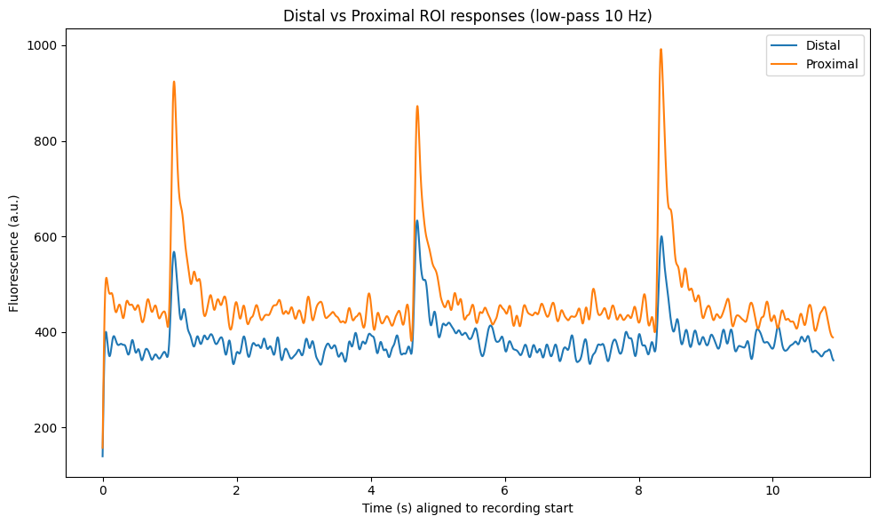

```python
import matplotlib.pyplot as plt
import numpy as np
from scipy.signal import butter, filtfilt

ophys_module = nwbfile.processing['ophys']
fluoresence_module = ophys_module.data_interfaces["Fluorescence"]

# In the published dataset ROI responses are consolidated per cell per location
# (not split by trial). Each series spans all trials concatenated.
distal_roi  = fluoresence_module["RoiResponseSeriesFluo4Cell3Distal1"]
proximal_roi = fluoresence_module["RoiResponseSeriesFluo4Cell3Proximal1"]

color_distal, color_proximal = "tab:blue", "tab:orange"

plt.figure(figsize=(10, 6))

for roi_response, color, label in [
    (distal_roi,   color_distal,   "Distal"),
    (proximal_roi, color_proximal, "Proximal"),
]:
    num_samples = roi_response.data.shape[0]
    sampling_rate = roi_response.rate
    aligned_timestamps = np.arange(num_samples) / sampling_rate
    b, a = butter(4, 10 / (0.5 * sampling_rate), btype="low")
    filtered_response = filtfilt(b, a, roi_response.data[:])
    plt.plot(aligned_timestamps, filtered_response, color=color, label=label)

plt.xlabel("Time (s) aligned to recording start")
plt.ylabel("Fluorescence (a.u.)")
plt.title("Distal vs Proximal ROI responses (low-pass 10 Hz)")
plt.legend()
plt.tight_layout()
plt.show()
```

### Line Scans and Fluoresence

### Comprehensive Line Scan Visualization: Linking Images, Raw Data, and ROI Responses

This section demonstrates how to access and visualize the complete line scan data workflow in NWB:

1. **Source Images** (`GrayscaleImage` objects): Anatomical reference showing where line scans were performed
2. **Line Scan Raw Data** (`TimeSeries` objects): Raw fluorescence measurements over time and space
3. **ROI Responses** (`RoiResponseSeries` objects): Processed fluorescence time series extracted from specific regions and are linked to them directly.

This demonstrates how NWB maintains the complete data provenance chain from raw measurements to processed analysis results.

```
Extracted line scan coordinates:
  X range: 88 to 106
  Y range: 73 to 73
  Number of pixels: 19
Line scan data shape: (7500, 19)
ROI response shape: (7500,)
```

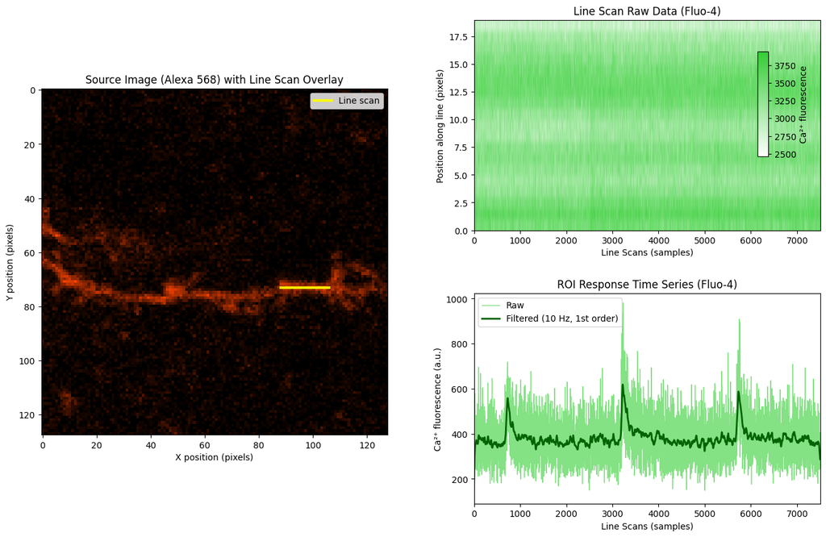

```python
import matplotlib.colors as mcolors
import matplotlib.pyplot as plt
import numpy as np
from mpl_toolkits.axes_grid1.inset_locator import inset_axes
from scipy.signal import butter, filtfilt

# Actual key names in the published dataset:
#   Line scan raw:  LineScanCell3_{Distal1|Proximal1}_Ch{1|2}
#   Source images:  ImageLineScanSource["Image{Alexa568|Fluo4}Cell3{Distal1|Proximal1}Trial{001..003}"]
#   ROI responses:  RoiResponseSeries{Fluo4|Alexa568}Cell3{Distal1|Proximal1}
line_scan_raw_data_name  = "LineScanCell3_Distal1_Ch1"
source_image_name        = "ImageAlexa568Cell3Distal1Trial001"
roi_response_series_name = "RoiResponseSeriesFluo4Cell3Distal1"

line_scan_data = nwbfile.acquisition[line_scan_raw_data_name]
source_images_container = nwbfile.acquisition['ImageLineScanSource']
source_image = source_images_container[source_image_name]
roi_response = fluoresence_module[roi_response_series_name]

# Get line scan coordinates from the ROI response series
pixel_mask = roi_response.rois[0]["pixel_mask"].iloc[0]

print(f"Extracted line scan coordinates:")
print(f"  X range: {pixel_mask['x'].min()} to {pixel_mask['x'].max()}")
print(f"  Y range: {pixel_mask['y'].min()} to {pixel_mask['y'].max()}")
print(f"  Number of pixels: {len(pixel_mask['x'])}")

alexa568_color = '#FF4500'
fluo4_color = '#32CD32'

alexa568_cmap = mcolors.LinearSegmentedColormap.from_list("alexa568", ["black", alexa568_color], N=256)
fluo4_cmap    = mcolors.LinearSegmentedColormap.from_list("fluo4",    ["white", fluo4_color],    N=256)

line_scan_raw_data = line_scan_data.data[:]
num_samples = line_scan_raw_data.shape[0]
num_pixels  = line_scan_raw_data.shape[1]
print(f"Line scan data shape: {line_scan_raw_data.shape}")

roi_response_data = roi_response.data[:]
roi_sampling_rate = roi_response.rate
print(f"ROI response shape: {roi_response_data.shape}")

cutoff_freq = 10
b_roi, a_roi = butter(1, cutoff_freq / (0.5 * roi_sampling_rate), btype="low")
roi_response_filtered = filtfilt(b_roi, a_roi, roi_response_data)

fig = plt.figure(figsize=(16, 10))
gs  = fig.add_gridspec(nrows=2, ncols=2, hspace=0.3, wspace=0.25)

ax_src = fig.add_subplot(gs[:, 0])
ax_src.imshow(source_image, cmap=alexa568_cmap, aspect="equal", origin="upper")
ax_src.set_title("Source Image (Alexa 568) with Line Scan Overlay")
ax_src.set_xlabel("X position (pixels)")
ax_src.set_ylabel("Y position (pixels)")
ax_src.plot(pixel_mask["x"], pixel_mask["y"], "yellow", linewidth=3, alpha=0.9, label="Line scan")
ax_src.legend(loc="best")

ax_raw = fig.add_subplot(gs[0, 1])
vmin = np.percentile(line_scan_raw_data, 2)
vmax = np.percentile(line_scan_raw_data, 98)
im_raw = ax_raw.imshow(
    line_scan_raw_data.T, aspect="auto", cmap=fluo4_cmap, origin="lower",
    extent=[0, num_samples, 0, num_pixels],
    vmin=vmin, vmax=vmax,
)
ax_raw.set_title("Line Scan Raw Data (Fluo-4)")
ax_raw.set_xlabel("Line Scans (samples)")
ax_raw.set_ylabel("Position along line (pixels)")
ax_raw.set_xlim(0, num_samples)

cax_raw = inset_axes(ax_raw, width="3%", height="50%", loc="upper right",
                     bbox_to_anchor=(-0.15, -0.15, 1, 1),
                     bbox_transform=ax_raw.transAxes, borderpad=0)
fig.colorbar(im_raw, cax=cax_raw, label="Ca²⁺ fluorescence")

ax_roi = fig.add_subplot(gs[1, 1])
ax_roi.plot(roi_response_data, color=fluo4_color, linewidth=1, alpha=0.6, label="Raw")
ax_roi.plot(roi_response_filtered, color='darkgreen', linewidth=2,
            label=f"Filtered ({cutoff_freq} Hz, 1st order)")
ax_roi.set_title("ROI Response Time Series (Fluo-4)")
ax_roi.set_xlabel("Line Scans (samples)")
ax_roi.set_ylabel("Ca²⁺ fluorescence (a.u.)")
ax_roi.legend()
ax_roi.set_xlim(0, num_samples)

plt.tight_layout()
plt.show()
```

## Optogenetic Experiments - oEPSC Analysis

### NWB Organization for Optogenetic Data

Optogenetic experiments combine voltage clamp electrophysiology with optical stimulation to study synaptic responses. These experiments measure optogenetically-evoked postsynaptic currents (oEPSCs) in striatal neurons following ChR2-mediated activation of cortical terminals.

**Data stored in `acquisition` module:**

- **VoltageClampSeries**: Raw current recordings from voltage clamp experiments
- **OptogeneticSeries**: Optical stimulation parameters and timing (stored in `stimulus` module)

**Data stored in `intervals` module:**

- **optogenetic_epochs_table**: Detailed timing information for stimulation and detection windows
- **Stage definitions**: pre_stimulation, stimulation, detection, post_detection, inter_sweep_interval

### Filtering for Optogenetic Data from Figure 2

We use the same filtering approach to identify optogenetic experiments (oEPSC measurements) from Figure 2. These files contain voltage clamp recordings with optical stimulation protocols.

```python
# Filter for optogenetic oEPSC experiments (Figure 2G-H equivalent).
# These use combined icephys + optogenetics modality with dSPN cell type.

def is_dspn_oepsc(asset_path: str) -> bool:
    """dSPN optogenetic oEPSC files."""
    return get_modality(asset_path) == 'icephys+ogen' and get_cell_type(get_session_id(asset_path)) == 'dSPN'

available_oepsc_assets = [asset for asset in assets_list if is_dspn_oepsc(asset.path)]

print(f"Found {len(available_oepsc_assets)} dSPN oEPSC files:")
for i, asset in enumerate(available_oepsc_assets[:3]):
    session_id = get_session_id(asset.path)
    fields = parse_session_id(session_id)
    print(f"  {i+1}. {asset.path}")
    print(f"     Session:   {session_id}")
    print(f"     Cell type: {fields.get('cell_type')}")
    print(f"     State:     {fields.get('state')}")
    print(f"     Genotype:  {fields.get('genotype')}")
    print()
```

```
Found 7 dSPN oEPSC files:
  1. sub-dSPN-mouse-dSPN++OffState++none++WT++20230706/sub-dSPN-mouse-dSPN++OffState++none++WT++20230706_ses-dSPN++OffState++none++WT++20230706_icephys+ogen.nwb
     Session:   dSPN++OffState++none++WT++20230706
     Cell type: dSPN
     State:     OffState
     Genotype:  WT

  2. sub-dSPN-mouse-dSPN++OffState++none++WT++20230713/sub-dSPN-mouse-dSPN++OffState++none++WT++20230713_ses-dSPN++OffState++none++WT++20230713_icephys+ogen.nwb
     Session:   dSPN++OffState++none++WT++20230713
     Cell type: dSPN
     State:     OffState
     Genotype:  WT

  3. sub-dSPN-mouse-dSPN++OffState++none++WT++20230817/sub-dSPN-mouse-dSPN++OffState++none++WT++20230817_ses-dSPN++OffState++none++WT++20230817_icephys+ogen.nwb
     Session:   dSPN++OffState++none++WT++20230817
     Cell type: dSPN
     State:     OffState
     Genotype:  WT
```

### Streaming an NWB file with Optogenetic stimulation

Let's stream one optogenetic file to explore the voltage clamp data organization and optogenetic stimulation protocols.

```python
import h5py
import remfile
from pynwb import NWBHDF5IO

asset = available_oepsc_assets[0]
s3_url = asset.get_content_url(follow_redirects=1, strip_query=False)
file_system = remfile.File(s3_url, disk_cache=remfile.DiskCache("nwb-cache"))
file = h5py.File(file_system, mode="r")

io = NWBHDF5IO(file=file)
nwbfile = io.read()
nwbfile
```

root (NWBFile)

session_description: "Sr²⁺-oEPSC recordings from dSPNs in dorsolateral striatum under LID off-state condition. Voltage clamp at -70 mV in Ca²⁺-free ACSF containing 3 mM SrCl₂ and 10 μM gabazine. Optogenetic stimulation of ChR2-expressing corticostriatal terminals with 0.3 ms blue LED pulses every 30 seconds. Session c, 10 sweeps."

identifier: 83b862b5-f2ec-4319-b8fc-abd9e19638f4

**session_start_time**

2023-07-06 16:55:01.743545-05:00

**timestamps_reference_time**

2023-07-06 16:55:01.743545-05:00

**file_create_date**

**0**

2026-05-22 10:10:50.862650-06:00

**experimenter**

('Zhai, Shenyu', 'Cui, Qiaoling', 'Wokosin, David', 'Sun, Linqing', 'Tkatch, Tatiana', 'Crittenden, Jill R.', 'Graybiel, Ann M.', 'Surmeier, D. James')

**icephys_electrodes**

**IntracellularElectrode (IntracellularElectrode)**

slice: Sagittal slices (280-μm thick) were sectioned using a vibratome (Leica VT1200). After cutting, slices were incubated at 34 °C for 30 min in ACSF containing (in mM): 124 NaCl, 3 KCl, 1 NaH2PO4, 2.0 CaCl2, 1.0 MgCl2, 26 NaHCO3 and 13.89 glucose, after which they were stored at room temperature until recording. External solutions were oxygenated with carbogen (95%CO2/5%O2) at all time.

description: Whole-cell patch clamp electrode recording from dSPN in the dorsolateral striatum - LID off-state - Session c - Sr²⁺-oEPSC protocol with LED 100b intensity

location: Caudoputamen

**device (Device)**

description: Prairie View intracellular recording device: Multiclamp700B Ch1

cell_id: Cell3

**related_publications**

('https://doi.org/10.1101/2025.01.02.631090',)

**acquisition**

**VoltageClampSeriesSweep001 (VoltageClampSeries)**

starting_time: 0.0

rate: 20000.0

resolution: -1.0

comments: no comments

description: Voltage clamp recording from dSPN - LID off-state - Session c, Cell 3 - LED intensity 100b, Sweep 001 - Sr²⁺-oEPSC protocol at -70 mV holding potential

conversion: 1.0

offset: 0.0

unit: amperes

**data**

HDF5 dataset

| Data type | float64 |
| --- | --- |
| Shape | (20001,) |
| Array size | 156.26 KiB |
| Chunk shape | (20001,) |
| Compression | gzip |
| Compression opts | 4 |
| Uncompressed size (bytes) | 160008 |
| Compressed size (bytes) | 32586 |
| Compression ratio | 4.910329589394219 |

starting_time_unit: seconds

**electrode (IntracellularElectrode)**

slice: Sagittal slices (280-μm thick) were sectioned using a vibratome (Leica VT1200). After cutting, slices were incubated at 34 °C for 30 min in ACSF containing (in mM): 124 NaCl, 3 KCl, 1 NaH2PO4, 2.0 CaCl2, 1.0 MgCl2, 26 NaHCO3 and 13.89 glucose, after which they were stored at room temperature until recording. External solutions were oxygenated with carbogen (95%CO2/5%O2) at all time.

description: Whole-cell patch clamp electrode recording from dSPN in the dorsolateral striatum - LID off-state - Session c - Sr²⁺-oEPSC protocol with LED 100b intensity

location: Caudoputamen

**device (Device)**

description: Prairie View intracellular recording device: Multiclamp700B Ch1

cell_id: Cell3

stimulus_description: N/A

**VoltageClampSeriesSweep002 (VoltageClampSeries)**

starting_time: 14.868482

rate: 20000.000000046613

resolution: -1.0

comments: no comments

description: Voltage clamp recording from dSPN - LID off-state - Session c, Cell 3 - LED intensity 100b, Sweep 002 - Sr²⁺-oEPSC protocol at -70 mV holding potential

conversion: 1.0

offset: 0.0

unit: amperes

**data**

HDF5 dataset

| Data type | float64 |
| --- | --- |
| Shape | (20001,) |
| Array size | 156.26 KiB |
| Chunk shape | (20001,) |
| Compression | gzip |
| Compression opts | 4 |
| Uncompressed size (bytes) | 160008 |
| Compressed size (bytes) | 32879 |
| Compression ratio | 4.866571367742328 |

starting_time_unit: seconds

**electrode (IntracellularElectrode)**

slice: Sagittal slices (280-μm thick) were sectioned using a vibratome (Leica VT1200). After cutting, slices were incubated at 34 °C for 30 min in ACSF containing (in mM): 124 NaCl, 3 KCl, 1 NaH2PO4, 2.0 CaCl2, 1.0 MgCl2, 26 NaHCO3 and 13.89 glucose, after which they were stored at room temperature until recording. External solutions were oxygenated with carbogen (95%CO2/5%O2) at all time.

description: Whole-cell patch clamp electrode recording from dSPN in the dorsolateral striatum - LID off-state - Session c - Sr²⁺-oEPSC protocol with LED 100b intensity

location: Caudoputamen

**device (Device)**

description: Prairie View intracellular recording device: Multiclamp700B Ch1

cell_id: Cell3

stimulus_description: N/A

**VoltageClampSeriesSweep003 (VoltageClampSeries)**

starting_time: 28.686085

rate: 19999.99999933607

resolution: -1.0

comments: no comments

description: Voltage clamp recording from dSPN - LID off-state - Session c, Cell 3 - LED intensity 100b, Sweep 003 - Sr²⁺-oEPSC protocol at -70 mV holding potential

conversion: 1.0

offset: 0.0

unit: amperes

**data**

HDF5 dataset

| Data type | float64 |
| --- | --- |
| Shape | (20001,) |
| Array size | 156.26 KiB |
| Chunk shape | (20001,) |
| Compression | gzip |
| Compression opts | 4 |
| Uncompressed size (bytes) | 160008 |
| Compressed size (bytes) | 34511 |
| Compression ratio | 4.636434759931616 |

starting_time_unit: seconds

**electrode (IntracellularElectrode)**

slice: Sagittal slices (280-μm thick) were sectioned using a vibratome (Leica VT1200). After cutting, slices were incubated at 34 °C for 30 min in ACSF containing (in mM): 124 NaCl, 3 KCl, 1 NaH2PO4, 2.0 CaCl2, 1.0 MgCl2, 26 NaHCO3 and 13.89 glucose, after which they were stored at room temperature until recording. External solutions were oxygenated with carbogen (95%CO2/5%O2) at all time.

description: Whole-cell patch clamp electrode recording from dSPN in the dorsolateral striatum - LID off-state - Session c - Sr²⁺-oEPSC protocol with LED 100b intensity

location: Caudoputamen

**device (Device)**

description: Prairie View intracellular recording device: Multiclamp700B Ch1

cell_id: Cell3

stimulus_description: N/A

**VoltageClampSeriesSweep004 (VoltageClampSeries)**

starting_time: 57.157828

rate: 19999.99999933607

resolution: -1.0

comments: no comments

description: Voltage clamp recording from dSPN - LID off-state - Session c, Cell 3 - LED intensity 100b, Sweep 004 - Sr²⁺-oEPSC protocol at -70 mV holding potential

conversion: 1.0

offset: 0.0

unit: amperes

**data**

HDF5 dataset

| Data type | float64 |
| --- | --- |
| Shape | (20001,) |
| Array size | 156.26 KiB |
| Chunk shape | (20001,) |
| Compression | gzip |
| Compression opts | 4 |
| Uncompressed size (bytes) | 160008 |
| Compressed size (bytes) | 34561 |
| Compression ratio | 4.629727149098695 |

starting_time_unit: seconds

**electrode (IntracellularElectrode)**

slice: Sagittal slices (280-μm thick) were sectioned using a vibratome (Leica VT1200). After cutting, slices were incubated at 34 °C for 30 min in ACSF containing (in mM): 124 NaCl, 3 KCl, 1 NaH2PO4, 2.0 CaCl2, 1.0 MgCl2, 26 NaHCO3 and 13.89 glucose, after which they were stored at room temperature until recording. External solutions were oxygenated with carbogen (95%CO2/5%O2) at all time.

description: Whole-cell patch clamp electrode recording from dSPN in the dorsolateral striatum - LID off-state - Session c - Sr²⁺-oEPSC protocol with LED 100b intensity

location: Caudoputamen

**device (Device)**

description: Prairie View intracellular recording device: Multiclamp700B Ch1

cell_id: Cell3

stimulus_description: N/A

**VoltageClampSeriesSweep005 (VoltageClampSeries)**

starting_time: 87.16555

rate: 19999.99999933607

resolution: -1.0

comments: no comments

description: Voltage clamp recording from dSPN - LID off-state - Session c, Cell 3 - LED intensity 100b, Sweep 005 - Sr²⁺-oEPSC protocol at -70 mV holding potential

conversion: 1.0

offset: 0.0

unit: amperes

**data**

HDF5 dataset

| Data type | float64 |
| --- | --- |
| Shape | (20001,) |
| Array size | 156.26 KiB |
| Chunk shape | (20001,) |
| Compression | gzip |
| Compression opts | 4 |
| Uncompressed size (bytes) | 160008 |
| Compressed size (bytes) | 32681 |
| Compression ratio | 4.896055812245647 |

starting_time_unit: seconds

**electrode (IntracellularElectrode)**

slice: Sagittal slices (280-μm thick) were sectioned using a vibratome (Leica VT1200). After cutting, slices were incubated at 34 °C for 30 min in ACSF containing (in mM): 124 NaCl, 3 KCl, 1 NaH2PO4, 2.0 CaCl2, 1.0 MgCl2, 26 NaHCO3 and 13.89 glucose, after which they were stored at room temperature until recording. External solutions were oxygenated with carbogen (95%CO2/5%O2) at all time.

description: Whole-cell patch clamp electrode recording from dSPN in the dorsolateral striatum - LID off-state - Session c - Sr²⁺-oEPSC protocol with LED 100b intensity

location: Caudoputamen

**device (Device)**

description: Prairie View intracellular recording device: Multiclamp700B Ch1

cell_id: Cell3

stimulus_description: N/A

**VoltageClampSeriesSweep006 (VoltageClampSeries)**

starting_time: 117.158468

rate: 19999.99999933607

resolution: -1.0

comments: no comments

description: Voltage clamp recording from dSPN - LID off-state - Session c, Cell 3 - LED intensity 100b, Sweep 006 - Sr²⁺-oEPSC protocol at -70 mV holding potential

conversion: 1.0

offset: 0.0

unit: amperes

**data**

HDF5 dataset

| Data type | float64 |
| --- | --- |
| Shape | (20001,) |
| Array size | 156.26 KiB |
| Chunk shape | (20001,) |
| Compression | gzip |
| Compression opts | 4 |
| Uncompressed size (bytes) | 160008 |
| Compressed size (bytes) | 32603 |
| Compression ratio | 4.907769223691071 |

starting_time_unit: seconds

**electrode (IntracellularElectrode)**

slice: Sagittal slices (280-μm thick) were sectioned using a vibratome (Leica VT1200). After cutting, slices were incubated at 34 °C for 30 min in ACSF containing (in mM): 124 NaCl, 3 KCl, 1 NaH2PO4, 2.0 CaCl2, 1.0 MgCl2, 26 NaHCO3 and 13.89 glucose, after which they were stored at room temperature until recording. External solutions were oxygenated with carbogen (95%CO2/5%O2) at all time.

description: Whole-cell patch clamp electrode recording from dSPN in the dorsolateral striatum - LID off-state - Session c - Sr²⁺-oEPSC protocol with LED 100b intensity

location: Caudoputamen

**device (Device)**

description: Prairie View intracellular recording device: Multiclamp700B Ch1

cell_id: Cell3

stimulus_description: N/A

**VoltageClampSeriesSweep007 (VoltageClampSeries)**

starting_time: 147.165624

rate: 20000.00000502041

resolution: -1.0

comments: no comments

description: Voltage clamp recording from dSPN - LID off-state - Session c, Cell 3 - LED intensity 100b, Sweep 007 - Sr²⁺-oEPSC protocol at -70 mV holding potential

conversion: 1.0

offset: 0.0

unit: amperes

**data**

HDF5 dataset

| Data type | float64 |
| --- | --- |
| Shape | (20001,) |
| Array size | 156.26 KiB |
| Chunk shape | (20001,) |
| Compression | gzip |
| Compression opts | 4 |
| Uncompressed size (bytes) | 160008 |
| Compressed size (bytes) | 33846 |
| Compression ratio | 4.727530579684453 |

starting_time_unit: seconds

**electrode (IntracellularElectrode)**

slice: Sagittal slices (280-μm thick) were sectioned using a vibratome (Leica VT1200). After cutting, slices were incubated at 34 °C for 30 min in ACSF containing (in mM): 124 NaCl, 3 KCl, 1 NaH2PO4, 2.0 CaCl2, 1.0 MgCl2, 26 NaHCO3 and 13.89 glucose, after which they were stored at room temperature until recording. External solutions were oxygenated with carbogen (95%CO2/5%O2) at all time.

description: Whole-cell patch clamp electrode recording from dSPN in the dorsolateral striatum - LID off-state - Session c - Sr²⁺-oEPSC protocol with LED 100b intensity

location: Caudoputamen

**device (Device)**

description: Prairie View intracellular recording device: Multiclamp700B Ch1

cell_id: Cell3

stimulus_description: N/A

**VoltageClampSeriesSweep008 (VoltageClampSeries)**

starting_time: 177.15604

rate: 20000.00000502041

resolution: -1.0

comments: no comments

description: Voltage clamp recording from dSPN - LID off-state - Session c, Cell 3 - LED intensity 100b, Sweep 008 - Sr²⁺-oEPSC protocol at -70 mV holding potential

conversion: 1.0

offset: 0.0

unit: amperes

**data**

HDF5 dataset

| Data type | float64 |
| --- | --- |
| Shape | (20001,) |
| Array size | 156.26 KiB |
| Chunk shape | (20001,) |
| Compression | gzip |
| Compression opts | 4 |
| Uncompressed size (bytes) | 160008 |
| Compressed size (bytes) | 35300 |
| Compression ratio | 4.532804532577904 |

starting_time_unit: seconds

**electrode (IntracellularElectrode)**

slice: Sagittal slices (280-μm thick) were sectioned using a vibratome (Leica VT1200). After cutting, slices were incubated at 34 °C for 30 min in ACSF containing (in mM): 124 NaCl, 3 KCl, 1 NaH2PO4, 2.0 CaCl2, 1.0 MgCl2, 26 NaHCO3 and 13.89 glucose, after which they were stored at room temperature until recording. External solutions were oxygenated with carbogen (95%CO2/5%O2) at all time.

description: Whole-cell patch clamp electrode recording from dSPN in the dorsolateral striatum - LID off-state - Session c - Sr²⁺-oEPSC protocol with LED 100b intensity

location: Caudoputamen

**device (Device)**

description: Prairie View intracellular recording device: Multiclamp700B Ch1

cell_id: Cell3

stimulus_description: N/A

**VoltageClampSeriesSweep009 (VoltageClampSeries)**

starting_time: 207.153608

rate: 20000.00000502041

resolution: -1.0

comments: no comments

description: Voltage clamp recording from dSPN - LID off-state - Session c, Cell 3 - LED intensity 100b, Sweep 009 - Sr²⁺-oEPSC protocol at -70 mV holding potential

conversion: 1.0

offset: 0.0

unit: amperes

**data**

HDF5 dataset

| Data type | float64 |
| --- | --- |
| Shape | (20001,) |
| Array size | 156.26 KiB |
| Chunk shape | (20001,) |
| Compression | gzip |
| Compression opts | 4 |
| Uncompressed size (bytes) | 160008 |
| Compressed size (bytes) | 34854 |
| Compression ratio | 4.5908073678774315 |

starting_time_unit: seconds

**electrode (IntracellularElectrode)**

slice: Sagittal slices (280-μm thick) were sectioned using a vibratome (Leica VT1200). After cutting, slices were incubated at 34 °C for 30 min in ACSF containing (in mM): 124 NaCl, 3 KCl, 1 NaH2PO4, 2.0 CaCl2, 1.0 MgCl2, 26 NaHCO3 and 13.89 glucose, after which they were stored at room temperature until recording. External solutions were oxygenated with carbogen (95%CO2/5%O2) at all time.

description: Whole-cell patch clamp electrode recording from dSPN in the dorsolateral striatum - LID off-state - Session c - Sr²⁺-oEPSC protocol with LED 100b intensity

location: Caudoputamen

**device (Device)**

description: Prairie View intracellular recording device: Multiclamp700B Ch1

cell_id: Cell3

stimulus_description: N/A

**VoltageClampSeriesSweep010 (VoltageClampSeries)**

starting_time: 237.157181

rate: 20000.00000502041

resolution: -1.0

comments: no comments

description: Voltage clamp recording from dSPN - LID off-state - Session c, Cell 3 - LED intensity 100b, Sweep 010 - Sr²⁺-oEPSC protocol at -70 mV holding potential

conversion: 1.0

offset: 0.0

unit: amperes

**data**

HDF5 dataset

| Data type | float64 |
| --- | --- |
| Shape | (20001,) |
| Array size | 156.26 KiB |
| Chunk shape | (20001,) |
| Compression | gzip |
| Compression opts | 4 |
| Uncompressed size (bytes) | 160008 |
| Compressed size (bytes) | 35070 |
| Compression ratio | 4.562532078699744 |

starting_time_unit: seconds

**electrode (IntracellularElectrode)**

slice: Sagittal slices (280-μm thick) were sectioned using a vibratome (Leica VT1200). After cutting, slices were incubated at 34 °C for 30 min in ACSF containing (in mM): 124 NaCl, 3 KCl, 1 NaH2PO4, 2.0 CaCl2, 1.0 MgCl2, 26 NaHCO3 and 13.89 glucose, after which they were stored at room temperature until recording. External solutions were oxygenated with carbogen (95%CO2/5%O2) at all time.

description: Whole-cell patch clamp electrode recording from dSPN in the dorsolateral striatum - LID off-state - Session c - Sr²⁺-oEPSC protocol with LED 100b intensity

location: Caudoputamen

**device (Device)**

description: Prairie View intracellular recording device: Multiclamp700B Ch1

cell_id: Cell3

stimulus_description: N/A

**stimulus**

**OptogeneticSeriesSweep001 (OptogeneticSeries)**

starting_time: 0.0

rate: 1000.0

resolution: -1.0

comments: no comments

description: LED stimulation trace - 0.3ms pulse during voltage clamp sweep

conversion: 1.0

offset: 0.0

unit: watts

**data**

HDF5 dataset

| Data type | float64 |
| --- | --- |
| Shape | (1000,) |
| Array size | 7.81 KiB |
| Chunk shape | (1000,) |
| Compression | gzip |
| Compression opts | 4 |
| Uncompressed size (bytes) | 8000 |
| Compressed size (bytes) | 28 |
| Compression ratio | 285.7142857142857 |

starting_time_unit: seconds

**site (OptogeneticStimulusSite)**

**device (Device)**

description: Blue LED (470 nm) for whole-field optogenetic stimulation controlled via Prairie View. Drives 5V pulses to activate ChR2-expressing corticostriatal terminals.

description: Optogenetic stimulation site in dorsal striatum targeting ChR2-expressing corticostriatal terminals. ChR2 expression from motor cortex injection ipsilateral to 6-OHDA lesion. LED illumination activates projections to evoke Sr2+-oEPSCs in recorded dSPNs.

excitation_lambda: 470.0

location: dorsal striatum (ipsilateral to 6-OHDA lesion)

**OptogeneticSeriesSweep002 (OptogeneticSeries)**

starting_time: 14.868482

rate: 1000.0

resolution: -1.0

comments: no comments

description: LED stimulation trace - 0.3ms pulse during voltage clamp sweep

conversion: 1.0

offset: 0.0

unit: watts

**data**

HDF5 dataset

| Data type | float64 |
| --- | --- |
| Shape | (999,) |
| Array size | 7.80 KiB |
| Chunk shape | (999,) |
| Compression | gzip |
| Compression opts | 4 |
| Uncompressed size (bytes) | 7992 |
| Compressed size (bytes) | 39 |
| Compression ratio | 204.92307692307693 |

starting_time_unit: seconds

**site (OptogeneticStimulusSite)**

**device (Device)**

description: Blue LED (470 nm) for whole-field optogenetic stimulation controlled via Prairie View. Drives 5V pulses to activate ChR2-expressing corticostriatal terminals.

description: Optogenetic stimulation site in dorsal striatum targeting ChR2-expressing corticostriatal terminals. ChR2 expression from motor cortex injection ipsilateral to 6-OHDA lesion. LED illumination activates projections to evoke Sr2+-oEPSCs in recorded dSPNs.

excitation_lambda: 470.0

location: dorsal striatum (ipsilateral to 6-OHDA lesion)

**OptogeneticSeriesSweep003 (OptogeneticSeries)**

starting_time: 28.686085

rate: 1000.0

resolution: -1.0

comments: no comments

description: LED stimulation trace - 0.3ms pulse during voltage clamp sweep

conversion: 1.0

offset: 0.0

unit: watts

**data**

HDF5 dataset

| Data type | float64 |
| --- | --- |
| Shape | (1000,) |
| Array size | 7.81 KiB |
| Chunk shape | (1000,) |
| Compression | gzip |
| Compression opts | 4 |
| Uncompressed size (bytes) | 8000 |
| Compressed size (bytes) | 40 |
| Compression ratio | 200.0 |

starting_time_unit: seconds

**site (OptogeneticStimulusSite)**

**device (Device)**

description: Blue LED (470 nm) for whole-field optogenetic stimulation controlled via Prairie View. Drives 5V pulses to activate ChR2-expressing corticostriatal terminals.

description: Optogenetic stimulation site in dorsal striatum targeting ChR2-expressing corticostriatal terminals. ChR2 expression from motor cortex injection ipsilateral to 6-OHDA lesion. LED illumination activates projections to evoke Sr2+-oEPSCs in recorded dSPNs.

excitation_lambda: 470.0

location: dorsal striatum (ipsilateral to 6-OHDA lesion)

**OptogeneticSeriesSweep004 (OptogeneticSeries)**

starting_time: 57.157828

rate: 1000.0

resolution: -1.0

comments: no comments

description: LED stimulation trace - 0.3ms pulse during voltage clamp sweep

conversion: 1.0

offset: 0.0

unit: watts

**data**

HDF5 dataset

| Data type | float64 |
| --- | --- |
| Shape | (1000,) |
| Array size | 7.81 KiB |
| Chunk shape | (1000,) |
| Compression | gzip |
| Compression opts | 4 |
| Uncompressed size (bytes) | 8000 |
| Compressed size (bytes) | 28 |
| Compression ratio | 285.7142857142857 |

starting_time_unit: seconds

**site (OptogeneticStimulusSite)**

**device (Device)**

description: Blue LED (470 nm) for whole-field optogenetic stimulation controlled via Prairie View. Drives 5V pulses to activate ChR2-expressing corticostriatal terminals.

description: Optogenetic stimulation site in dorsal striatum targeting ChR2-expressing corticostriatal terminals. ChR2 expression from motor cortex injection ipsilateral to 6-OHDA lesion. LED illumination activates projections to evoke Sr2+-oEPSCs in recorded dSPNs.

excitation_lambda: 470.0

location: dorsal striatum (ipsilateral to 6-OHDA lesion)

**OptogeneticSeriesSweep005 (OptogeneticSeries)**

starting_time: 87.16555

rate: 1000.0

resolution: -1.0

comments: no comments

description: LED stimulation trace - 0.3ms pulse during voltage clamp sweep

conversion: 1.0

offset: 0.0

unit: watts

**data**

HDF5 dataset

| Data type | float64 |
| --- | --- |
| Shape | (1000,) |
| Array size | 7.81 KiB |
| Chunk shape | (1000,) |
| Compression | gzip |
| Compression opts | 4 |
| Uncompressed size (bytes) | 8000 |
| Compressed size (bytes) | 40 |
| Compression ratio | 200.0 |

starting_time_unit: seconds

**site (OptogeneticStimulusSite)**

**device (Device)**

description: Blue LED (470 nm) for whole-field optogenetic stimulation controlled via Prairie View. Drives 5V pulses to activate ChR2-expressing corticostriatal terminals.

description: Optogenetic stimulation site in dorsal striatum targeting ChR2-expressing corticostriatal terminals. ChR2 expression from motor cortex injection ipsilateral to 6-OHDA lesion. LED illumination activates projections to evoke Sr2+-oEPSCs in recorded dSPNs.

excitation_lambda: 470.0

location: dorsal striatum (ipsilateral to 6-OHDA lesion)

**OptogeneticSeriesSweep006 (OptogeneticSeries)**

starting_time: 117.158468

rate: 1000.0

resolution: -1.0

comments: no comments

description: LED stimulation trace - 0.3ms pulse during voltage clamp sweep

conversion: 1.0

offset: 0.0

unit: watts

**data**

HDF5 dataset

| Data type | float64 |
| --- | --- |
| Shape | (1000,) |
| Array size | 7.81 KiB |
| Chunk shape | (1000,) |
| Compression | gzip |
| Compression opts | 4 |
| Uncompressed size (bytes) | 8000 |
| Compressed size (bytes) | 40 |
| Compression ratio | 200.0 |

starting_time_unit: seconds

**site (OptogeneticStimulusSite)**

**device (Device)**

description: Blue LED (470 nm) for whole-field optogenetic stimulation controlled via Prairie View. Drives 5V pulses to activate ChR2-expressing corticostriatal terminals.

description: Optogenetic stimulation site in dorsal striatum targeting ChR2-expressing corticostriatal terminals. ChR2 expression from motor cortex injection ipsilateral to 6-OHDA lesion. LED illumination activates projections to evoke Sr2+-oEPSCs in recorded dSPNs.

excitation_lambda: 470.0

location: dorsal striatum (ipsilateral to 6-OHDA lesion)

**OptogeneticSeriesSweep007 (OptogeneticSeries)**

starting_time: 147.165624

rate: 1000.0

resolution: -1.0

comments: no comments

description: LED stimulation trace - 0.3ms pulse during voltage clamp sweep

conversion: 1.0

offset: 0.0

unit: watts

**data**

HDF5 dataset

| Data type | float64 |
| --- | --- |
| Shape | (999,) |
| Array size | 7.80 KiB |
| Chunk shape | (999,) |
| Compression | gzip |
| Compression opts | 4 |
| Uncompressed size (bytes) | 7992 |
| Compressed size (bytes) | 30 |
| Compression ratio | 266.4 |

starting_time_unit: seconds

**site (OptogeneticStimulusSite)**

**device (Device)**

description: Blue LED (470 nm) for whole-field optogenetic stimulation controlled via Prairie View. Drives 5V pulses to activate ChR2-expressing corticostriatal terminals.

description: Optogenetic stimulation site in dorsal striatum targeting ChR2-expressing corticostriatal terminals. ChR2 expression from motor cortex injection ipsilateral to 6-OHDA lesion. LED illumination activates projections to evoke Sr2+-oEPSCs in recorded dSPNs.

excitation_lambda: 470.0

location: dorsal striatum (ipsilateral to 6-OHDA lesion)

**OptogeneticSeriesSweep008 (OptogeneticSeries)**

starting_time: 177.15604

rate: 1000.0

resolution: -1.0

comments: no comments

description: LED stimulation trace - 0.3ms pulse during voltage clamp sweep

conversion: 1.0

offset: 0.0

unit: watts

**data**

HDF5 dataset

| Data type | float64 |
| --- | --- |
| Shape | (999,) |
| Array size | 7.80 KiB |
| Chunk shape | (999,) |
| Compression | gzip |
| Compression opts | 4 |
| Uncompressed size (bytes) | 7992 |
| Compressed size (bytes) | 30 |
| Compression ratio | 266.4 |

starting_time_unit: seconds

**site (OptogeneticStimulusSite)**

**device (Device)**

description: Blue LED (470 nm) for whole-field optogenetic stimulation controlled via Prairie View. Drives 5V pulses to activate ChR2-expressing corticostriatal terminals.

description: Optogenetic stimulation site in dorsal striatum targeting ChR2-expressing corticostriatal terminals. ChR2 expression from motor cortex injection ipsilateral to 6-OHDA lesion. LED illumination activates projections to evoke Sr2+-oEPSCs in recorded dSPNs.

excitation_lambda: 470.0

location: dorsal striatum (ipsilateral to 6-OHDA lesion)

**OptogeneticSeriesSweep009 (OptogeneticSeries)**

starting_time: 207.153608

rate: 1000.0

resolution: -1.0

comments: no comments

description: LED stimulation trace - 0.3ms pulse during voltage clamp sweep

conversion: 1.0

offset: 0.0

unit: watts

**data**

HDF5 dataset

| Data type | float64 |
| --- | --- |
| Shape | (999,) |
| Array size | 7.80 KiB |
| Chunk shape | (999,) |
| Compression | gzip |
| Compression opts | 4 |
| Uncompressed size (bytes) | 7992 |
| Compressed size (bytes) | 30 |
| Compression ratio | 266.4 |

starting_time_unit: seconds

**site (OptogeneticStimulusSite)**

**device (Device)**

description: Blue LED (470 nm) for whole-field optogenetic stimulation controlled via Prairie View. Drives 5V pulses to activate ChR2-expressing corticostriatal terminals.

description: Optogenetic stimulation site in dorsal striatum targeting ChR2-expressing corticostriatal terminals. ChR2 expression from motor cortex injection ipsilateral to 6-OHDA lesion. LED illumination activates projections to evoke Sr2+-oEPSCs in recorded dSPNs.

excitation_lambda: 470.0

location: dorsal striatum (ipsilateral to 6-OHDA lesion)

**OptogeneticSeriesSweep010 (OptogeneticSeries)**

starting_time: 237.157181

rate: 1000.0

resolution: -1.0

comments: no comments

description: LED stimulation trace - 0.3ms pulse during voltage clamp sweep

conversion: 1.0

offset: 0.0

unit: watts

**data**

HDF5 dataset

| Data type | float64 |
| --- | --- |
| Shape | (999,) |
| Array size | 7.80 KiB |
| Chunk shape | (999,) |
| Compression | gzip |
| Compression opts | 4 |
| Uncompressed size (bytes) | 7992 |
| Compressed size (bytes) | 30 |
| Compression ratio | 266.4 |

starting_time_unit: seconds

**site (OptogeneticStimulusSite)**

**device (Device)**

description: Blue LED (470 nm) for whole-field optogenetic stimulation controlled via Prairie View. Drives 5V pulses to activate ChR2-expressing corticostriatal terminals.

description: Optogenetic stimulation site in dorsal striatum targeting ChR2-expressing corticostriatal terminals. ChR2 expression from motor cortex injection ipsilateral to 6-OHDA lesion. LED illumination activates projections to evoke Sr2+-oEPSCs in recorded dSPNs.

excitation_lambda: 470.0

location: dorsal striatum (ipsilateral to 6-OHDA lesion)

**keywords**

HDF5 dataset

| Data type | object |
| --- | --- |
| Shape | (19,) |
| Array size | 152.00 bytes |
| Chunk shape | None |
| Compression | None |
| Compression opts | None |
| Uncompressed size (bytes) | 152 |
| Compressed size (bytes) | 304 |
| Compression ratio | 0.5 |

**devices**

**BlueLED470nm (Device)**

description: Blue LED (470 nm) for whole-field optogenetic stimulation controlled via Prairie View. Drives 5V pulses to activate ChR2-expressing corticostriatal terminals.

**LED470nmSource (ExcitationSource)**

description: Blue LED excitation source for ChR2 activation. Wavelength (470 nm) specified per-epoch in OptogeneticEpochsTable.

**model (ExcitationSourceModel)**

manufacturer: Unknown

description: Blue LED model for 470nm optogenetic stimulation

source_type: LED

excitation_mode: one-photon

**wavelength_range_in_nm**

NumPy array

| Data type | float64 |
| --- | --- |
| Shape | (2,) |
| Array size | 16.00 bytes |

[455. 485.]

power_in_W: 0.001

exposure_time_in_s: 0.0003

**Multiclamp700B Ch1 (Device)**

description: Prairie View intracellular recording device: Multiclamp700B Ch1

**device_models**

**LED470nmModel (ExcitationSourceModel)**

manufacturer: Unknown

description: Blue LED model for 470nm optogenetic stimulation

source_type: LED

excitation_mode: one-photon

**wavelength_range_in_nm**

NumPy array

| Data type | float64 |
| --- | --- |
| Shape | (2,) |
| Array size | 16.00 bytes |

[455. 485.]

**ogen_sites**

**corticostriatal_terminals (OptogeneticStimulusSite)**

**device (Device)**

description: Blue LED (470 nm) for whole-field optogenetic stimulation controlled via Prairie View. Drives 5V pulses to activate ChR2-expressing corticostriatal terminals.

description: Optogenetic stimulation site in dorsal striatum targeting ChR2-expressing corticostriatal terminals. ChR2 expression from motor cortex injection ipsilateral to 6-OHDA lesion. LED illumination activates projections to evoke Sr2+-oEPSCs in recorded dSPNs.

excitation_lambda: 470.0

location: dorsal striatum (ipsilateral to 6-OHDA lesion)

**intervals**

**optogenetic_epochs_table (OptogeneticEpochsTable)**

description: Optogenetic stimulation epochs with detailed parameters

**columns**

**start_time**

Start time of epoch, in seconds

**stop_time**

Stop time of epoch, in seconds

**stimulation_on**

Whether optogenetic stimulation was used at any time during this epoch. If False, then all other metadata values should be 0.

**pulse_length_in_ms**

Duration of one pulse, in ms. Use NaN if stimulation was off.

**period_in_ms**

Duration between the starts of two pulses, in ms. Use NaN if stimulation was off. Note that the interpulse interval = `period_ms` - `pulse_length_ms`

**number_pulses_per_pulse_train**

Number of pulses in one pulse train. After this number of pulses, no more stimulation occurs until the next train begins (see `intertrain_interval_ms`). Use -1 if stimulation was off.

**number_trains**

Number of trains per stimulus. After this number of trains, no more stimulation occurs until stimulation is re-triggered. Use -1 if stimulation was off.

**intertrain_interval_in_ms**

Duration between the starts of two consecutive pulse trains, in ms. Determines the frequency of stimulation. Use NaN if stimulation was off.

**power_in_mW**

Constant power of excitation source throughout the epoch, in mW, e.g., 77 mW.

**wavelength_in_nm**

Wavelength of the excitation source, in nm, e.g., 488 nm.

**optogenetic_sites**

References row(s) of OptogeneticSitesTable.

**stage_name**

Name of the experimental stage: pre_stimulation, stimulation, detection, post_detection, or inter_sweep_interval

**table**

| id | start_time | stop_time | stimulation_on | pulse_length_in_ms | period_in_ms | number_pulses_per_pulse_train | number_trains | intertrain_interval_in_ms | power_in_mW | wavelength_in_nm | optogenetic_sites | stage_name |
| --- | --- | --- | --- | --- | --- | --- | --- | --- | --- | --- | --- | --- |
| 0 | 0.00 | 0.0200 | False | NaN | NaN | -1 | -1 | NaN | 0.0 | 470.0 | [0] | pre_stimulation |
| 1 | 0.02 | 0.0203 | True | 0.3 | NaN | 1 | 1 | NaN | NaN | 470.0 | [0] | stimulation |
| 2 | 0.06 | 0.4200 | False | NaN | NaN | -1 | -1 | NaN | 0.0 | 470.0 | [0] | detection |
| 3 | 0.42 | 1.0000 | False | NaN | NaN | -1 | -1 | NaN | 0.0 | 470.0 | [0] | post_detection |

... and 45 more row(s).

**subject (Subject)**

age: P7W/P12W

age__reference: birth

description: "Adult Drd1-Tdtomato transgenic mouse with unilateral 6-OHDA lesion (>95% dopamine depletion) modeling Parkinson's disease. Received dyskinesiogenic levodopa treatment and AAV5-hSyn-hChR2(H134R)-EYFP injection into motor cortex for optogenetic experiments. dSPNs identified by Drd1-Tdtomato expression. Session c."

genotype: Drd1-Tdtomato bacterial artificial chromosome (BAC) transgenic

sex: M

species: Mus musculus

subject_id: dSPN_mouse_dSPN++OffState++none++WT++20230706

strain: C57BL/6

**lab_meta_data**

**optogenetic_experiment_metadata (OptogeneticExperimentMetadata)**

stimulation_software: Prairie View

**optogenetic_sites_table (OptogeneticSitesTable)**

description: Stimulation sites for whole-field LED illumination of corticostriatal terminals.

**columns**

**effector**

The effector protein, e.g., ChR2.

**excitation_source**

The excitation source device connected to the optical fiber.

**table**

| id | effector | excitation_source |
| --- | --- | --- |
| 0 | ChR2_effector abc.Effector at 0x140138503251216\nFields:\n description: Excitatory channelrhodopsin expressed via AAV viral injection\n label: hChR2(H134R)-EYFP\n manufacturer: Addgene\n viral_vector_… | LED470nmSource abc.ExcitationSource at 0x140138503252560\nFields:\n description: Blue LED excitation source for ChR2 activation. Wavelength (470 nm) specified per-epoch in OptogeneticEpochsTable.\n ex… |

**optogenetic_viruses (OptogeneticViruses)**

**AAV5-hSyn-hChR2-H134R-EYFP (ViralVector)**

construct_name: AAV5-hSyn-hChR2(H134R)-EYFP

description: Adeno-associated virus serotype 5 expressing channelrhodopsin-2 (H134R variant) fused to enhanced yellow fluorescent protein under the human synapsin promoter. Used for optogenetic activation of corticostriatal terminals. Addgene #26973. Construct: AAV5-hSyn-hChR2(H134R)-EYFP from Addgene. Titer: 1e+13 vg/ml.

manufacturer: Addgene

titer_in_vg_per_ml: 10000000000000.0

**optogenetic_virus_injections (OptogeneticVirusInjections)**

**M1_cortex_injection (ViralVectorInjection)**

description: Stereotaxic injection of AAV5-hSyn-hChR2(H134R)-EYFP into M1 motor cortex ipsilateral to 6-OHDA lesion for corticostriatal terminal labeling. Coordinates: AP +1.15mm, ML -1.60mm, DV -1.55mm relative to Bregma. Volume: 0.15 µL. Expression time: 4 weeks. Coordinates: AP 1.15mm, ML -1.6mm, DV -1.55mm relative to Bregma at the cortical surface. Injection volume: 0.15µL.

location: Primary motor area

hemisphere: ipsilateral to 6-OHDA lesion

reference: Bregma at the cortical surface

ap_in_mm: 1.15

ml_in_mm: -1.6

dv_in_mm: -1.55

pitch_in_deg: 0.0

yaw_in_deg: 0.0

roll_in_deg: 0.0

volume_in_uL: 0.15

**viral_vector (ViralVector)**

construct_name: AAV5-hSyn-hChR2(H134R)-EYFP

description: Adeno-associated virus serotype 5 expressing channelrhodopsin-2 (H134R variant) fused to enhanced yellow fluorescent protein under the human synapsin promoter. Used for optogenetic activation of corticostriatal terminals. Addgene #26973. Construct: AAV5-hSyn-hChR2(H134R)-EYFP from Addgene. Titer: 1e+13 vg/ml.

manufacturer: Addgene

titer_in_vg_per_ml: 10000000000000.0

**optogenetic_effectors (OptogeneticEffectors)**

**ChR2_effector (Effector)**

label: hChR2(H134R)-EYFP

description: Excitatory channelrhodopsin expressed via AAV viral injection

manufacturer: Addgene

**viral_vector_injection (ViralVectorInjection)**

description: Stereotaxic injection of AAV5-hSyn-hChR2(H134R)-EYFP into M1 motor cortex ipsilateral to 6-OHDA lesion for corticostriatal terminal labeling. Coordinates: AP +1.15mm, ML -1.60mm, DV -1.55mm relative to Bregma. Volume: 0.15 µL. Expression time: 4 weeks. Coordinates: AP 1.15mm, ML -1.6mm, DV -1.55mm relative to Bregma at the cortical surface. Injection volume: 0.15µL.

location: Primary motor area

hemisphere: ipsilateral to 6-OHDA lesion

reference: Bregma at the cortical surface

ap_in_mm: 1.15

ml_in_mm: -1.6

dv_in_mm: -1.55

pitch_in_deg: 0.0

yaw_in_deg: 0.0

roll_in_deg: 0.0

volume_in_uL: 0.15

**viral_vector (ViralVector)**

construct_name: AAV5-hSyn-hChR2(H134R)-EYFP

description: Adeno-associated virus serotype 5 expressing channelrhodopsin-2 (H134R variant) fused to enhanced yellow fluorescent protein under the human synapsin promoter. Used for optogenetic activation of corticostriatal terminals. Addgene #26973. Construct: AAV5-hSyn-hChR2(H134R)-EYFP from Addgene. Titer: 1e+13 vg/ml.

manufacturer: Addgene

titer_in_vg_per_ml: 10000000000000.0

session_id: dSPN++OffState++none++WT++20230706

lab: Surmeier Lab

institution: Northwestern University

pharmacology: Induction anaesthesia with isoflurane (5 % v/v for induction, 2 % for maintenance). Pre-operative analgesia: meloxicam 0.1 mg kg⁻¹ s.c. Lesion: intracranial 6-hydroxydopamine, 1 µl of 3.5 mg ml⁻¹ free-base 6-OHDA in 0.02 % ascorbate-saline into the right medial forebrain bundle. L-DOPA priming for LID: five i.p. injections every other day—6 mg kg⁻¹ for the first two sessions, 12 mg kg⁻¹ thereafter—each co-administered with benserazide 12 mg kg⁻¹ to inhibit peripheral decarboxylation.

slices: Sagittal slices (280-μm thick) were sectioned using a vibratome (Leica VT1200). After cutting, slices were incubated at 34 °C for 30 min in ACSF containing (in mM): 124 NaCl, 3 KCl, 1 NaH2PO4, 2.0 CaCl2, 1.0 MgCl2, 26 NaHCO3 and 13.89 glucose, after which they were stored at room temperature until recording. External solutions were oxygenated with carbogen (95%CO2/5%O2) at all time.

source_script: Created using NeuroConv v0.9.4

source_script_file_name: /home/heberto/development/work_repos/neuroconv/src/neuroconv/tools/nwb_helpers/_metadata_and_file_helpers.py

surgery: Unilateral stereotaxic lesion: 1 µl of 6-hydroxydopamine (≈3 µg in 0.02 % ascorbate-saline) injected into the right medial forebrain bundle. Stereotaxic coordinates per the lab's 6-OHDA lesion protocol: AP -0.7 mm and ML -1.2 mm from bregma; DV -4.75 mm from the dura surface (NOT from bregma; the protocol specifies that the needle is zeroed at bregma for the AP and ML axes but at the dura surface for the DV axis, so AP and ML are referenced to skull landmarks while DV is referenced to the brain surface). Procedure performed under isoflurane anaesthesia; post-operative meloxicam, saline, and warming provided. Lesion efficacy later confirmed by drug-free forelimb-asymmetry (cylinder) test. AAV5-hSyn-hChR2(H134R)-EYFP injection into M1 motor cortex: 0.15 µL at coordinates AP +1.15mm, ML -1.60mm, DV -1.55mm relative to Bregma, 4 weeks expression time.

**intracellular_recordings (IntracellularRecordingsTable)**

description: A table to group together a stimulus and response from a single electrode and a single simultaneous recording and for storing metadata about the intracellular recording.

**category_tables**

**electrodes (IntracellularElectrodesTable)**

description: Table for storing intracellular electrode related metadata

**columns**

**electrode**

Column for storing the reference to the intracellular electrode

**table**

| id | electrode |
| --- | --- |
| 0 | IntracellularElectrode pynwb.icephys.IntracellularElectrode at 0x140138503907776\nFields:\n cell_id: Cell3\n description: Whole-cell patch clamp electrode recording from dSPN in the dorsolateral stria… |
| 1 | IntracellularElectrode pynwb.icephys.IntracellularElectrode at 0x140138503907776\nFields:\n cell_id: Cell3\n description: Whole-cell patch clamp electrode recording from dSPN in the dorsolateral stria… |
| 2 | IntracellularElectrode pynwb.icephys.IntracellularElectrode at 0x140138503907776\nFields:\n cell_id: Cell3\n description: Whole-cell patch clamp electrode recording from dSPN in the dorsolateral stria… |
| 3 | IntracellularElectrode pynwb.icephys.IntracellularElectrode at 0x140138503907776\nFields:\n cell_id: Cell3\n description: Whole-cell patch clamp electrode recording from dSPN in the dorsolateral stria… |

... and 6 more row(s).

**stimuli (IntracellularStimuliTable)**

description: Table for storing intracellular stimulus related metadata

**columns**

**stimulus**

Column storing the reference to the recorded stimulus for the recording (rows)

**table**

| id | stimulus |
| --- | --- |
| 0 | (None, None, None) |
| 1 | (None, None, None) |
| 2 | (None, None, None) |
| 3 | (None, None, None) |

... and 6 more row(s).

**responses (IntracellularResponsesTable)**

description: Table for storing intracellular response related metadata

**columns**

**response**

Column storing the reference to the recorded response for the recording (rows)

**table**

| id | response |
| --- | --- |
| 0 | (0, 20001, VoltageClampSeriesSweep001 pynwb.icephys.VoltageClampSeries at 0x140138503247856\nFields:\n comments: no comments\n conversion: 1.0\n data: <HDF5 dataset "data": shape (20001,), type "<f8">… |
| 1 | (0, 20001, VoltageClampSeriesSweep002 pynwb.icephys.VoltageClampSeries at 0x140138500868048\nFields:\n comments: no comments\n conversion: 1.0\n data: <HDF5 dataset "data": shape (20001,), type "<f8">… |
| 2 | (0, 20001, VoltageClampSeriesSweep003 pynwb.icephys.VoltageClampSeries at 0x140138500868368\nFields:\n comments: no comments\n conversion: 1.0\n data: <HDF5 dataset "data": shape (20001,), type "<f8">… |
| 3 | (0, 20001, VoltageClampSeriesSweep004 pynwb.icephys.VoltageClampSeries at 0x140138503776736\nFields:\n comments: no comments\n conversion: 1.0\n data: <HDF5 dataset "data": shape (20001,), type "<f8">… |

... and 6 more row(s).

**columns**

**led_intensity**

LED intensity setting for optogenetic stimulation

**sweep_number**

Sweep number within the experimental session

**cell_number**

Cell number identifier for this recording session

**session_letter**

Session identifier letter for this experimental day

**dendrite_type**

Cell compartment recorded: 'Soma' for somatic recordings, 'Proximal' or 'Distal' for dendritic recordings.

**dendrite_distance_um**

Approximate distance from soma in micrometers: 0 for somatic recordings, ~40 for proximal dendrite, ~90 for distal dendrite.

**table**

| (intracellular_recordings, id) | intracellular_recordings led_intensity | intracellular_recordings sweep_number | intracellular_recordings cell_number | intracellular_recordings session_letter | intracellular_recordings dendrite_type | intracellular_recordings dendrite_distance_um | electrodes id | electrodes electrode | stimuli id | stimuli stimulus | responses id | responses response |
| --- | --- | --- | --- | --- | --- | --- | --- | --- | --- | --- | --- | --- |
| 0 | 100b | 001 | 3 | c | Soma | 0 | 0 | IntracellularElectrode pynwb.icephys.IntracellularElectrode at 0x140138503907776\nFields:\n cell_id: Cell3\n description: Whole-cell patch clamp electrode recording from dSPN in the dorsolateral stria… | 0 | (None, None, None) | 0 | (0, 20001, VoltageClampSeriesSweep001 pynwb.icephys.VoltageClampSeries at 0x140138503247856\nFields:\n comments: no comments\n conversion: 1.0\n data: <HDF5 dataset "data": shape (20001,), type "<f8">… |
| 1 | 100b | 002 | 3 | c | Soma | 0 | 1 | IntracellularElectrode pynwb.icephys.IntracellularElectrode at 0x140138503907776\nFields:\n cell_id: Cell3\n description: Whole-cell patch clamp electrode recording from dSPN in the dorsolateral stria… | 1 | (None, None, None) | 1 | (0, 20001, VoltageClampSeriesSweep002 pynwb.icephys.VoltageClampSeries at 0x140138500868048\nFields:\n comments: no comments\n conversion: 1.0\n data: <HDF5 dataset "data": shape (20001,), type "<f8">… |
| 2 | 100b | 003 | 3 | c | Soma | 0 | 2 | IntracellularElectrode pynwb.icephys.IntracellularElectrode at 0x140138503907776\nFields:\n cell_id: Cell3\n description: Whole-cell patch clamp electrode recording from dSPN in the dorsolateral stria… | 2 | (None, None, None) | 2 | (0, 20001, VoltageClampSeriesSweep003 pynwb.icephys.VoltageClampSeries at 0x140138500868368\nFields:\n comments: no comments\n conversion: 1.0\n data: <HDF5 dataset "data": shape (20001,), type "<f8">… |
| 3 | 100b | 004 | 3 | c | Soma | 0 | 3 | IntracellularElectrode pynwb.icephys.IntracellularElectrode at 0x140138503907776\nFields:\n cell_id: Cell3\n description: Whole-cell patch clamp electrode recording from dSPN in the dorsolateral stria… | 3 | (None, None, None) | 3 | (0, 20001, VoltageClampSeriesSweep004 pynwb.icephys.VoltageClampSeries at 0x140138503776736\nFields:\n comments: no comments\n conversion: 1.0\n data: <HDF5 dataset "data": shape (20001,), type "<f8">… |

... and 6 more row(s).

**icephys_simultaneous_recordings (SimultaneousRecordingsTable)**

description: A table for grouping different intracellular recordings from theIntracellularRecordingsTable table together that were recorded simultaneously from different electrodes.

**columns**

**recordings**

Column with references to one or more rows in the IntracellularRecordingsTable table

**table**

| id | recordings |
| --- | --- |
| 0 | [0] |
| 1 | [1] |
| 2 | [2] |
| 3 | [3] |

... and 6 more row(s).

**icephys_sequential_recordings (SequentialRecordingsTable)**

description: A table for grouping different intracellular recording simultaneous_recordings from the SimultaneousRecordingsTable table together. This is typically used to group together simultaneous_recordings where the a sequence of stimuli of the same type with varying parameters have been presented in a sequence.

**columns**

**simultaneous_recordings**

Column with references to one or more rows in the SimultaneousRecordingsTable table

**stimulus_type**

Column storing the type of stimulus used for the sequential recording

**table**

| id | simultaneous_recordings | stimulus_type |
| --- | --- | --- |
| 0 | [0, 1, 2, 3, 4, 5, 6, 7, 8, 9] | Sr2+_oEPSC_optogenetic_protocol |

**icephys_repetitions (RepetitionsTable)**

description: A table for grouping different intracellular recording sequential recordings together. With each SimultaneousRecording typically representing a particular type of stimulus, the RepetitionsTable table is typically used to group sets of stimuli applied in sequence.

**columns**

**sequential_recordings**

Column with references to one or more rows in the SequentialRecordingsTable table

**session_letter**

Session identifier letter for this experimental day

**table**

| id | sequential_recordings | session_letter |
| --- | --- | --- |
| 0 | [0] | c |

**icephys_experimental_conditions (ExperimentalConditionsTable)**

description: A table for grouping different intracellular recording repetitions together that belong to the same experimental conditions.

**columns**

**repetitions**

Column with references to one or more rows in the RepetitionsTable table

**condition**

Experimental condition for Sr²⁺-oEPSC study

**table**

| id | repetitions | condition |
| --- | --- | --- |
| 0 | [0] | LID off-state |

```python
print("Available acquisition keys:")
acquisition_keys = list(nwbfile.acquisition.keys())
print(acquisition_keys)

print(f"\nFound {len([k for k in acquisition_keys if 'VoltageClamp' in k])} VoltageClampSeries in acquisition module")
print("These contain the raw current recordings from voltage clamp experiments")
```

```
Available acquisition keys:
['VoltageClampSeriesSweep001', 'VoltageClampSeriesSweep002', 'VoltageClampSeriesSweep003', 'VoltageClampSeriesSweep004', 'VoltageClampSeriesSweep005', 'VoltageClampSeriesSweep006', 'VoltageClampSeriesSweep007', 'VoltageClampSeriesSweep008', 'VoltageClampSeriesSweep009', 'VoltageClampSeriesSweep010']

Found 10 VoltageClampSeries in acquisition module
These contain the raw current recordings from voltage clamp experiments
```

### Optogenetic Epochs Table

The key to understanding optogenetic experiments is the `optogenetic_epochs_table` stored in the `intervals` module. This table provides precise timing information for each experimental phase within each trial, including stimulation and detection windows.

```python
# Access the optogenetic epochs table
optogenetics_table_df = nwbfile.intervals["optogenetic_epochs_table"].to_dataframe()
optogenetics_table_df.head()
```

| id | start_time | stop_time | stimulation_on | pulse_length_in_ms | period_in_ms | number_pulses_per_pulse_train | number_trains | intertrain_interval_in_ms | power_in_mW | wavelength_in_nm | optogenetic_sites | stage_name |
| --- | --- | --- | --- | --- | --- | --- | --- | --- | --- | --- | --- | --- |
| 0 | 0.00 | 0.020000 | False | NaN | NaN | -1 | -1 | NaN | 0.0 | 470.0 | e... | pre_stimulation |
| 1 | 0.02 | 0.020300 | True | 0.3 | NaN | 1 | 1 | NaN | NaN | 470.0 | e... | stimulation |
| 2 | 0.06 | 0.420000 | False | NaN | NaN | -1 | -1 | NaN | 0.0 | 470.0 | e... | detection |
| 3 | 0.42 | 1.000000 | False | NaN | NaN | -1 | -1 | NaN | 0.0 | 470.0 | e... | post_detection |
| 4 | 1.00 | 14.868482 | False | NaN | NaN | -1 | -1 | NaN | 0.0 | 470.0 | e... | inter_sweep_interval |

### Visualizing Voltage Clamp Responses with Stimulation Windows

Let's plot two voltage clamp sweeps side-by-side, showing both the stimulation and detection windows that are crucial for oEPSC analysis. The optogenetic epochs table provides precise timing information for each experimental phase.

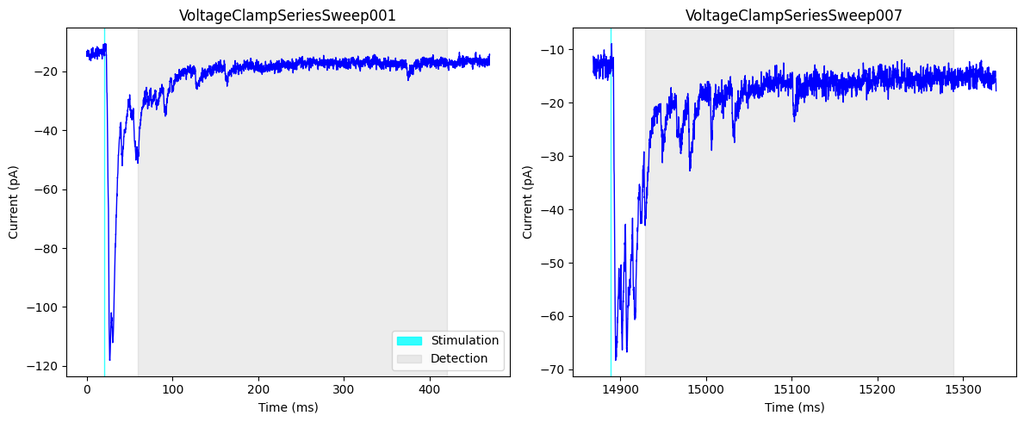

```
Stimulation and detection windows:
Trial 1 - Stimulation: 20.0-20.3 ms
Trial 1 - Detection: 60.0-420.0 ms
```

```python
import matplotlib.pyplot as plt
import numpy as np

# Get optogenetic timing information
optogenetics_table_df = nwbfile.intervals["optogenetic_epochs_table"].to_dataframe()
stimulation_entries_df = optogenetics_table_df[optogenetics_table_df["stimulation_on"] == True]
detection_entries_df = optogenetics_table_df[optogenetics_table_df["stage_name"] == "detection"]

# Create subplots side by side
fig, (ax1, ax2) = plt.subplots(1, 2, figsize=(12, 5))

for trial_index, (trial_name, ax, title) in enumerate([(1, ax1, "VoltageClampSeriesSweep001"), (7, ax2, "VoltageClampSeriesSweep007")]):
    # Get voltage clamp response
    series_name = f"VoltageClampSeriesSweep{trial_index + 1:03d}"
    voltage_clamp_response = nwbfile.acquisition[series_name]
    timestamps_in_seconds = voltage_clamp_response.get_timestamps()
    data_in_amperes = voltage_clamp_response.get_data_in_units()
    data_in_pico_amperes = data_in_amperes * 1e12

    # Get timing info for this trial
    stimulation_info = stimulation_entries_df.iloc[trial_index]
    detection_info = detection_entries_df.iloc[trial_index]

    stimulation_start_ms = stimulation_info["start_time"] * 1000
    stimulation_stop_ms = stimulation_info["stop_time"] * 1000
    detection_start_ms = detection_info["start_time"] * 1000
    detection_stop_ms = detection_info["stop_time"] * 1000

    # Show data up to 50ms after detection window ends
    timestamps_in_milliseconds = timestamps_in_seconds * 1000
    starting_time = timestamps_in_milliseconds[0]
    end_time = detection_stop_ms + 50
    mask = (timestamps_in_milliseconds >= starting_time) & (timestamps_in_milliseconds <= end_time)
    timestamps_filtered = timestamps_in_milliseconds[mask]
    data_filtered = data_in_pico_amperes[mask]

    # Plot the data
    ax.plot(timestamps_filtered, data_filtered, 'b-', linewidth=1)
    ax.axvspan(stimulation_start_ms, stimulation_stop_ms, color="cyan", alpha=0.8, label="Stimulation")
    ax.axvspan(detection_start_ms, detection_stop_ms, color="gray", alpha=0.15, label="Detection")

    ax.set_xlabel("Time (ms)")
    ax.set_ylabel("Current (pA)")
    ax.set_title(title)

    if trial_index == 0:  # Add legend only to first subplot
        ax.legend()

plt.tight_layout()
plt.show()

print("Stimulation and detection windows:")
print(f"Trial 1 - Stimulation: {stimulation_entries_df.iloc[0]['start_time']*1000:.1f}-{stimulation_entries_df.iloc[0]['stop_time']*1000:.1f} ms")
print(f"Trial 1 - Detection: {detection_entries_df.iloc[0]['start_time']*1000:.1f}-{detection_entries_df.iloc[0]['stop_time']*1000:.1f} ms")
```

### Event Detection and Analysis

#### MAD-Based Noise Estimation for Robust Event Detection

For accurate oEPSC event detection, we use **Median Absolute Deviation (MAD)** instead of standard deviation to estimate baseline noise. This approach is more robust to outliers (including the events themselves) and provides better threshold estimates.

**Key parameters:**

- **Detection window shift**: 100ms after original detection start (to avoid stimulation artifacts)
- **Event threshold**: ±5 × MAD-based standard deviation from median
- **Event merging**: Combine events within 1ms (handles multi-threshold crossings from single events)

```python
import matplotlib.pyplot as plt
import numpy as np

# Control parameters for event detection
detection_window_shift_ms = 100  # Shift detection window start by this many ms
event_merge_distance_ms = 1.0    # Merge events within this distance

def merge_nearby_events(event_times, event_amplitudes, merge_distance_ms):
    """Merge events within merge_distance_ms, keeping maximum amplitude"""
    if len(event_times) == 0:
        return event_times, event_amplitudes

    times = np.array(event_times)
    amplitudes = np.array(event_amplitudes)
    sorted_indices = np.argsort(times)
    times = times[sorted_indices]
    amplitudes = amplitudes[sorted_indices]

    merged_times = []
    merged_amplitudes = []

    i = 0
    while i < len(times):
        current_time = times[i]
        current_amp = amplitudes[i]

        # Find all events within merge_distance_ms
        j = i + 1
        max_amp = current_amp
        max_amp_time = current_time

        while j < len(times) and (times[j] - current_time) <= merge_distance_ms:
            if amplitudes[j] > max_amp:
                max_amp = amplitudes[j]
                max_amp_time = times[j]
            j += 1

        merged_times.append(max_amp_time)
        merged_amplitudes.append(max_amp)
        i = j

    return merged_times, merged_amplitudes

# Demonstrate event detection on one sweep
trial_index = 0
series_name = f"VoltageClampSeriesSweep{trial_index + 1:03d}"
voltage_clamp_response = nwbfile.acquisition[series_name]
timestamps_in_seconds = voltage_clamp_response.get_timestamps()
data_in_amperes = voltage_clamp_response.get_data_in_units()
data_in_pico_amperes = data_in_amperes * 1e12

# Get timing information
stimulation_info = stimulation_entries_df.iloc[trial_index]
detection_info = detection_entries_df.iloc[trial_index]

detection_start_ms_original = detection_info["start_time"] * 1000
detection_stop_ms = detection_info["stop_time"] * 1000
detection_start_ms_shifted = detection_start_ms_original + detection_window_shift_ms

# Filter data to shifted detection window
timestamps_in_milliseconds = timestamps_in_seconds * 1000
detection_mask = (timestamps_in_milliseconds >= detection_start_ms_shifted) & (timestamps_in_milliseconds <= detection_stop_ms)
detection_data = data_in_pico_amperes[detection_mask]
detection_timestamps = timestamps_in_milliseconds[detection_mask]

if len(detection_data) > 0:
    # Calculate MAD-based standard deviation
    noise_median = np.median(detection_data)
    mad = np.median(np.abs(detection_data - noise_median))
    mad_std = mad * 1.4826  # MAD to standard deviation conversion

    event_threshold_positive = noise_median + 5 * mad_std
    event_threshold_negative = noise_median - 5 * mad_std

    # Find events
    positive_event_indices = np.where(detection_data > event_threshold_positive)[0]
    negative_event_indices = np.where(detection_data < event_threshold_negative)[0]

    # Calculate amplitudes and merge nearby events
    positive_event_times_raw = detection_timestamps[positive_event_indices] if len(positive_event_indices) > 0 else []
    negative_event_times_raw = detection_timestamps[negative_event_indices] if len(negative_event_indices) > 0 else []

    positive_event_amplitudes_raw = detection_data[positive_event_indices] - noise_median if len(positive_event_indices) > 0 else []
    negative_event_amplitudes_raw = noise_median - detection_data[negative_event_indices] if len(negative_event_indices) > 0 else []

    positive_event_times_merged, positive_event_amplitudes_merged = merge_nearby_events(
        positive_event_times_raw, positive_event_amplitudes_raw, event_merge_distance_ms)
    negative_event_times_merged, negative_event_amplitudes_merged = merge_nearby_events(
        negative_event_times_raw, negative_event_amplitudes_raw, event_merge_distance_ms)

    print(f"Event Detection Results for {series_name}:")
    print(f"  Noise median: {noise_median:.2f} pA")
    print(f"  MAD-based std: {mad_std:.2f} pA")
    print(f"  Positive threshold: {event_threshold_positive:.2f} pA")
    print(f"  Negative threshold: {event_threshold_negative:.2f} pA")
    print(f"  Raw events: +{len(positive_event_amplitudes_raw)}, -{len(negative_event_amplitudes_raw)}")
    print(f"  Merged events: +{len(positive_event_amplitudes_merged)}, -{len(negative_event_amplitudes_merged)}")

    if len(positive_event_amplitudes_merged) > 0:
        print(f"  Positive event amplitudes: {[f'{amp:.1f}' for amp in positive_event_amplitudes_merged]} pA")
    if len(negative_event_amplitudes_merged) > 0:
        print(f"  Negative event amplitudes: {[f'{amp:.1f}' for amp in negative_event_amplitudes_merged]} pA")

else:
    print(f"No data in detection window for {series_name}")
```

```
Event Detection Results for VoltageClampSeriesSweep001:
  Noise median: -17.52 pA
  MAD-based std: 1.27 pA
  Positive threshold: -11.18 pA
  Negative threshold: -23.85 pA
  Raw events: +0, -5
  Merged events: +0, -1
  Negative event amplitudes: ['7.5'] pA
```

### Comprehensive Event Analysis Grid

Finally, let's analyze all voltage clamp sweeps in this session systematically, showing event detection across all trials in a grid format. This provides a complete overview of optogenetic responses throughout the experimental session.

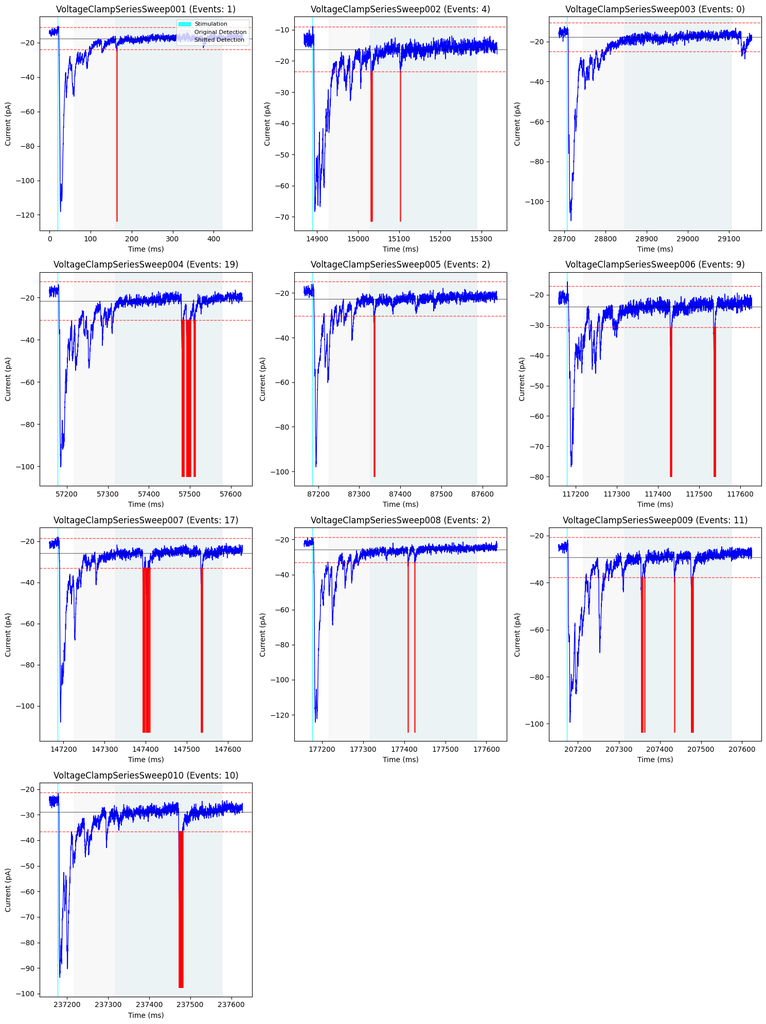

```
=== COMPREHENSIVE oEPSC ANALYSIS SUMMARY ===
Session: dSPN++OffState++none++WT++20230706
Total sweeps analyzed: 10
Total events detected: 75
Positive events: 0
Negative events: 75

Negative event statistics:
  Mean amplitude: 14.32 ± 5.97 pA
  Median amplitude: 12.94 pA
  Range: 6.9 to 33.6 pA

Analysis parameters:
  Detection window shift: 100 ms
  Event merge distance: 1.0 ms
  Event threshold: ±5 x MAD-based standard deviation
```

```python
import matplotlib.pyplot as plt
import numpy as np

# Get all acquisition keys for voltage clamp series
acquisition_keys = [key for key in nwbfile.acquisition.keys() if key.startswith("VoltageClampSeries")]
num_sweeps = len(acquisition_keys)

# Calculate grid dimensions
cols = 3
rows = (num_sweeps + cols - 1) // cols

# Create subplots grid
fig, axes = plt.subplots(rows, cols, figsize=(15, 5*rows))
axes = axes.flatten() if num_sweeps > 1 else [axes]

# Initialize summary statistics
all_positive_amplitudes = []
all_negative_amplitudes = []
total_events = 0

# Process each sweep
for i, sweep_key in enumerate(acquisition_keys):
    trial_number = int(sweep_key.split('Sweep')[-1])

    # Get voltage clamp response
    voltage_clamp_response = nwbfile.acquisition[sweep_key]
    timestamps_in_seconds = voltage_clamp_response.get_timestamps()
    data_in_amperes = voltage_clamp_response.get_data_in_units()
    data_in_pico_amperes = data_in_amperes * 1e12

    # Get timing information for this trial
    if trial_number <= len(stimulation_entries_df) and trial_number <= len(detection_entries_df):
        stimulation_info = stimulation_entries_df.iloc[trial_number - 1]
        detection_info = detection_entries_df.iloc[trial_number - 1]

        stimulation_start_ms = stimulation_info["start_time"] * 1000
        stimulation_stop_ms = stimulation_info["stop_time"] * 1000
        detection_start_ms_original = detection_info["start_time"] * 1000
        detection_stop_ms = detection_info["stop_time"] * 1000
        detection_start_ms_shifted = detection_start_ms_original + detection_window_shift_ms

        # Show data up to 50ms after detection window ends
        timestamps_in_milliseconds = timestamps_in_seconds * 1000
        starting_time = timestamps_in_milliseconds[0]
        end_time = detection_stop_ms + 50
        mask = (timestamps_in_milliseconds >= starting_time) & (timestamps_in_milliseconds <= end_time)
        timestamps_filtered = timestamps_in_milliseconds[mask]
        data_filtered = data_in_pico_amperes[mask]

        # Calculate noise statistics and detect events
        detection_mask = (timestamps_filtered >= detection_start_ms_shifted) & (timestamps_filtered <= detection_stop_ms)
        detection_data = data_filtered[detection_mask]
        detection_timestamps = timestamps_filtered[detection_mask]

        if len(detection_data) > 0:
            # MAD-based noise estimation
            noise_median = np.median(detection_data)
            mad = np.median(np.abs(detection_data - noise_median))
            mad_std = mad * 1.4826

            event_threshold_positive = noise_median + 5 * mad_std
            event_threshold_negative = noise_median - 5 * mad_std

            # Find and merge events
            positive_event_indices = np.where(detection_data > event_threshold_positive)[0]
            negative_event_indices = np.where(detection_data < event_threshold_negative)[0]

            positive_event_times_raw = detection_timestamps[positive_event_indices] if len(positive_event_indices) > 0 else []
            negative_event_times_raw = detection_timestamps[negative_event_indices] if len(negative_event_indices) > 0 else []

            positive_event_amplitudes_raw = detection_data[positive_event_indices] - noise_median if len(positive_event_indices) > 0 else []
            negative_event_amplitudes_raw = noise_median - detection_data[negative_event_indices] if len(negative_event_indices) > 0 else []

            # Merge nearby events
            positive_event_times_merged, positive_event_amplitudes_merged = merge_nearby_events(
                positive_event_times_raw, positive_event_amplitudes_raw, event_merge_distance_ms)
            negative_event_times_merged, negative_event_amplitudes_merged = merge_nearby_events(
                negative_event_times_raw, negative_event_amplitudes_raw, event_merge_distance_ms)

            # Collect amplitudes for summary
            all_positive_amplitudes.extend(positive_event_amplitudes_merged)
            all_negative_amplitudes.extend(negative_event_amplitudes_merged)

            sweep_events = len(positive_event_amplitudes_merged) + len(negative_event_amplitudes_merged)
            total_events += sweep_events

            # Plot
            ax = axes[i]
            ax.plot(timestamps_filtered, data_filtered, 'b-', linewidth=1)
            ax.axvspan(stimulation_start_ms, stimulation_stop_ms, color="cyan", alpha=0.8, label="Stimulation")
            ax.axvspan(detection_start_ms_original, detection_stop_ms, color="gray", alpha=0.05, label="Original Detection")
            ax.axvspan(detection_start_ms_shifted, detection_stop_ms, color="lightblue", alpha=0.15, label="Shifted Detection")
            ax.axhline(y=noise_median, color='black', linestyle='-', alpha=0.5, linewidth=1)
            ax.axhline(y=event_threshold_positive, color='red', linestyle='--', alpha=0.7, linewidth=1)
            ax.axhline(y=event_threshold_negative, color='red', linestyle='--', alpha=0.7, linewidth=1)

            # Get plot limits for event markers
            y_min, y_max = ax.get_ylim()

            # Add event markers
            for event_time in positive_event_times_merged:
                ax.plot([event_time, event_time], [event_threshold_positive, y_max],
                        color='red', alpha=0.8, linewidth=2)

            for event_time in negative_event_times_merged:
                ax.plot([event_time, event_time], [y_min, event_threshold_negative],
                        color='red', alpha=0.8, linewidth=2)

            ax.set_xlabel("Time (ms)")
            ax.set_ylabel("Current (pA)")
            ax.set_title(f"{sweep_key} (Events: {sweep_events})")

            # Add legend only to first subplot
            if i == 0:
                ax.legend(loc='upper right', fontsize=8)

# Hide empty subplots
for i in range(num_sweeps, len(axes)):
    axes[i].set_visible(False)

plt.tight_layout()
plt.show()

# Print comprehensive summary
print(f"\n=== COMPREHENSIVE oEPSC ANALYSIS SUMMARY ===")
print(f"Session: {get_session_id(asset.path)}")
print(f"Total sweeps analyzed: {num_sweeps}")
print(f"Total events detected: {total_events}")
print(f"Positive events: {len(all_positive_amplitudes)}")
print(f"Negative events: {len(all_negative_amplitudes)}")

if len(all_positive_amplitudes) > 0:
    print(f"\nPositive event statistics:")
    print(f"  Mean amplitude: {np.mean(all_positive_amplitudes):.2f} ± {np.std(all_positive_amplitudes):.2f} pA")
    print(f"  Median amplitude: {np.median(all_positive_amplitudes):.2f} pA")
    print(f"  Range: {np.min(all_positive_amplitudes):.1f} to {np.max(all_positive_amplitudes):.1f} pA")

if len(all_negative_amplitudes) > 0:
    print(f"\nNegative event statistics:")
    print(f"  Mean amplitude: {np.mean(all_negative_amplitudes):.2f} ± {np.std(all_negative_amplitudes):.2f} pA")
    print(f"  Median amplitude: {np.median(all_negative_amplitudes):.2f} pA")
    print(f"  Range: {np.min(all_negative_amplitudes):.1f} to {np.max(all_negative_amplitudes):.1f} pA")

print(f"\nAnalysis parameters:")
print(f"  Detection window shift: {detection_window_shift_ms} ms")
print(f"  Event merge distance: {event_merge_distance_ms} ms")
print(f"  Event threshold: ±5 x MAD-based standard deviation")
```

# Acetylcholine Biosensor Experiments - GRABACh3.0 Imaging

## NWB Organization for Biosensor Data

GRABACh3.0 acetylcholine biosensor experiments measure cholinergic signaling dynamics using genetically encoded fluorescent sensors. These experiments reveal state-dependent modulation of acetylcholine release in Parkinson's disease and levodopa-induced dyskinesia.

**Key experimental parameters:**

- **Biosensor**: GRABACh3.0 genetically encoded acetylcholine indicator
- **Imaging**: Two-photon microscopy at 920nm excitation, 520nm emission
- **Target region**: Dorsal striatum
- **Stimulation**: Electrical stimulation to evoke acetylcholine release
- **Experimental conditions**: Control (CTRL), Parkinsonian (PD/6-OHDA), Dyskinetic off-state (OFF)

**Data stored in `processing/ophys` module:**

- **ROI Response Series**: Processed fluorescence traces from regions of interest containing biosensor signal
- **Plane Segmentation**: ROI definitions showing areas of biosensor expression
- **Trials Table**: Experimental metadata including stimulation parameters, treatments, and timing

**Analysis workflow:**

1. Extract fluorescence time series from ROI response series
2. Apply background subtraction and baseline normalization
3. Calculate area under curve (AUC) for stimulus-evoked responses
4. Normalize using calibration values (Fmax from acetylcholine, Fmin from TTX)
5. Compare responses across experimental conditions

### Filtering for Acetylcholine Biosensor Data from Figure 5

These experiments examine acetylcholine release dynamics across three experimental conditions that model different stages of Parkinson's disease pathology:

- **CTRL**: Control unlesioned mice with normal cholinergic signaling
- **PD**: Parkinsonian mice (6-OHDA lesioned, no levodopa treatment) showing reduced cholinergic tone
- **OFF**: Dyskinetic mice in off-state (24-48h after chronic levodopa) with altered cholinergic dynamics

```python
# Filter for acetylcholine biosensor experiments (Figure 5F equivalent).
# These use pure ophys modality with pan cell type (GRABACh3.0 pan-striatal expression).

def is_achfp(asset_path: str) -> bool:
    """Acetylcholine biosensor (GRABACh3.0) files."""
    return get_modality(asset_path) == 'ophys' and get_cell_type(get_session_id(asset_path)) == 'pan'

available_oepsc_assets = [asset for asset in assets_list if is_achfp(asset.path)]

print(f"Found {len(available_oepsc_assets)} acetylcholine biosensor files:")
for i, asset in enumerate(available_oepsc_assets[:]):
    session_id = get_session_id(asset.path)
    fields = parse_session_id(session_id)
    print(f"  {i+1}. {asset.path}")
    print(f"     Session:   {session_id}")
    print(f"     Cell type: {fields.get('cell_type')}")
    print(f"     State:     {fields.get('state')}")
    print(f"     Genotype:  {fields.get('genotype')}")
    print()
```

```
Found 11 acetylcholine biosensor files:
  1. sub-SubjectRecordedAt20240402/sub-SubjectRecordedAt20240402_ses-pan++CTRL++none++WT++20240402_ophys.nwb
     Session:   pan++CTRL++none++WT++20240402
     Cell type: pan
     State:     CTRL
     Genotype:  WT

  2. sub-SubjectRecordedAt20240405/sub-SubjectRecordedAt20240405_ses-pan++CTRL++none++WT++20240405_ophys.nwb
     Session:   pan++CTRL++none++WT++20240405
     Cell type: pan
     State:     CTRL
     Genotype:  WT

  3. sub-SubjectRecordedAt20240410/sub-SubjectRecordedAt20240410_ses-pan++CTRL++none++WT++20240410_ophys.nwb
     Session:   pan++CTRL++none++WT++20240410
     Cell type: pan
     State:     CTRL
     Genotype:  WT

  4. sub-SubjectRecordedAt20240412/sub-SubjectRecordedAt20240412_ses-pan++PD++none++WT++20240412_ophys.nwb
     Session:   pan++PD++none++WT++20240412
     Cell type: pan
     State:     PD
     Genotype:  WT

  5. sub-SubjectRecordedAt20240416/sub-SubjectRecordedAt20240416_ses-pan++PD++none++WT++20240416_ophys.nwb
     Session:   pan++PD++none++WT++20240416
     Cell type: pan
     State:     PD
     Genotype:  WT

  6. sub-SubjectRecordedAt20240509/sub-SubjectRecordedAt20240509_ses-pan++PD++none++WT++20240509_ophys.nwb
     Session:   pan++PD++none++WT++20240509
     Cell type: pan
     State:     PD
     Genotype:  WT

  7. sub-SubjectRecordedAt20240524/sub-SubjectRecordedAt20240524_ses-pan++OFF++none++WT++20240524_ophys.nwb
     Session:   pan++OFF++none++WT++20240524
     Cell type: pan
```

[output cut: 11 more lines]

```
     Cell type: pan
     State:     OFF
     Genotype:  WT

  10. sub-SubjectRecordedAt20240603/sub-SubjectRecordedAt20240603_ses-pan++OFF++none++WT++20240603_ophys.nwb
     Session:   pan++OFF++none++WT++20240603
     Cell type: pan
     State:     OFF
     Genotype:  WT

  11. sub-SubjectRecordedAt20240604/sub-SubjectRecordedAt20240604_ses-pan++OFF++none++WT++20240604_ophys.nwb
     Session:   pan++OFF++none++WT++20240604
     Cell type: pan
     State:     OFF
     Genotype:  WT
```

### Streaming Acetylcholine Biosensor Data

The NWB files contain fluorescence time series from GRABACh3.0 biosensor experiments. Each file includes:

- **Trials table**: Metadata about stimulation timing, treatment conditions, and experimental parameters
- **ROI Response Series**: Processed fluorescence traces from regions of interest

```python
import h5py
import remfile
from pynwb import NWBHDF5IO

asset = available_oepsc_assets[0]
s3_url = asset.get_content_url(follow_redirects=1, strip_query=False)
file_system = remfile.File(s3_url, disk_cache=remfile.DiskCache("nwb-cache"))
file = h5py.File(file_system, mode="r")

io = NWBHDF5IO(file=file)
nwbfile = io.read()
nwbfile
```

root (NWBFile)

session_description: Acetylcholine GRAB biosensor session for UL control condition in slice slice3ROI2. Contains multiple trials with different treatments and stimulation protocols.

identifier: ab6550dd-2167-450e-8235-2199471082d5

**session_start_time**

2024-04-02 16:00:36-05:00

**timestamps_reference_time**

2024-04-02 16:00:36-05:00

**file_create_date**

**0**

2026-05-22 10:05:17.035746-06:00

**experimenter**

('Zhai, Shenyu', 'Cui, Qiaoling', 'Wokosin, David', 'Sun, Linqing', 'Tkatch, Tatiana', 'Crittenden, Jill R.', 'Graybiel, Ann M.', 'Surmeier, D. James')

**related_publications**

('https://doi.org/10.1101/2025.01.02.631090',)

**acquisition**

**ImagesBackgroundReferences (Images)**

description: Background reference images used for PMT background subtraction across all trials. These images were acquired with zero laser power to measure baseline PMT response for background correction as described in methods.

**ImageAcetylcholineCalibrationCh216BitReferenceRepetition001 (Image)**

description: Background reference image for Ch2 (16bit). PMT background measured with zero laser power for background subtraction.

**ImageAcetylcholineCalibrationCh28BitReferenceRepetition001 (Image)**

description: Background reference image for Ch2 (8bit). PMT background measured with zero laser power for background subtraction. (Window-specific reference image)

**ImageAcetylcholineCalibrationCh316BitReferenceRepetition001 (Image)**

description: Background reference image for Ch3 (16bit). PMT background measured with zero laser power for background subtraction.

**ImageAcetylcholineCalibrationunknown8BitReferenceRepetition001 (Image)**

description: Background reference image from BOT_04022024_slice3ROI2_ACh-001-Cycle00001-Window2-Dodt-8bit-Reference.tif. PMT background measured with zero laser power for background subtraction. (Window-specific reference image)

**ImageControlBurstStimulationCh216BitReferenceRepetition001 (Image)**

description: Background reference image for Ch2 (16bit). PMT background measured with zero laser power for background subtraction.

**ImageControlBurstStimulationCh216BitReferenceRepetition002 (Image)**

description: Background reference image for Ch2 (16bit). PMT background measured with zero laser power for background subtraction.

**ImageControlBurstStimulationCh28BitReferenceRepetition001 (Image)**

description: Background reference image for Ch2 (8bit). PMT background measured with zero laser power for background subtraction. (Window-specific reference image)

**ImageControlBurstStimulationCh28BitReferenceRepetition002 (Image)**

description: Background reference image for Ch2 (8bit). PMT background measured with zero laser power for background subtraction. (Window-specific reference image)

**ImageControlBurstStimulationCh316BitReferenceRepetition001 (Image)**

description: Background reference image for Ch3 (16bit). PMT background measured with zero laser power for background subtraction.

**ImageControlBurstStimulationCh316BitReferenceRepetition002 (Image)**

description: Background reference image for Ch3 (16bit). PMT background measured with zero laser power for background subtraction.

**ImageControlBurstStimulationunknown8BitReferenceRepetition001 (Image)**

description: Background reference image from BOT_04022024_slice3ROI2_ctr_burst-001-Cycle00001-Window2-Dodt-8bit-Reference.tif. PMT background measured with zero laser power for background subtraction. (Window-specific reference image)

**ImageControlBurstStimulationunknown8BitReferenceRepetition002 (Image)**

description: Background reference image from BOT_04022024_slice3ROI2_ctr_burst-002-Cycle00001-Window2-Dodt-8bit-Reference.tif. PMT background measured with zero laser power for background subtraction. (Window-specific reference image)

**ImageControlSinglePulseCh216BitReferenceRepetition001 (Image)**

description: Background reference image for Ch2 (16bit). PMT background measured with zero laser power for background subtraction.

**ImageControlSinglePulseCh216BitReferenceRepetition002 (Image)**

description: Background reference image for Ch2 (16bit). PMT background measured with zero laser power for background subtraction.

**ImageControlSinglePulseCh28BitReferenceRepetition001 (Image)**

description: Background reference image for Ch2 (8bit). PMT background measured with zero laser power for background subtraction. (Window-specific reference image)

**ImageControlSinglePulseCh28BitReferenceRepetition002 (Image)**

description: Background reference image for Ch2 (8bit). PMT background measured with zero laser power for background subtraction. (Window-specific reference image)

**ImageControlSinglePulseCh316BitReferenceRepetition001 (Image)**

description: Background reference image for Ch3 (16bit). PMT background measured with zero laser power for background subtraction.

**ImageControlSinglePulseCh316BitReferenceRepetition002 (Image)**

description: Background reference image for Ch3 (16bit). PMT background measured with zero laser power for background subtraction.

**ImageControlSinglePulseunknown8BitReferenceRepetition001 (Image)**

description: Background reference image from BOT_04022024_slice3ROI2_ctr_single-001-Cycle00001-Window2-Dodt-8bit-Reference.tif. PMT background measured with zero laser power for background subtraction. (Window-specific reference image)

**ImageControlSinglePulseunknown8BitReferenceRepetition002 (Image)**

description: Background reference image from BOT_04022024_slice3ROI2_ctr_single-002-Cycle00001-Window2-Dodt-8bit-Reference.tif. PMT background measured with zero laser power for background subtraction. (Window-specific reference image)

**ImageQuinpiroleBurstStimulationCh216BitReferenceRepetition001 (Image)**

description: Background reference image for Ch2 (16bit). PMT background measured with zero laser power for background subtraction.

**ImageQuinpiroleBurstStimulationCh216BitReferenceRepetition002 (Image)**

description: Background reference image for Ch2 (16bit). PMT background measured with zero laser power for background subtraction.

**ImageQuinpiroleBurstStimulationCh28BitReferenceRepetition001 (Image)**

description: Background reference image for Ch2 (8bit). PMT background measured with zero laser power for background subtraction. (Window-specific reference image)

**ImageQuinpiroleBurstStimulationCh28BitReferenceRepetition002 (Image)**

description: Background reference image for Ch2 (8bit). PMT background measured with zero laser power for background subtraction. (Window-specific reference image)

**ImageQuinpiroleBurstStimulationCh316BitReferenceRepetition001 (Image)**

description: Background reference image for Ch3 (16bit). PMT background measured with zero laser power for background subtraction.

**ImageQuinpiroleBurstStimulationCh316BitReferenceRepetition002 (Image)**

description: Background reference image for Ch3 (16bit). PMT background measured with zero laser power for background subtraction.

**ImageQuinpiroleBurstStimulationunknown8BitReferenceRepetition001 (Image)**

description: Background reference image from BOT_04022024_slice3ROI2_quin_burst-001-Cycle00001-Window2-Dodt-8bit-Reference.tif. PMT background measured with zero laser power for background subtraction. (Window-specific reference image)

**ImageQuinpiroleBurstStimulationunknown8BitReferenceRepetition002 (Image)**

description: Background reference image from BOT_04022024_slice3ROI2_quin_burst-002-Cycle00001-Window2-Dodt-8bit-Reference.tif. PMT background measured with zero laser power for background subtraction. (Window-specific reference image)

**ImageQuinpiroleSinglePulseCh216BitReferenceRepetition001 (Image)**

description: Background reference image for Ch2 (16bit). PMT background measured with zero laser power for background subtraction.

**ImageQuinpiroleSinglePulseCh216BitReferenceRepetition002 (Image)**

description: Background reference image for Ch2 (16bit). PMT background measured with zero laser power for background subtraction.

**ImageQuinpiroleSinglePulseCh28BitReferenceRepetition001 (Image)**

description: Background reference image for Ch2 (8bit). PMT background measured with zero laser power for background subtraction. (Window-specific reference image)

**ImageQuinpiroleSinglePulseCh28BitReferenceRepetition002 (Image)**

description: Background reference image for Ch2 (8bit). PMT background measured with zero laser power for background subtraction. (Window-specific reference image)

**ImageQuinpiroleSinglePulseCh316BitReferenceRepetition001 (Image)**

description: Background reference image for Ch3 (16bit). PMT background measured with zero laser power for background subtraction.

**ImageQuinpiroleSinglePulseCh316BitReferenceRepetition002 (Image)**

description: Background reference image for Ch3 (16bit). PMT background measured with zero laser power for background subtraction.

**ImageQuinpiroleSinglePulseunknown8BitReferenceRepetition001 (Image)**

description: Background reference image from BOT_04022024_slice3ROI2_quin_single-001-Cycle00001-Window2-Dodt-8bit-Reference.tif. PMT background measured with zero laser power for background subtraction. (Window-specific reference image)

**ImageQuinpiroleSinglePulseunknown8BitReferenceRepetition002 (Image)**

description: Background reference image from BOT_04022024_slice3ROI2_quin_single-002-Cycle00001-Window2-Dodt-8bit-Reference.tif. PMT background measured with zero laser power for background subtraction. (Window-specific reference image)

**ImageSulpirideBurstStimulationCh216BitReferenceRepetition001 (Image)**

description: Background reference image for Ch2 (16bit). PMT background measured with zero laser power for background subtraction.

**ImageSulpirideBurstStimulationCh216BitReferenceRepetition002 (Image)**

description: Background reference image for Ch2 (16bit). PMT background measured with zero laser power for background subtraction.

**ImageSulpirideBurstStimulationCh28BitReferenceRepetition001 (Image)**

description: Background reference image for Ch2 (8bit). PMT background measured with zero laser power for background subtraction. (Window-specific reference image)

**ImageSulpirideBurstStimulationCh28BitReferenceRepetition002 (Image)**

description: Background reference image for Ch2 (8bit). PMT background measured with zero laser power for background subtraction. (Window-specific reference image)

**ImageSulpirideBurstStimulationCh316BitReferenceRepetition001 (Image)**

description: Background reference image for Ch3 (16bit). PMT background measured with zero laser power for background subtraction.

**ImageSulpirideBurstStimulationCh316BitReferenceRepetition002 (Image)**

description: Background reference image for Ch3 (16bit). PMT background measured with zero laser power for background subtraction.

**ImageSulpirideBurstStimulationunknown8BitReferenceRepetition001 (Image)**

description: Background reference image from BOT_04022024_slice3ROI2_sul_burst-001-Cycle00001-Window2-Dodt-8bit-Reference.tif. PMT background measured with zero laser power for background subtraction. (Window-specific reference image)

**ImageSulpirideBurstStimulationunknown8BitReferenceRepetition002 (Image)**

description: Background reference image from BOT_04022024_slice3ROI2_sul_burst-002-Cycle00001-Window2-Dodt-8bit-Reference.tif. PMT background measured with zero laser power for background subtraction. (Window-specific reference image)

**ImageSulpirideSinglePulseCh216BitReferenceRepetition001 (Image)**

description: Background reference image for Ch2 (16bit). PMT background measured with zero laser power for background subtraction.

**ImageSulpirideSinglePulseCh216BitReferenceRepetition002 (Image)**

description: Background reference image for Ch2 (16bit). PMT background measured with zero laser power for background subtraction.

**ImageSulpirideSinglePulseCh216BitReferenceRepetition003 (Image)**

description: Background reference image for Ch2 (16bit). PMT background measured with zero laser power for background subtraction.

**ImageSulpirideSinglePulseCh28BitReferenceRepetition001 (Image)**

description: Background reference image for Ch2 (8bit). PMT background measured with zero laser power for background subtraction. (Window-specific reference image)

**ImageSulpirideSinglePulseCh28BitReferenceRepetition002 (Image)**

description: Background reference image for Ch2 (8bit). PMT background measured with zero laser power for background subtraction. (Window-specific reference image)

**ImageSulpirideSinglePulseCh28BitReferenceRepetition003 (Image)**

description: Background reference image for Ch2 (8bit). PMT background measured with zero laser power for background subtraction. (Window-specific reference image)

**ImageSulpirideSinglePulseCh316BitReferenceRepetition001 (Image)**

description: Background reference image for Ch3 (16bit). PMT background measured with zero laser power for background subtraction.

**ImageSulpirideSinglePulseCh316BitReferenceRepetition002 (Image)**

description: Background reference image for Ch3 (16bit). PMT background measured with zero laser power for background subtraction.

**ImageSulpirideSinglePulseCh316BitReferenceRepetition003 (Image)**

description: Background reference image for Ch3 (16bit). PMT background measured with zero laser power for background subtraction.

**ImageSulpirideSinglePulseunknown8BitReferenceRepetition001 (Image)**

description: Background reference image from BOT_04022024_slice3ROI2_sul_single-001-Cycle00001-Window2-Dodt-8bit-Reference.tif. PMT background measured with zero laser power for background subtraction. (Window-specific reference image)

**ImageSulpirideSinglePulseunknown8BitReferenceRepetition002 (Image)**

description: Background reference image from BOT_04022024_slice3ROI2_sul_single-002-Cycle00001-Window2-Dodt-8bit-Reference.tif. PMT background measured with zero laser power for background subtraction. (Window-specific reference image)

**ImageSulpirideSinglePulseunknown8BitReferenceRepetition003 (Image)**

description: Background reference image from BOT_04022024_slice3ROI2_sul_single-003-Cycle00001-Window2-Dodt-8bit-Reference.tif. PMT background measured with zero laser power for background subtraction. (Window-specific reference image)

**ImageTTXCalibrationCh216BitReferenceRepetition001 (Image)**

description: Background reference image for Ch2 (16bit). PMT background measured with zero laser power for background subtraction.

**ImageTTXCalibrationCh28BitReferenceRepetition001 (Image)**

description: Background reference image for Ch2 (8bit). PMT background measured with zero laser power for background subtraction. (Window-specific reference image)

**ImageTTXCalibrationCh316BitReferenceRepetition001 (Image)**

description: Background reference image for Ch3 (16bit). PMT background measured with zero laser power for background subtraction.

**ImageTTXCalibrationunknown8BitReferenceRepetition001 (Image)**

description: Background reference image from BOT_04022024_slice3ROI2_TTX-001-Cycle00001-Window2-Dodt-8bit-Reference.tif. PMT background measured with zero laser power for background subtraction. (Window-specific reference image)

**TwoPhotonSeriesDoDTAcetylcholineCalibrationRepetition001 (TwoPhotonSeries)**

starting_time: 0.0

rate: 5.009006193135257

resolution: -1.0

comments: no comments

description: Imaging data acquired from the Bruker Two-Photon Microscope.

conversion: 1.0

offset: 0.0

unit: n.a.

**data**

HDF5 dataset

| Data type | uint16 |
| --- | --- |
| Shape | (39, 128, 128) |
| Array size | 1.22 MiB |
| Chunk shape | (39, 128, 128) |
| Compression | gzip |
| Compression opts | 4 |
| Uncompressed size (bytes) | 1277952 |
| Compressed size (bytes) | 881405 |
| Compression ratio | 1.4499032794231936 |

starting_time_unit: seconds

**dimension**

HDF5 dataset

| Data type | int64 |
| --- | --- |
| Shape | (2,) |
| Array size | 16.00 bytes |
| Chunk shape | None |
| Compression | None |
| Compression opts | None |
| Uncompressed size (bytes) | 16 |
| Compressed size (bytes) | 16 |
| Compression ratio | 1.0 |

[128 128]

**field_of_view**

HDF5 dataset

| Data type | float64 |
| --- | --- |
| Shape | (2,) |
| Array size | 16.00 bytes |
| Chunk shape | None |
| Compression | None |
| Compression opts | None |
| Uncompressed size (bytes) | 16 |
| Compressed size (bytes) | 16 |
| Compression ratio | 1.0 |

[4.96958308e-05 4.96958308e-05]

**imaging_plane (ImagingPlane)**

**optical_channel**

**0 (OpticalChannel)**

description: An optical channel of the microscope.

emission_lambda: nan

description: Imaging plane for Bruker BOT recording (Dodt).

**device (Device)**

description: Bruker Prairie View two-photon microscope (BOT acquisition).

**model (DeviceModel)**

manufacturer: Bruker Corporation

model_number: Ultima In Vitro

description: Bruker Ultima In Vitro multiphoton microscope system (Bruker, Billerica, MA), mounted on an Olympus BX-51 upright microscope chassis for ex vivo two-photon laser-scanning imaging. Used in conjunction with patch-clamp electrophysiology and a Chameleon Ultra II (Coherent) tunable Ti:sapphire laser.

excitation_lambda: nan

indicator: unknown

location: Caudoputamen

conversion: 1.0

unit: meters

origin_coords_unit: meters

grid_spacing_unit: meters

scan_line_rate: 646.1617989144481

**TwoPhotonSeriesDoDTControlBurstStimulationRepetition001 (TwoPhotonSeries)**

starting_time: 0.0

rate: 5.009006193135257

resolution: -1.0

comments: no comments

description: Imaging data acquired from the Bruker Two-Photon Microscope.

conversion: 1.0

offset: 0.0

unit: n.a.

**data**

HDF5 dataset

| Data type | uint16 |
| --- | --- |
| Shape | (112, 128, 128) |
| Array size | 3.50 MiB |
| Chunk shape | (112, 128, 128) |
| Compression | gzip |
| Compression opts | 4 |
| Uncompressed size (bytes) | 3670016 |
| Compressed size (bytes) | 2534791 |
| Compression ratio | 1.447857436766976 |

starting_time_unit: seconds

**dimension**

HDF5 dataset

| Data type | int64 |
| --- | --- |
| Shape | (2,) |
| Array size | 16.00 bytes |
| Chunk shape | None |
| Compression | None |
| Compression opts | None |
| Uncompressed size (bytes) | 16 |
| Compressed size (bytes) | 16 |
| Compression ratio | 1.0 |

[128 128]

**field_of_view**

HDF5 dataset

| Data type | float64 |
| --- | --- |
| Shape | (2,) |
| Array size | 16.00 bytes |
| Chunk shape | None |
| Compression | None |
| Compression opts | None |
| Uncompressed size (bytes) | 16 |
| Compressed size (bytes) | 16 |
| Compression ratio | 1.0 |

[4.96958308e-05 4.96958308e-05]

**imaging_plane (ImagingPlane)**

**optical_channel**

**0 (OpticalChannel)**

description: An optical channel of the microscope.

emission_lambda: nan

description: Imaging plane for Bruker BOT recording (Dodt).

**device (Device)**

description: Bruker Prairie View two-photon microscope (BOT acquisition).

**model (DeviceModel)**

manufacturer: Bruker Corporation

model_number: Ultima In Vitro

description: Bruker Ultima In Vitro multiphoton microscope system (Bruker, Billerica, MA), mounted on an Olympus BX-51 upright microscope chassis for ex vivo two-photon laser-scanning imaging. Used in conjunction with patch-clamp electrophysiology and a Chameleon Ultra II (Coherent) tunable Ti:sapphire laser.

excitation_lambda: nan

indicator: unknown

location: Caudoputamen

conversion: 1.0

unit: meters

origin_coords_unit: meters

grid_spacing_unit: meters

scan_line_rate: 646.1617989144481

**TwoPhotonSeriesDoDTControlBurstStimulationRepetition002 (TwoPhotonSeries)**

starting_time: 0.0

rate: 5.009006193135257

resolution: -1.0

comments: no comments

description: Imaging data acquired from the Bruker Two-Photon Microscope.

conversion: 1.0

offset: 0.0

unit: n.a.

**data**

HDF5 dataset

| Data type | uint16 |
| --- | --- |
| Shape | (115, 128, 128) |
| Array size | 3.59 MiB |
| Chunk shape | (115, 128, 128) |
| Compression | gzip |
| Compression opts | 4 |
| Uncompressed size (bytes) | 3768320 |
| Compressed size (bytes) | 2603662 |
| Compression ratio | 1.4473153581378844 |

starting_time_unit: seconds

**dimension**

HDF5 dataset

| Data type | int64 |
| --- | --- |
| Shape | (2,) |
| Array size | 16.00 bytes |
| Chunk shape | None |
| Compression | None |
| Compression opts | None |
| Uncompressed size (bytes) | 16 |
| Compressed size (bytes) | 16 |
| Compression ratio | 1.0 |

[128 128]

**field_of_view**

HDF5 dataset

| Data type | float64 |
| --- | --- |
| Shape | (2,) |
| Array size | 16.00 bytes |
| Chunk shape | None |
| Compression | None |
| Compression opts | None |
| Uncompressed size (bytes) | 16 |
| Compressed size (bytes) | 16 |
| Compression ratio | 1.0 |

[4.96958308e-05 4.96958308e-05]

**imaging_plane (ImagingPlane)**

**optical_channel**

**0 (OpticalChannel)**

description: An optical channel of the microscope.

emission_lambda: nan

description: Imaging plane for Bruker BOT recording (Dodt).

**device (Device)**

description: Bruker Prairie View two-photon microscope (BOT acquisition).

**model (DeviceModel)**

manufacturer: Bruker Corporation

model_number: Ultima In Vitro

description: Bruker Ultima In Vitro multiphoton microscope system (Bruker, Billerica, MA), mounted on an Olympus BX-51 upright microscope chassis for ex vivo two-photon laser-scanning imaging. Used in conjunction with patch-clamp electrophysiology and a Chameleon Ultra II (Coherent) tunable Ti:sapphire laser.

excitation_lambda: nan

indicator: unknown

location: Caudoputamen

conversion: 1.0

unit: meters

origin_coords_unit: meters

grid_spacing_unit: meters

scan_line_rate: 646.1617989144481

**TwoPhotonSeriesDoDTControlSinglePulseRepetition001 (TwoPhotonSeries)**

starting_time: 0.0

rate: 5.009006193135257

resolution: -1.0

comments: no comments

description: Imaging data acquired from the Bruker Two-Photon Microscope.

conversion: 1.0

offset: 0.0

unit: n.a.

**data**

HDF5 dataset

| Data type | uint16 |
| --- | --- |
| Shape | (110, 128, 128) |
| Array size | 3.44 MiB |
| Chunk shape | (110, 128, 128) |
| Compression | gzip |
| Compression opts | 4 |
| Uncompressed size (bytes) | 3604480 |
| Compressed size (bytes) | 2487678 |
| Compression ratio | 1.4489335034518134 |

starting_time_unit: seconds

**dimension**

HDF5 dataset

| Data type | int64 |
| --- | --- |
| Shape | (2,) |
| Array size | 16.00 bytes |
| Chunk shape | None |
| Compression | None |
| Compression opts | None |
| Uncompressed size (bytes) | 16 |
| Compressed size (bytes) | 16 |
| Compression ratio | 1.0 |

[128 128]

**field_of_view**

HDF5 dataset

| Data type | float64 |
| --- | --- |
| Shape | (2,) |
| Array size | 16.00 bytes |
| Chunk shape | None |
| Compression | None |
| Compression opts | None |
| Uncompressed size (bytes) | 16 |
| Compressed size (bytes) | 16 |
| Compression ratio | 1.0 |

[4.96958308e-05 4.96958308e-05]

**imaging_plane (ImagingPlane)**

**optical_channel**

**0 (OpticalChannel)**

description: An optical channel of the microscope.

emission_lambda: nan

description: Imaging plane for Bruker BOT recording (Dodt).

**device (Device)**

description: Bruker Prairie View two-photon microscope (BOT acquisition).

**model (DeviceModel)**

manufacturer: Bruker Corporation

model_number: Ultima In Vitro

description: Bruker Ultima In Vitro multiphoton microscope system (Bruker, Billerica, MA), mounted on an Olympus BX-51 upright microscope chassis for ex vivo two-photon laser-scanning imaging. Used in conjunction with patch-clamp electrophysiology and a Chameleon Ultra II (Coherent) tunable Ti:sapphire laser.

excitation_lambda: nan

indicator: unknown

location: Caudoputamen

conversion: 1.0

unit: meters

origin_coords_unit: meters

grid_spacing_unit: meters

scan_line_rate: 646.1617989144481

**TwoPhotonSeriesDoDTControlSinglePulseRepetition002 (TwoPhotonSeries)**

starting_time: 0.0

rate: 5.009006193135257

resolution: -1.0

comments: no comments

description: Imaging data acquired from the Bruker Two-Photon Microscope.

conversion: 1.0

offset: 0.0

unit: n.a.

**data**

HDF5 dataset

| Data type | uint16 |
| --- | --- |
| Shape | (114, 128, 128) |
| Array size | 3.56 MiB |
| Chunk shape | (114, 128, 128) |
| Compression | gzip |
| Compression opts | 4 |
| Uncompressed size (bytes) | 3735552 |
| Compressed size (bytes) | 2579988 |
| Compression ratio | 1.4478951064888674 |

starting_time_unit: seconds

**dimension**

HDF5 dataset

| Data type | int64 |
| --- | --- |
| Shape | (2,) |
| Array size | 16.00 bytes |
| Chunk shape | None |
| Compression | None |
| Compression opts | None |
| Uncompressed size (bytes) | 16 |
| Compressed size (bytes) | 16 |
| Compression ratio | 1.0 |

[128 128]

**field_of_view**

HDF5 dataset

| Data type | float64 |
| --- | --- |
| Shape | (2,) |
| Array size | 16.00 bytes |
| Chunk shape | None |
| Compression | None |
| Compression opts | None |
| Uncompressed size (bytes) | 16 |
| Compressed size (bytes) | 16 |
| Compression ratio | 1.0 |

[4.96958308e-05 4.96958308e-05]

**imaging_plane (ImagingPlane)**

**optical_channel**

**0 (OpticalChannel)**

description: An optical channel of the microscope.

emission_lambda: nan

description: Imaging plane for Bruker BOT recording (Dodt).

**device (Device)**

description: Bruker Prairie View two-photon microscope (BOT acquisition).

**model (DeviceModel)**

manufacturer: Bruker Corporation

model_number: Ultima In Vitro

description: Bruker Ultima In Vitro multiphoton microscope system (Bruker, Billerica, MA), mounted on an Olympus BX-51 upright microscope chassis for ex vivo two-photon laser-scanning imaging. Used in conjunction with patch-clamp electrophysiology and a Chameleon Ultra II (Coherent) tunable Ti:sapphire laser.

excitation_lambda: nan

indicator: unknown

location: Caudoputamen

conversion: 1.0

unit: meters

origin_coords_unit: meters

grid_spacing_unit: meters

scan_line_rate: 646.1617989144481

**TwoPhotonSeriesDoDTQuinpiroleBurstStimulationRepetition001 (TwoPhotonSeries)**

starting_time: 0.0

rate: 5.009006193135257

resolution: -1.0

comments: no comments

description: Imaging data acquired from the Bruker Two-Photon Microscope.

conversion: 1.0

offset: 0.0

unit: n.a.

**data**

HDF5 dataset

| Data type | uint16 |
| --- | --- |
| Shape | (150, 128, 128) |
| Array size | 4.69 MiB |
| Chunk shape | (150, 128, 128) |
| Compression | gzip |
| Compression opts | 4 |
| Uncompressed size (bytes) | 4915200 |
| Compressed size (bytes) | 3389470 |
| Compression ratio | 1.450138222199931 |

starting_time_unit: seconds

**dimension**

HDF5 dataset

| Data type | int64 |
| --- | --- |
| Shape | (2,) |
| Array size | 16.00 bytes |
| Chunk shape | None |
| Compression | None |
| Compression opts | None |
| Uncompressed size (bytes) | 16 |
| Compressed size (bytes) | 16 |
| Compression ratio | 1.0 |

[128 128]

**field_of_view**

HDF5 dataset

| Data type | float64 |
| --- | --- |
| Shape | (2,) |
| Array size | 16.00 bytes |
| Chunk shape | None |
| Compression | None |
| Compression opts | None |
| Uncompressed size (bytes) | 16 |
| Compressed size (bytes) | 16 |
| Compression ratio | 1.0 |

[4.96958308e-05 4.96958308e-05]

**imaging_plane (ImagingPlane)**

**optical_channel**

**0 (OpticalChannel)**

description: An optical channel of the microscope.

emission_lambda: nan

description: Imaging plane for Bruker BOT recording (Dodt).

**device (Device)**

description: Bruker Prairie View two-photon microscope (BOT acquisition).

**model (DeviceModel)**

manufacturer: Bruker Corporation

model_number: Ultima In Vitro

description: Bruker Ultima In Vitro multiphoton microscope system (Bruker, Billerica, MA), mounted on an Olympus BX-51 upright microscope chassis for ex vivo two-photon laser-scanning imaging. Used in conjunction with patch-clamp electrophysiology and a Chameleon Ultra II (Coherent) tunable Ti:sapphire laser.

excitation_lambda: nan

indicator: unknown

location: Caudoputamen

conversion: 1.0

unit: meters

origin_coords_unit: meters

grid_spacing_unit: meters

scan_line_rate: 646.1617989144481

**TwoPhotonSeriesDoDTQuinpiroleBurstStimulationRepetition002 (TwoPhotonSeries)**

starting_time: 0.0

rate: 5.009006193135257

resolution: -1.0

comments: no comments

description: Imaging data acquired from the Bruker Two-Photon Microscope.

conversion: 1.0

offset: 0.0

unit: n.a.

**data**

HDF5 dataset

| Data type | uint16 |
| --- | --- |
| Shape | (179, 128, 128) |
| Array size | 5.59 MiB |
| Chunk shape | (179, 128, 128) |
| Compression | gzip |
| Compression opts | 4 |
| Uncompressed size (bytes) | 5865472 |
| Compressed size (bytes) | 4043174 |
| Compression ratio | 1.4507097641605333 |

starting_time_unit: seconds

**dimension**

HDF5 dataset

| Data type | int64 |
| --- | --- |
| Shape | (2,) |
| Array size | 16.00 bytes |
| Chunk shape | None |
| Compression | None |
| Compression opts | None |
| Uncompressed size (bytes) | 16 |
| Compressed size (bytes) | 16 |
| Compression ratio | 1.0 |

[128 128]

**field_of_view**

HDF5 dataset

| Data type | float64 |
| --- | --- |
| Shape | (2,) |
| Array size | 16.00 bytes |
| Chunk shape | None |
| Compression | None |
| Compression opts | None |
| Uncompressed size (bytes) | 16 |
| Compressed size (bytes) | 16 |
| Compression ratio | 1.0 |

[4.96958308e-05 4.96958308e-05]

**imaging_plane (ImagingPlane)**

**optical_channel**

**0 (OpticalChannel)**

description: An optical channel of the microscope.

emission_lambda: nan

description: Imaging plane for Bruker BOT recording (Dodt).

**device (Device)**

description: Bruker Prairie View two-photon microscope (BOT acquisition).

**model (DeviceModel)**

manufacturer: Bruker Corporation

model_number: Ultima In Vitro

description: Bruker Ultima In Vitro multiphoton microscope system (Bruker, Billerica, MA), mounted on an Olympus BX-51 upright microscope chassis for ex vivo two-photon laser-scanning imaging. Used in conjunction with patch-clamp electrophysiology and a Chameleon Ultra II (Coherent) tunable Ti:sapphire laser.

excitation_lambda: nan

indicator: unknown

location: Caudoputamen

conversion: 1.0

unit: meters

origin_coords_unit: meters

grid_spacing_unit: meters

scan_line_rate: 646.1617989144481

**TwoPhotonSeriesDoDTQuinpiroleSinglePulseRepetition001 (TwoPhotonSeries)**

starting_time: 0.0

rate: 5.009006193135257

resolution: -1.0

comments: no comments

description: Imaging data acquired from the Bruker Two-Photon Microscope.

conversion: 1.0

offset: 0.0

unit: n.a.

**data**

HDF5 dataset

| Data type | uint16 |
| --- | --- |
| Shape | (114, 128, 128) |
| Array size | 3.56 MiB |
| Chunk shape | (114, 128, 128) |
| Compression | gzip |
| Compression opts | 4 |
| Uncompressed size (bytes) | 3735552 |
| Compressed size (bytes) | 2577491 |
| Compression ratio | 1.4492977861028418 |

starting_time_unit: seconds

**dimension**

HDF5 dataset

| Data type | int64 |
| --- | --- |
| Shape | (2,) |
| Array size | 16.00 bytes |
| Chunk shape | None |
| Compression | None |
| Compression opts | None |
| Uncompressed size (bytes) | 16 |
| Compressed size (bytes) | 16 |
| Compression ratio | 1.0 |

[128 128]

**field_of_view**

HDF5 dataset

| Data type | float64 |
| --- | --- |
| Shape | (2,) |
| Array size | 16.00 bytes |
| Chunk shape | None |
| Compression | None |
| Compression opts | None |
| Uncompressed size (bytes) | 16 |
| Compressed size (bytes) | 16 |
| Compression ratio | 1.0 |

[4.96958308e-05 4.96958308e-05]

**imaging_plane (ImagingPlane)**

**optical_channel**

**0 (OpticalChannel)**

description: An optical channel of the microscope.

emission_lambda: nan

description: Imaging plane for Bruker BOT recording (Dodt).

**device (Device)**

description: Bruker Prairie View two-photon microscope (BOT acquisition).

**model (DeviceModel)**

manufacturer: Bruker Corporation

model_number: Ultima In Vitro

description: Bruker Ultima In Vitro multiphoton microscope system (Bruker, Billerica, MA), mounted on an Olympus BX-51 upright microscope chassis for ex vivo two-photon laser-scanning imaging. Used in conjunction with patch-clamp electrophysiology and a Chameleon Ultra II (Coherent) tunable Ti:sapphire laser.

excitation_lambda: nan

indicator: unknown

location: Caudoputamen

conversion: 1.0

unit: meters

origin_coords_unit: meters

grid_spacing_unit: meters

scan_line_rate: 646.1617989144481

**TwoPhotonSeriesDoDTQuinpiroleSinglePulseRepetition002 (TwoPhotonSeries)**

starting_time: 0.0

rate: 5.009006193135257

resolution: -1.0

comments: no comments

description: Imaging data acquired from the Bruker Two-Photon Microscope.

conversion: 1.0

offset: 0.0

unit: n.a.

**data**

HDF5 dataset

| Data type | uint16 |
| --- | --- |
| Shape | (123, 128, 128) |
| Array size | 3.84 MiB |
| Chunk shape | (123, 128, 128) |
| Compression | gzip |
| Compression opts | 4 |
| Uncompressed size (bytes) | 4030464 |
| Compressed size (bytes) | 2781671 |
| Compression ratio | 1.4489362688829843 |

starting_time_unit: seconds

**dimension**

HDF5 dataset

| Data type | int64 |
| --- | --- |
| Shape | (2,) |
| Array size | 16.00 bytes |
| Chunk shape | None |
| Compression | None |
| Compression opts | None |
| Uncompressed size (bytes) | 16 |
| Compressed size (bytes) | 16 |
| Compression ratio | 1.0 |

[128 128]

**field_of_view**

HDF5 dataset

| Data type | float64 |
| --- | --- |
| Shape | (2,) |
| Array size | 16.00 bytes |
| Chunk shape | None |
| Compression | None |
| Compression opts | None |
| Uncompressed size (bytes) | 16 |
| Compressed size (bytes) | 16 |
| Compression ratio | 1.0 |

[4.96958308e-05 4.96958308e-05]

**imaging_plane (ImagingPlane)**

**optical_channel**

**0 (OpticalChannel)**

description: An optical channel of the microscope.

emission_lambda: nan

description: Imaging plane for Bruker BOT recording (Dodt).

**device (Device)**

description: Bruker Prairie View two-photon microscope (BOT acquisition).

**model (DeviceModel)**

manufacturer: Bruker Corporation

model_number: Ultima In Vitro

description: Bruker Ultima In Vitro multiphoton microscope system (Bruker, Billerica, MA), mounted on an Olympus BX-51 upright microscope chassis for ex vivo two-photon laser-scanning imaging. Used in conjunction with patch-clamp electrophysiology and a Chameleon Ultra II (Coherent) tunable Ti:sapphire laser.

excitation_lambda: nan

indicator: unknown

location: Caudoputamen

conversion: 1.0

unit: meters

origin_coords_unit: meters

grid_spacing_unit: meters

scan_line_rate: 646.1617989144481

**TwoPhotonSeriesDoDTSulpirideBurstStimulationRepetition001 (TwoPhotonSeries)**

starting_time: 0.0

rate: 5.009006193135257

resolution: -1.0

comments: no comments

description: Imaging data acquired from the Bruker Two-Photon Microscope.

conversion: 1.0

offset: 0.0

unit: n.a.

**data**

HDF5 dataset

| Data type | uint16 |
| --- | --- |
| Shape | (138, 128, 128) |
| Array size | 4.31 MiB |
| Chunk shape | (138, 128, 128) |
| Compression | gzip |
| Compression opts | 4 |
| Uncompressed size (bytes) | 4521984 |
| Compressed size (bytes) | 3124447 |
| Compression ratio | 1.447290992614053 |

starting_time_unit: seconds

**dimension**

HDF5 dataset

| Data type | int64 |
| --- | --- |
| Shape | (2,) |
| Array size | 16.00 bytes |
| Chunk shape | None |
| Compression | None |
| Compression opts | None |
| Uncompressed size (bytes) | 16 |
| Compressed size (bytes) | 16 |
| Compression ratio | 1.0 |

[128 128]

**field_of_view**

HDF5 dataset

| Data type | float64 |
| --- | --- |
| Shape | (2,) |
| Array size | 16.00 bytes |
| Chunk shape | None |
| Compression | None |
| Compression opts | None |
| Uncompressed size (bytes) | 16 |
| Compressed size (bytes) | 16 |
| Compression ratio | 1.0 |

[4.96958308e-05 4.96958308e-05]

**imaging_plane (ImagingPlane)**

**optical_channel**

**0 (OpticalChannel)**

description: An optical channel of the microscope.

emission_lambda: nan

description: Imaging plane for Bruker BOT recording (Dodt).

**device (Device)**

description: Bruker Prairie View two-photon microscope (BOT acquisition).

**model (DeviceModel)**

manufacturer: Bruker Corporation

model_number: Ultima In Vitro

description: Bruker Ultima In Vitro multiphoton microscope system (Bruker, Billerica, MA), mounted on an Olympus BX-51 upright microscope chassis for ex vivo two-photon laser-scanning imaging. Used in conjunction with patch-clamp electrophysiology and a Chameleon Ultra II (Coherent) tunable Ti:sapphire laser.

excitation_lambda: nan

indicator: unknown

location: Caudoputamen

conversion: 1.0

unit: meters

origin_coords_unit: meters

grid_spacing_unit: meters

scan_line_rate: 646.1617989144481

**TwoPhotonSeriesDoDTSulpirideBurstStimulationRepetition002 (TwoPhotonSeries)**

starting_time: 0.0

rate: 5.009006193135257

resolution: -1.0

comments: no comments

description: Imaging data acquired from the Bruker Two-Photon Microscope.

conversion: 1.0

offset: 0.0

unit: n.a.

**data**

HDF5 dataset

| Data type | uint16 |
| --- | --- |
| Shape | (110, 128, 128) |
| Array size | 3.44 MiB |
| Chunk shape | (110, 128, 128) |
| Compression | gzip |
| Compression opts | 4 |
| Uncompressed size (bytes) | 3604480 |
| Compressed size (bytes) | 2492311 |
| Compression ratio | 1.4462400559159752 |

starting_time_unit: seconds

**dimension**

HDF5 dataset

| Data type | int64 |
| --- | --- |
| Shape | (2,) |
| Array size | 16.00 bytes |
| Chunk shape | None |
| Compression | None |
| Compression opts | None |
| Uncompressed size (bytes) | 16 |
| Compressed size (bytes) | 16 |
| Compression ratio | 1.0 |

[128 128]

**field_of_view**

HDF5 dataset

| Data type | float64 |
| --- | --- |
| Shape | (2,) |
| Array size | 16.00 bytes |
| Chunk shape | None |
| Compression | None |
| Compression opts | None |
| Uncompressed size (bytes) | 16 |
| Compressed size (bytes) | 16 |
| Compression ratio | 1.0 |

[4.96958308e-05 4.96958308e-05]

**imaging_plane (ImagingPlane)**

**optical_channel**

**0 (OpticalChannel)**

description: An optical channel of the microscope.

emission_lambda: nan

description: Imaging plane for Bruker BOT recording (Dodt).

**device (Device)**

description: Bruker Prairie View two-photon microscope (BOT acquisition).

**model (DeviceModel)**

manufacturer: Bruker Corporation

model_number: Ultima In Vitro

description: Bruker Ultima In Vitro multiphoton microscope system (Bruker, Billerica, MA), mounted on an Olympus BX-51 upright microscope chassis for ex vivo two-photon laser-scanning imaging. Used in conjunction with patch-clamp electrophysiology and a Chameleon Ultra II (Coherent) tunable Ti:sapphire laser.

excitation_lambda: nan

indicator: unknown

location: Caudoputamen

conversion: 1.0

unit: meters

origin_coords_unit: meters

grid_spacing_unit: meters

scan_line_rate: 646.1617989144481

**TwoPhotonSeriesDoDTSulpirideSinglePulseRepetition001 (TwoPhotonSeries)**

starting_time: 0.0

rate: 5.009006193135257

resolution: -1.0

comments: no comments

description: Imaging data acquired from the Bruker Two-Photon Microscope.

conversion: 1.0

offset: 0.0

unit: n.a.

**data**

HDF5 dataset

| Data type | uint16 |
| --- | --- |
| Shape | (116, 128, 128) |
| Array size | 3.62 MiB |
| Chunk shape | (116, 128, 128) |
| Compression | gzip |
| Compression opts | 4 |
| Uncompressed size (bytes) | 3801088 |
| Compressed size (bytes) | 2626240 |
| Compression ratio | 1.4473498233215547 |

starting_time_unit: seconds

**dimension**

HDF5 dataset

| Data type | int64 |
| --- | --- |
| Shape | (2,) |
| Array size | 16.00 bytes |
| Chunk shape | None |
| Compression | None |
| Compression opts | None |
| Uncompressed size (bytes) | 16 |
| Compressed size (bytes) | 16 |
| Compression ratio | 1.0 |

[128 128]

**field_of_view**

HDF5 dataset

| Data type | float64 |
| --- | --- |
| Shape | (2,) |
| Array size | 16.00 bytes |
| Chunk shape | None |
| Compression | None |
| Compression opts | None |
| Uncompressed size (bytes) | 16 |
| Compressed size (bytes) | 16 |
| Compression ratio | 1.0 |

[4.96958308e-05 4.96958308e-05]

**imaging_plane (ImagingPlane)**

**optical_channel**

**0 (OpticalChannel)**

description: An optical channel of the microscope.

emission_lambda: nan

description: Imaging plane for Bruker BOT recording (Dodt).

**device (Device)**

description: Bruker Prairie View two-photon microscope (BOT acquisition).

**model (DeviceModel)**

manufacturer: Bruker Corporation

model_number: Ultima In Vitro

description: Bruker Ultima In Vitro multiphoton microscope system (Bruker, Billerica, MA), mounted on an Olympus BX-51 upright microscope chassis for ex vivo two-photon laser-scanning imaging. Used in conjunction with patch-clamp electrophysiology and a Chameleon Ultra II (Coherent) tunable Ti:sapphire laser.

excitation_lambda: nan

indicator: unknown

location: Caudoputamen

conversion: 1.0

unit: meters

origin_coords_unit: meters

grid_spacing_unit: meters

scan_line_rate: 646.1617989144481

**TwoPhotonSeriesDoDTSulpirideSinglePulseRepetition002 (TwoPhotonSeries)**

starting_time: 0.0

rate: 5.009006193135257

resolution: -1.0

comments: no comments

description: Imaging data acquired from the Bruker Two-Photon Microscope.

conversion: 1.0

offset: 0.0

unit: n.a.

**data**

HDF5 dataset

| Data type | uint16 |
| --- | --- |
| Shape | (117, 128, 128) |
| Array size | 3.66 MiB |
| Chunk shape | (117, 128, 128) |
| Compression | gzip |
| Compression opts | 4 |
| Uncompressed size (bytes) | 3833856 |
| Compressed size (bytes) | 2651310 |
| Compression ratio | 1.4460232866017177 |

starting_time_unit: seconds

**dimension**

HDF5 dataset

| Data type | int64 |
| --- | --- |
| Shape | (2,) |
| Array size | 16.00 bytes |
| Chunk shape | None |
| Compression | None |
| Compression opts | None |
| Uncompressed size (bytes) | 16 |
| Compressed size (bytes) | 16 |
| Compression ratio | 1.0 |

[128 128]

**field_of_view**

HDF5 dataset

| Data type | float64 |
| --- | --- |
| Shape | (2,) |
| Array size | 16.00 bytes |
| Chunk shape | None |
| Compression | None |
| Compression opts | None |
| Uncompressed size (bytes) | 16 |
| Compressed size (bytes) | 16 |
| Compression ratio | 1.0 |

[4.96958308e-05 4.96958308e-05]

**imaging_plane (ImagingPlane)**

**optical_channel**

**0 (OpticalChannel)**

description: An optical channel of the microscope.

emission_lambda: nan

description: Imaging plane for Bruker BOT recording (Dodt).

**device (Device)**

description: Bruker Prairie View two-photon microscope (BOT acquisition).

**model (DeviceModel)**

manufacturer: Bruker Corporation

model_number: Ultima In Vitro

description: Bruker Ultima In Vitro multiphoton microscope system (Bruker, Billerica, MA), mounted on an Olympus BX-51 upright microscope chassis for ex vivo two-photon laser-scanning imaging. Used in conjunction with patch-clamp electrophysiology and a Chameleon Ultra II (Coherent) tunable Ti:sapphire laser.

excitation_lambda: nan

indicator: unknown

location: Caudoputamen

conversion: 1.0

unit: meters

origin_coords_unit: meters

grid_spacing_unit: meters

scan_line_rate: 646.1617989144481

**TwoPhotonSeriesDoDTSulpirideSinglePulseRepetition003 (TwoPhotonSeries)**

starting_time: 0.0

rate: 5.009006193135257

resolution: -1.0

comments: no comments

description: Imaging data acquired from the Bruker Two-Photon Microscope.

conversion: 1.0

offset: 0.0

unit: n.a.

**data**

HDF5 dataset

| Data type | uint16 |
| --- | --- |
| Shape | (110, 128, 128) |
| Array size | 3.44 MiB |
| Chunk shape | (110, 128, 128) |
| Compression | gzip |
| Compression opts | 4 |
| Uncompressed size (bytes) | 3604480 |
| Compressed size (bytes) | 2492845 |
| Compression ratio | 1.445930252382318 |

starting_time_unit: seconds

**dimension**

HDF5 dataset

| Data type | int64 |
| --- | --- |
| Shape | (2,) |
| Array size | 16.00 bytes |
| Chunk shape | None |
| Compression | None |
| Compression opts | None |
| Uncompressed size (bytes) | 16 |
| Compressed size (bytes) | 16 |
| Compression ratio | 1.0 |

[128 128]

**field_of_view**

HDF5 dataset

| Data type | float64 |
| --- | --- |
| Shape | (2,) |
| Array size | 16.00 bytes |
| Chunk shape | None |
| Compression | None |
| Compression opts | None |
| Uncompressed size (bytes) | 16 |
| Compressed size (bytes) | 16 |
| Compression ratio | 1.0 |

[4.96958308e-05 4.96958308e-05]

**imaging_plane (ImagingPlane)**

**optical_channel**

**0 (OpticalChannel)**

description: An optical channel of the microscope.

emission_lambda: nan

description: Imaging plane for Bruker BOT recording (Dodt).

**device (Device)**

description: Bruker Prairie View two-photon microscope (BOT acquisition).

**model (DeviceModel)**

manufacturer: Bruker Corporation

model_number: Ultima In Vitro

description: Bruker Ultima In Vitro multiphoton microscope system (Bruker, Billerica, MA), mounted on an Olympus BX-51 upright microscope chassis for ex vivo two-photon laser-scanning imaging. Used in conjunction with patch-clamp electrophysiology and a Chameleon Ultra II (Coherent) tunable Ti:sapphire laser.

excitation_lambda: nan

indicator: unknown

location: Caudoputamen

conversion: 1.0

unit: meters

origin_coords_unit: meters

grid_spacing_unit: meters

scan_line_rate: 646.1617989144481

**TwoPhotonSeriesDoDTTTXCalibrationRepetition001 (TwoPhotonSeries)**

starting_time: 0.0

rate: 5.009006193135257

resolution: -1.0

comments: no comments

description: Imaging data acquired from the Bruker Two-Photon Microscope.

conversion: 1.0

offset: 0.0

unit: n.a.

**data**

HDF5 dataset

| Data type | uint16 |
| --- | --- |
| Shape | (116, 128, 128) |
| Array size | 3.62 MiB |
| Chunk shape | (116, 128, 128) |
| Compression | gzip |
| Compression opts | 4 |
| Uncompressed size (bytes) | 3801088 |
| Compressed size (bytes) | 2611722 |
| Compression ratio | 1.4553953292119146 |

starting_time_unit: seconds

**dimension**

HDF5 dataset

| Data type | int64 |
| --- | --- |
| Shape | (2,) |
| Array size | 16.00 bytes |
| Chunk shape | None |
| Compression | None |
| Compression opts | None |
| Uncompressed size (bytes) | 16 |
| Compressed size (bytes) | 16 |
| Compression ratio | 1.0 |

[128 128]

**field_of_view**

HDF5 dataset

| Data type | float64 |
| --- | --- |
| Shape | (2,) |
| Array size | 16.00 bytes |
| Chunk shape | None |
| Compression | None |
| Compression opts | None |
| Uncompressed size (bytes) | 16 |
| Compressed size (bytes) | 16 |
| Compression ratio | 1.0 |

[4.96958308e-05 4.96958308e-05]

**imaging_plane (ImagingPlane)**

**optical_channel**

**0 (OpticalChannel)**

description: An optical channel of the microscope.

emission_lambda: nan

description: Imaging plane for Bruker BOT recording (Dodt).

**device (Device)**

description: Bruker Prairie View two-photon microscope (BOT acquisition).

**model (DeviceModel)**

manufacturer: Bruker Corporation

model_number: Ultima In Vitro

description: Bruker Ultima In Vitro multiphoton microscope system (Bruker, Billerica, MA), mounted on an Olympus BX-51 upright microscope chassis for ex vivo two-photon laser-scanning imaging. Used in conjunction with patch-clamp electrophysiology and a Chameleon Ultra II (Coherent) tunable Ti:sapphire laser.

excitation_lambda: nan

indicator: unknown

location: Caudoputamen

conversion: 1.0

unit: meters

origin_coords_unit: meters

grid_spacing_unit: meters

scan_line_rate: 646.1617989144481

**TwoPhotonSeriesGRABChAcetylcholineCalibrationRepetition001 (TwoPhotonSeries)**

starting_time: 0.0

rate: 5.009006193135257

resolution: -1.0

comments: no comments

description: Imaging data acquired from the Bruker Two-Photon Microscope.

conversion: 1.0

offset: 0.0

unit: n.a.

**data**

HDF5 dataset

| Data type | uint16 |
| --- | --- |
| Shape | (39, 128, 128) |
| Array size | 1.22 MiB |
| Chunk shape | (39, 128, 128) |
| Compression | gzip |
| Compression opts | 4 |
| Uncompressed size (bytes) | 1277952 |
| Compressed size (bytes) | 922133 |
| Compression ratio | 1.38586516261754 |

starting_time_unit: seconds

**dimension**

HDF5 dataset

| Data type | int64 |
| --- | --- |
| Shape | (2,) |
| Array size | 16.00 bytes |
| Chunk shape | None |
| Compression | None |
| Compression opts | None |
| Uncompressed size (bytes) | 16 |
| Compressed size (bytes) | 16 |
| Compression ratio | 1.0 |

[128 128]

**field_of_view**

HDF5 dataset

| Data type | float64 |
| --- | --- |
| Shape | (2,) |
| Array size | 16.00 bytes |
| Chunk shape | None |
| Compression | None |
| Compression opts | None |
| Uncompressed size (bytes) | 16 |
| Compressed size (bytes) | 16 |
| Compression ratio | 1.0 |

[4.96958308e-05 4.96958308e-05]

**imaging_plane (ImagingPlane)**

**optical_channel**

**0 (OpticalChannel)**

description: An optical channel of the microscope.

emission_lambda: nan

description: Imaging plane for Bruker BOT recording (Ch2).

**device (Device)**

description: Bruker Prairie View two-photon microscope (BOT acquisition).

**model (DeviceModel)**

manufacturer: Bruker Corporation

model_number: Ultima In Vitro

description: Bruker Ultima In Vitro multiphoton microscope system (Bruker, Billerica, MA), mounted on an Olympus BX-51 upright microscope chassis for ex vivo two-photon laser-scanning imaging. Used in conjunction with patch-clamp electrophysiology and a Chameleon Ultra II (Coherent) tunable Ti:sapphire laser.

excitation_lambda: nan

indicator: unknown

location: Caudoputamen

conversion: 1.0

unit: meters

origin_coords_unit: meters

grid_spacing_unit: meters

scan_line_rate: 646.1617989144481

**TwoPhotonSeriesGRABChControlBurstStimulationRepetition001 (TwoPhotonSeries)**

starting_time: 0.0

rate: 5.009006193135257

resolution: -1.0

comments: no comments

description: Imaging data acquired from the Bruker Two-Photon Microscope.

conversion: 1.0

offset: 0.0

unit: n.a.

**data**

HDF5 dataset

| Data type | uint16 |
| --- | --- |
| Shape | (112, 128, 128) |
| Array size | 3.50 MiB |
| Chunk shape | (112, 128, 128) |
| Compression | gzip |
| Compression opts | 4 |
| Uncompressed size (bytes) | 3670016 |
| Compressed size (bytes) | 2385265 |
| Compression ratio | 1.5386198179237947 |

starting_time_unit: seconds

**dimension**

HDF5 dataset

| Data type | int64 |
| --- | --- |
| Shape | (2,) |
| Array size | 16.00 bytes |
| Chunk shape | None |
| Compression | None |
| Compression opts | None |
| Uncompressed size (bytes) | 16 |
| Compressed size (bytes) | 16 |
| Compression ratio | 1.0 |

[128 128]

**field_of_view**

HDF5 dataset

| Data type | float64 |
| --- | --- |
| Shape | (2,) |
| Array size | 16.00 bytes |
| Chunk shape | None |
| Compression | None |
| Compression opts | None |
| Uncompressed size (bytes) | 16 |
| Compressed size (bytes) | 16 |
| Compression ratio | 1.0 |

[4.96958308e-05 4.96958308e-05]

**imaging_plane (ImagingPlane)**

**optical_channel**

**0 (OpticalChannel)**

description: An optical channel of the microscope.

emission_lambda: nan

description: Imaging plane for Bruker BOT recording (Ch2).

**device (Device)**

description: Bruker Prairie View two-photon microscope (BOT acquisition).

**model (DeviceModel)**

manufacturer: Bruker Corporation

model_number: Ultima In Vitro